# NCDB Acoustic 2015

All

Jason Brant

May 15, 2018

**Note: To hide the code from this document, click the button in the upper right corner.**

```r
col.width <- c(37, 10, 1, 1, 3, 1, 2, 1, 2, 1, 1, 1, 1, 1, 1, 8, 2, 2, 2, 4, 4, 1, 4, 1, 1, 1, 3, 2, 2, 8,
               2, 5, 5, 5, 4, 5, 5, 5, 4, 2, 1, 2, 1, 3, 1, 1, 1, 1, 1, 1, 3, 3, 3, 3, 3, 3, 3, 3, 3, 3, 3,
               3, 3, 3, 3, 3, 3, 3, 3, 3, 3, 3, 3, 3, 3, 6, 8, 8, 8, 2, 1, 1, 1, 1, 8, 1, 1, 8, 1, 1, 2,
               2, 5, 2, 5, 3, 1, 3, 1, 8, 8, 2, 8, 2, 8, 2, 2, 1, 8, 1, 1, 1, 1, 1, 8, 1, 2, 2, 2, 2, 2,
               1, 1, 1, 2, 1)
col.names.abr <- c("PUF_CASE_ID", "PUF_FACILITY_ID", "FACILITY_TYPE_CD",  "FACILITY_LOCATION_CD", "AGE", "SEX", "RACE",
                   "SPANISH_HISPANIC_ORIGIN", "INSURANCE_STATUS", "MED_INC_QUAR_00", "NO_HSD_QUAR_00", "UR_CD_03",
                   "MED_INC_QUAR_12", "NO_HSD_QUAR_12", "UR_CD_13", "CROWFLY", "CDCC_TOTAL", "SEQUENCE_NUMBER",
                   "CLASS_OF_CASE", "YEAR_OF_DIAGNOSIS", "PRIMARY_SITE",  "LATERALITY", "HISTOLOGY", "BEHAVIOR",
                   "GRADE", "DIAGNOSTIC_CONFIRMATION", "TUMOR_SIZE", "REGIONAL_NODES_POSITIVE",
                   "REGIONAL_NODES_EXAMINED", "DX_STAGING_PROC_DAYS", "RX_SUMM_DXSTG_PROC", "TNM_CLIN_T",
                   "TNM_CLIN_N", "TNM_CLIN_M", "TNM_CLIN_STAGE_GROUP", "TNM_PATH_T", "TNM_PATH_N", "TNM_PATH_M",
                   "TNM_PATH_STAGE_GROUP", "TNM_EDITION_NUMBER", "ANALYTIC_STAGE_GROUP", "CS_METS_AT_DX",
                   "CS_METS_EVAL", "CS_EXTENSION", "CS_TUMOR_SIZEEXT_EVAL", "CS_METS_DX_BONE",
                   "CS_METS_DX_BRAIN", "CS_METS_DX_LIVER", "CS_METS_DX_LUNG", "LYMPH_VASCULAR_INVASION",
                   "CS_SITESPECIFIC_FACTOR_1", "CS_SITESPECIFIC_FACTOR_2", "CS_SITESPECIFIC_FACTOR_3",
                   "CS_SITESPECIFIC_FACTOR_4", "CS_SITESPECIFIC_FACTOR_5", "CS_SITESPECIFIC_FACTOR_6",
                   "CS_SITESPECIFIC_FACTOR_7", "CS_SITESPECIFIC_FACTOR_8", "CS_SITESPECIFIC_FACTOR_9",
                   "CS_SITESPECIFIC_FACTOR_10", "CS_SITESPECIFIC_FACTOR_11", "CS_SITESPECIFIC_FACTOR_12",
                   "CS_SITESPECIFIC_FACTOR_13", "CS_SITESPECIFIC_FACTOR_14", "CS_SITESPECIFIC_FACTOR_15",
                   "CS_SITESPECIFIC_FACTOR_16", "CS_SITESPECIFIC_FACTOR_17", "CS_SITESPECIFIC_FACTOR_18",
                   "CS_SITESPECIFIC_FACTOR_19", "CS_SITESPECIFIC_FACTOR_20", "CS_SITESPECIFIC_FACTOR_21",
                   "CS_SITESPECIFIC_FACTOR_22", "CS_SITESPECIFIC_FACTOR_23", "CS_SITESPECIFIC_FACTOR_24",
                   "CS_SITESPECIFIC_FACTOR_25", "CS_VERSION_LATEST", "DX_RX_STARTED_DAYS",
                   "DX_SURG_STARTED_DAYS", "DX_DEFSURG_STARTED_DAYS", "RX_SUMM_SURG_PRIM_SITE",
                   "RX_HOSP_SURG_APPR_2010", "RX_SUMM_SURGICAL_MARGINS", "RX_SUMM_SCOPE_REG_LN_SUR",
                   "RX_SUMM_SURG_OTH_REGDIS", "SURG_DISCHARGE_DAYS", "READM_HOSP_30_DAYS",
                   "REASON_FOR_NO_SURGERY", "DX_RAD_STARTED_DAYS", "RX_SUMM_RADIATION", "RAD_LOCATION_OF_RX",
                   "RAD_TREAT_VOL", "RAD_REGIONAL_RX_MODALITY", "RAD_REGIONAL_DOSE_CGY",
                   "RAD_BOOST_RX_MODALITY", "RAD_BOOST_DOSE_CGY", "RAD_NUM_TREAT_VOL",
                   "RX_SUMM_SURGRAD_SEQ", "RAD_ELAPSED_RX_DAYS", "REASON_FOR_NO_RADIATION",
                   "DX_SYSTEMIC_STARTED_DAYS", "DX_CHEMO_STARTED_DAYS", "RX_SUMM_CHEMO",
                   "DX_HORMONE_STARTED_DAYS", "RX_SUMM_HORMONE", "DX_IMMUNO_STARTED_DAYS",
                   "RX_SUMM_IMMUNOTHERAPY", "RX_SUMM_TRNSPLNT_ENDO", "RX_SUMM_SYSTEMIC_SUR_SEQ",
                   "DX_OTHER_STARTED_DAYS", "RX_SUMM_OTHER", "PALLIATIVE_CARE", "RX_SUMM_TREATMENT_STATUS",
                   "PUF_30_DAY_MORT_CD", "PUF_90_DAY_MORT_CD", "DX_LASTCONTACT_DEATH_MONTHS",
                   "PUF_VITAL_STATUS", "RX_HOSP_SURG_PRIM_SITE", "RX_HOSP_CHEMO", "RX_HOSP_IMMUNOTHERAPY",
                   "RX_HOSP_HORMONE", "RX_HOSP_OTHER", "PUF_MULT_SOURCE", "REFERENCE_DATE_FLAG",
                   "RX_SUMM_SCOPE_REG_LN_2012", "RX_HOSP_DXSTG_PROC", "PALLIATIVE_CARE_HOSP")
#Read in data for each subsite
bone.joint <- read_fwf('Z:Research/NCDB/Data/Data_2017/NCDB_PUF_DATA_Nov-07-2017/NCDBPUF_BoneJont.3.2015.0.dat',
                       fwf_widths(col.width, col_names = col.names.abr),
                       col_types = cols(.default = col_character()))
brain <- read_fwf('Z:Research/NCDB/Data/Data_2017/NCDB_PUF_DATA_Nov-07-2017/NCDBPUF_Brain.3.2015.0.dat',
                       fwf_widths(col.width, col_names = col.names.abr),
                       col_types = cols(.default = col_character()))
cns <- read_fwf('Z:Research/NCDB/Data/Data_2017/NCDB_PUF_DATA_Nov-07-2017/NCDBPUF_CNS.3.2015.0.dat',
                       fwf_widths(col.width, col_names = col.names.abr),
                       col_types = cols(.default = col_character()))
gum.ot.mth <- read_fwf('Z:Research/NCDB/Data/Data_2017/NCDB_PUF_DATA_Nov-07-2017/NCDBPUF_GumOtMth.3.2015.0.dat',
                       fwf_widths(col.width, col_names = col.names.abr),
                       col_types = cols(.default = col_character()))
hypophar <- read_fwf('Z:Research/NCDB/Data/Data_2017/NCDB_PUF_DATA_Nov-07-2017/NCDBPUF_Hypophar.3.2015.0.dat',
                       fwf_widths(col.width, col_names = col.names.abr),
                       col_types = cols(.default = col_character()))
larynx <- read_fwf('Z:Research/NCDB/Data/Data_2017/NCDB_PUF_DATA_Nov-07-2017/NCDBPUF_Larynx.3.2015.0.dat',
                       fwf_widths(col.width, col_names = col.names.abr),
                       col_types = cols(.default = col_character()))
lip <- read_fwf('Z:Research/NCDB/Data/Data_2017/NCDB_PUF_DATA_Nov-07-2017/NCDBPUF_Lip.3.2015.0.dat',
                       fwf_widths(col.width, col_names = col.names.abr),
                       col_types = cols(.default = col_character()))
melanoma <- read_fwf('Z:Research/NCDB/Data/Data_2017/NCDB_PUF_DATA_Nov-07-2017/NCDBPUF_Melanoma.3.2015.0.dat',
                       fwf_widths(col.width, col_names = col.names.abr),
                       col_types = cols(.default = col_character()))
fom <- read_fwf('Z:Research/NCDB/Data/Data_2017/NCDB_PUF_DATA_Nov-07-2017/NCDBPUF_MouthFlr.3.2015.0.dat',
                       fwf_widths(col.width, col_names = col.names.abr),
                       col_types = cols(.default = col_character()))
nasal <- read_fwf('Z:Research/NCDB/Data/Data_2017/NCDB_PUF_DATA_Nov-07-2017/NCDBPUF_Nasal.3.2015.0.dat',
                       fwf_widths(col.width, col_names = col.names.abr),
                       col_types = cols(.default = col_character()))
nasophar <- read_fwf('Z:Research/NCDB/Data/Data_2017/NCDB_PUF_DATA_Nov-07-2017/NCDBPUF_Nasophar.3.2015.0.dat',
                       fwf_widths(col.width, col_names = col.names.abr),
                       col_types = cols(.default = col_character()))
orophar <- read_fwf('Z:Research/NCDB/Data/Data_2017/NCDB_PUF_DATA_Nov-07-2017/NCDBPUF_Orophary.3.2015.0.dat',
                       fwf_widths(col.width, col_names = col.names.abr),
                       col_types = cols(.default = col_character()))
oth.endo <- read_fwf('Z:Research/NCDB/Data/Data_2017/NCDB_PUF_DATA_Nov-07-2017/NCDBPUF_OtEndocr.3.2015.0.dat',
                       fwf_widths(col.width, col_names = col.names.abr),
                       col_types = cols(.default = col_character()))
skin <- read_fwf('Z:Research/NCDB/Data/Data_2017/NCDB_PUF_DATA_Nov-07-2017/NCDBPUF_OtSkin.3.2015.0.dat',
                       fwf_widths(col.width, col_names = col.names.abr),
                       col_types = cols(.default = col_character()))
pharynx <- read_fwf('Z:Research/NCDB/Data/Data_2017/NCDB_PUF_DATA_Nov-07-2017/NCDBPUF_Pharynx.3.2015.0.dat',
                       fwf_widths(col.width, col_names = col.names.abr),
                       col_types = cols(.default = col_character()))
saliv.gland <- read_fwf('Z:Research/NCDB/Data/Data_2017/NCDB_PUF_DATA_Nov-07-2017/NCDBPUF_SalivGld.3.2015.0.dat',
                       fwf_widths(col.width, col_names = col.names.abr),
                       col_types = cols(.default = col_character()))
thyroid <- read_fwf('Z:Research/NCDB/Data/Data_2017/NCDB_PUF_DATA_Nov-07-2017/NCDBPUF_Thyroid.3.2015.0.dat',
                       fwf_widths(col.width, col_names = col.names.abr),
                       col_types = cols(.default = col_character()))
tongue <- read_fwf('Z:Research/NCDB/Data/Data_2017/NCDB_PUF_DATA_Nov-07-2017/NCDBPUF_Tongue.3.2015.0.dat',
                       fwf_widths(col.width, col_names = col.names.abr),
                       col_types = cols(.default = col_character()))
tonsil <- read_fwf('Z:Research/NCDB/Data/Data_2017/NCDB_PUF_DATA_Nov-07-2017/NCDBPUF_Tonsil.3.2015.0.dat',
                       fwf_widths(col.width, col_names = col.names.abr),
                       col_types = cols(.default = col_character()))
trach.med <- read_fwf('Z:Research/NCDB/Data/Data_2017/NCDB_PUF_DATA_Nov-07-2017/NCDBPUF_TrachMed.3.2015.0.dat',
                       fwf_widths(col.width, col_names = col.names.abr),
                       col_types = cols(.default = col_character()))
#Combine data for all subsites
dat <- bind_rows(bone.joint, brain, cns, gum.ot.mth, hypophar, larynx, lip, melanoma, fom, nasal, nasophar, orophar,
                 oth.endo, skin, pharynx, saliv.gland, thyroid, tongue, tonsil, trach.med)
rm(bone.joint, brain, cns, gum.ot.mth, hypophar, larynx, lip, melanoma, fom, nasal, nasophar, orophar,
                 oth.endo, skin, pharynx, saliv.gland, thyroid, tongue, tonsil, trach.med)
prim_site_text <- data_frame(PRIMARY_SITE = c("C030", "C031", "C062", "C039", "C050", "C051", "C052", "C058", "C059", "C068",
               "C069", "C060", "C061", "C129", "C130", "C131", "C132", "C138", "C139", "C320",
               "C321", "C322", "C323", "C328", "C329", "C000", "C003", "C001", "C004", "C006",
               "C002", "C005", "C008", "C009", "C440", "C442", "C443", "C444", "C445", "C446",
               "C447", "C448", "C449", "C441", "C040", "C041", "C048", "C049", "C300", "C301",
               "C310", "C311", "C312", "C313", "C318", "C319", "C110", "C111", "C112", "C113",
               "C118", "C119", "C090", "C091", "C098", "C099", "C100", "C102", "C103", "C104",
               "C108", "C109", "C101", "C140", "C142", "C148", "C079", "C080", "C081", "C088",
               "C089", "C739", "C019", "C024", "C020", "C021", "C022", "C023", "C028", "C029"),
               SITE_TEXT = c("C03.0: Gum, upper", "C03.1 Gum, lower", "C06.2 Retromolar area", "C03.9 Gum, NOS",
               "C05.0 Hard Palate", "C05.1 Soft Palate", "C05.2 Uvula", "C05.8 Overlapping lesion of palate",
               "C05.9 Palate NOS", "C06.8 Overlapping lesion of other an unspecified parts of mouth",
               "C06.9 Mouth, NOS", "C06.0 Buccal mucosa", "C06.1 Vestibule of mouth", "C12.9  Pyriform sinus",
               "C13.0  Postcricoid region", "C13.1  Hypopharyngeal aspect of aryepiglottic fold",
               "C13.2  Posterior wall of hypopharynx", "C13.8  Overlapping lesion of hypopharynx",
               "C13.9  Hypopharynx, NOS (laryngopharynx)", "C32.0  Glottis", "C32.1  Supraglottis",
               "C32.2  Subglottis", "C32.3  Laryngeal cartilage", "C32.8  Overlapping lesion of larynx",
               "C32.9  Larynx, NOS", "C00.0  External upper lip (vermilion)", "C00.3  Mucosa of upper lip",
               "C00.1  External lower lip (vermilion)", "C00.4  Mucosa of lower lip", "C00.6  Commissure of lip",
               "C00.2  External lip, NOS (vermilion)", "C00.5  Mucosa of lip, NOS", "C00.8  Overlapping lesion of lip",
               "C00.9  Lip, NOS (excludes skin of lip C44.0)", "C44.0  Skin of lip, NOS", "C44.2  External ear",
               "C44.3  Skin of other and unspecified parts of face", "C44.4  Skin of scalp and neck",
               "C44.5  Skin of trunk", "C44.6  Skin of upper limb and shoulder", "C44.7  Skin of lower limb and hip",
               "C44.8  Overlapping lesion of skin", "C44.9  Skin, NOS", "C44.1 Eyelid",
               "C04.0  Anterior floor of mouth", "C04.1  Lateral floor of mouth", "C04.8  Overlapping lesion of floor of mouth",
               "C04.9  Floor of mouth, NOS", "C30.0  Nasal cavity (excluding nose, NOS C76.0)", "C30.1  Middle ear",
```

```r
               "C31.0  Maxillary sinus", "C31.1  Ethmoid sinus", "C31.2  Frontal sinus", "C31.3  Sphenoid sinus",
               "C31.8  Overlapping lesion of accessory sinuses", "C31.9  Accessory sinus, NOS",
               "C11.0  Superior wall of nasopharynx", "C11.1  Posterior wall of nasopharynx (excluding pharyngeal tonsil)",
               "C11.2  Lateral wall of nasopharynx", "C11.3  Anterior wall of nasopharynx",
               "C11.8  Overlapping lesion of nasopharynx", "C11.9  Nasopharynx, NOS", "C09.0  Tonsillar fossa",
               "C09.1  Tonsillar pillar", "C09.8  Overlapping lesion of tonsil",
               "C09.9  Tonsil, NOS (excluding lingual tonsil C02.4)", "C10.0  Vallecula",
               "C10.2  Lateral wall of oropharynx", "C10.3  Posterior wall of oropharynx",
               "C10.4  Branchial cleft (site of neoplasm)", "C10.8  Overlapping lesion of oropharynx",
               "C10.9  Oropharynx, NOS", "C10.1  Anterior surface of epiglottis", "C14.0  Pharynx, NOS",
               "C14.2  Waldeyer ring", "C14.8  Overlapping lesion of lip, oral cavity", "C07.9  Parotid gland",
               "C08.0  Submandibular gland", "C08.1  Sublingual gland", "C08.8  Overlapping lesion of major salivary glands",
               "C08.9  Major salivary gland, NOS", "C73.9  Thyroid gland", "C01.9  Base of tongue, NOS",
               "C02.4  Lingual tonsil", "C02.0  Dorsal surface of tongue, NOS", "C02.1  Border of tongue (Tip)",
               "C02.2  Ventral surface of tongue, NOS", "C02.3  Anterior 2/3 of tongue, NOS",
               "C02.8  Overlapping lesion of tongue", "C02.9  Tongue, NOS"),
               CS_GROUP = c("gum_upper", "gum_lower", "gum_lower", "gum_nos", "hard_palate", "soft_palate",
             "soft_palate", "other_mouth", "other_mouth", "other_mouth", "other_mouth",
             "buccal", "buccal", "hypopharynx", "hypopharynx", "hypopharynx", "hypopharynx",
             "hypopharynx", "hypopharynx", "glottis", "supraglot", "subglot", "lx_oth",
             "lx_oth", "lx_oth", "up_lip", "up_lip", "low_lip", "low_lip", "low_lip",
             "lip_oth", "lip_oth", "lip_oth", "lip_oth", "skin", "skin", "skin", "skin",
             "skin", "skin", "skin", "skin", "skin", "eyelid", "fom", "fom", "fom", "fom",
             "nasal_cavity", "mid_ear", "max_sin", "eth_sin", "oth_sin", "oth_sin",
             "oth_sin", "oth_sin", "np", "np", "np", "np", "np", "np", "op",
             "op", "op", "op", "op", "op", "op", "op", "op", "op", "ant_epi",
             "oth_phary", "oth_phary", "oth_phary", "parotid", "smglnd",
             "glnd_oth", "glnd_oth", "glnd_oth", "thyroid", "bot_lt",
             "bot_lt", "tongue_oth", "tongue_oth", "tongue_oth", "tongue_oth",
             "tongue_oth", "tongue_oth"))
dat <- merge(dat, prim_site_text, by = "PRIMARY_SITE", all.x = TRUE)
rm(prim_site_text)
fact_vars <- c("PRIMARY_SITE", "FACILITY_TYPE_CD", "FACILITY_LOCATION_CD", "SEX", "RACE", "SPANISH_HISPANIC_ORIGIN",
               "INSURANCE_STATUS", "MED_INC_QUAR_00", "NO_HSD_QUAR_00", "UR_CD_03", "MED_INC_QUAR_12",
               "NO_HSD_QUAR_12", "UR_CD_13", "CDCC_TOTAL", "SEQUENCE_NUMBER", "CLASS_OF_CASE",
               "YEAR_OF_DIAGNOSIS", "LATERALITY", "HISTOLOGY", "BEHAVIOR",
               "GRADE", "DIAGNOSTIC_CONFIRMATION", "REGIONAL_NODES_POSITIVE", "REGIONAL_NODES_EXAMINED",
               "RX_SUMM_DXSTG_PROC", "TNM_CLIN_T",
               "TNM_CLIN_N", "TNM_CLIN_M", "TNM_CLIN_STAGE_GROUP", "TNM_PATH_T", "TNM_PATH_N",
               "TNM_PATH_M", "TNM_PATH_STAGE_GROUP", "TNM_EDITION_NUMBER", "ANALYTIC_STAGE_GROUP",
               "CS_METS_AT_DX", "CS_METS_EVAL", "CS_EXTENSION", "CS_TUMOR_SIZEEXT_EVAL", "CS_METS_DX_BONE",
               "CS_METS_DX_BRAIN", "CS_METS_DX_LIVER", "CS_METS_DX_LUNG", "LYMPH_VASCULAR_INVASION",
               "CS_VERSION_LATEST", "RX_SUMM_SURG_PRIM_SITE", "RX_HOSP_SURG_APPR_2010", "RX_SUMM_SURGICAL_MARGINS",
               "RX_SUMM_SCOPE_REG_LN_SUR", "RX_SUMM_SURG_OTH_REGDIS", "READM_HOSP_30_DAYS", "REASON_FOR_NO_SURGERY",
               "RX_SUMM_RADIATION",
               "RAD_LOCATION_OF_RX", "RAD_TREAT_VOL", "RAD_REGIONAL_RX_MODALITY", "RAD_BOOST_RX_MODALITY",
               "RX_SUMM_SURGRAD_SEQ", "REASON_FOR_NO_RADIATION", "RX_SUMM_CHEMO", "RX_SUMM_HORMONE",
               "RX_SUMM_IMMUNOTHERAPY", "RX_SUMM_TRNSPLNT_ENDO", "RX_SUMM_SYSTEMIC_SUR_SEQ",
               "RX_SUMM_OTHER", "PALLIATIVE_CARE", "RX_SUMM_TREATMENT_STATUS", "PUF_30_DAY_MORT_CD",
               "PUF_90_DAY_MORT_CD", "RX_HOSP_SURG_PRIM_SITE", "RX_HOSP_CHEMO", "RX_HOSP_IMMUNOTHERAPY",
               "RX_HOSP_HORMONE", "RX_HOSP_OTHER", "PUF_MULT_SOURCE", "REFERENCE_DATE_FLAG",
               "RX_SUMM_SCOPE_REG_LN_2012",   'RX_HOSP_DXSTG_PROC', 'PALLIATIVE_CARE_HOSP')
dat[fact_vars] <- lapply(dat[fact_vars], as.character)
dat[fact_vars] <- lapply(dat[fact_vars], as.factor)
num_vars <- c("AGE", "CROWFLY", "TUMOR_SIZE", "DX_STAGING_PROC_DAYS", "DX_RX_STARTED_DAYS", "DX_SURG_STARTED_DAYS",
              "DX_DEFSURG_STARTED_DAYS", "SURG_DISCHARGE_DAYS", "DX_RAD_STARTED_DAYS",  "RAD_REGIONAL_DOSE_CGY",
              "RAD_BOOST_DOSE_CGY", "RAD_ELAPSED_RX_DAYS", "DX_SYSTEMIC_STARTED_DAYS", "DX_CHEMO_STARTED_DAYS",
              "DX_HORMONE_STARTED_DAYS", "DX_OTHER_STARTED_DAYS", "DX_LASTCONTACT_DEATH_MONTHS",
              "RAD_NUM_TREAT_VOL")
dat[num_vars] <- lapply(dat[num_vars], as.numeric)
```

```r
p_table <- function(tab_data, ...) {
  tab_data_2 <- deparse(substitute(tab_data))

  table_p <- do.call(CreateTableOne,
                     list(data = as.name(tab_data_2), includeNA = TRUE, ...))
  table_p_out <- print(table_p,
                       showAllLevels = TRUE,
                       printToggle = FALSE)
  kable(table_p_out,
        align = "c")
}
```

```r
f_plot <- function(test_var, data_imp){

        cat("_________________________________________________")
        cat("\n")
        cat("   \n##", test_var)
        cat("\n")
        cat("_________________________________________________")
        cat("\n")

        f <- as.formula(paste(as.name(test_var),
                              "AGE + SEX + T_SIZE + FACILITY_TYPE_F + FACILITY_LOCATION_F + YEAR_OF_DIAGNOSIS",
                              sep = " ~ " ))

        data_imp_2 <- deparse(substitute(data_imp))

        fit_fn <- do.call("glm",
                       list(formula = f,
                            data = as.name(data_imp_2),
                            family = "binomial"))

        print(summary(fit_fn))

        or <- as.data.frame(exp(coefficients(fit_fn)))
        or$Variable <- rownames(or)
        rownames(or) <- c()
        names(or) <- c('OddsRatio', 'Variable')
        ci <- as.data.frame(exp(confint(fit_fn)))
        ci$Variable <- rownames(ci)
        rownames(ci) <- c()
        p_val_list <- tidy(fit_fn) %>%
        select(term, p.value) %>%
        rename(Variable = term) %>%
        mutate(p.value = round(p.value, 4))
        p_val_list$p.value <- as.character(p_val_list$p.value)
        p_val_list$p.value[p_val_list$p.value == "0"] <- "< 0.0001"
        all <- full_join(or, ci, by = 'Variable')
        all <- full_join(all, p_val_list, by = "Variable")
        names(all) <- c('OddsRatio', 'Variable', 'Lower', 'Upper', "p_value")
        all <- na.omit(all)
        all <- all %>%
        filter(Variable != '(Intercept)')
        text <- cbind(c("Variable", as.character(all$Variable)),
              c("Odds Ratio", as.character(round(all$OddsRatio, 2))),
              c("Lower CI", as.character(round(all$Lower, 2))),
              c("Upper CI", as.character(round(all$Upper, 2))),
              c("p Value", all$p_value))
        forestplot(text,
           mean = c(NA, all$OddsRatio),
           lower = c(NA, all$Lower),
           upper = c(NA, all$Upper),
           new_page =   TRUE, zero = 1,
           clip = c(0.1, 100),
           hrzl_lines = list("2" = gpar(col="#444444")),
           vertices = TRUE,
           graph.pos = 2,
           xlab = "Odds Ratio (log)",
           align = "c",
           txt_gp = fpTxtGp(cex = 0.7),
           xticks = getTicks(low = all$Lower,
                             high = all$Upper,
                             clip=c(-Inf, Inf),
                             exp=TRUE),
           boxsize = 0.1)

}
```

# Data

```r
site_code <- c("C724")
histo_code <- c("9560", "9570")
behavior_code <- c("All")
data <- dat %>%
        #filter(BEHAVIOR %in% behavior_code) %>%
        filter(PRIMARY_SITE %in% site_code) %>%
        filter(HISTOLOGY %in% histo_code) %>%
        filter(is.na(PUF_VITAL_STATUS) == FALSE) %>%
        filter(is.na(DX_LASTCONTACT_DEATH_MONTHS) == FALSE)
```

1. Site codes: C724
2. Histology codes: 9560, 9570
3. Behavior codes: All

Patients were excluded if they didn’t have values for either follow up or vital status.

Patients were excluded if they had surgery to a distant site using `RX_SUMM_SURG_OTH_REGDIS`. This was done to avoid confounding of different surgical procedures. We are only interested in surgery at the primary site. These distant site surgeries were being counted in the surgery/radiation sequence and thus to simplify analysis they were removed.

```r
data %>%
        CreateTableOne(data = .,
                     vars = c("RX_SUMM_SURG_OTH_REGDIS"),
                     includeNA = TRUE) %>%
        print(.,
              showAllLevels = TRUE)
```

```
                              level Overall
  n                                 28884
  RX_SUMM_SURG_OTH_REGDIS (%) 0     28190 (97.6)
                              1        27 ( 0.1)
                              2        16 ( 0.1)
                              3         0 ( 0.0)
                              4        11 ( 0.0)
                              5         0 ( 0.0)
                              9       640 ( 2.2)
```

```r
data <- data %>%
        filter(RX_SUMM_SURG_OTH_REGDIS == "0")
```

Whether radiation was performed was based on the `REASON_FOR_NO_RADIATION` variable. The `RADIATION_YN` variable was classified as ‘Yes’, ‘No’, or ‘Unknown’.

```r
data <- data %>%
        mutate(FACILITY_TYPE_F = fct_recode(FACILITY_TYPE_CD,
                                            "Community Cancer Program" = "1",
                                            "Comprehensive Comm Ca Program" = "2",
                                            "Academic/Research Program" = "3",
                                            "Integrated Network Ca Program" = "4",
                                            "Other" = "9")) %>%
        mutate(FACILITY_LOCATION_F = fct_recode(FACILITY_LOCATION_CD,
                                            "New England" = "1",
                                            "Middle Atlantic" = "2",
                                            "South Atlantic" = "3",
                                            "East North Central" = "4",
                                            "East South Central" = "5",
                                            "West North Central" = "6",
                                            "West South Central" = "7",
                                            "Mountain" = "8",
                                            "Pacific" = "9",
                                            "out of US" = "0")) %>%
        mutate(FACILITY_GEOGRAPHY = fct_collapse(FACILITY_LOCATION_CD,
                                                 "Northeast" = c("1", "2"),
                                                 "South" = c("3", "7"),
                                                 "Midwest" = c("4", "5", "6"),
                                                 "West" = c("8", "9"))) %>%
        mutate(AGE_F = cut(AGE, c(0, 54, 64, 74, 100))) %>%
        mutate(AGE_40 = cut(AGE, c(0, 40, 100))) %>%
        mutate(SEX_F = fct_recode(SEX,
                                "Male" = "1",
                                "Female" = "2")) %>%
        mutate(RACE_F = fct_collapse(RACE,
                                "White" = c("01"),
                                "Black" = c("02"),
                                "Asian" = c("04", "05", "06", "07", "08", "10", "11", "12", "13", "14", "15",
                                            "16", "17", "20", "21", "22", "25", "26", "27", "28", "30", "31",
                                            "32", "96", "97"),
                                "Other/Unk" = c("03", "98", "99"))) %>%
        mutate(HISPANIC = fct_collapse(SPANISH_HISPANIC_ORIGIN,
                                       "Yes" = c("1", "2", "3", "4", "5", "6", "7", "8"),
                                       "No" = c("0"),
                                       "Unknown" = c("9"))) %>%
        mutate(INSURANCE_F = fct_recode(INSURANCE_STATUS,
                                         "None" = "0",
                                         "Private" = "1",
                                         "Medicaid" = "2",
                                         "Medicare" = "3",
                                         "Other Government" = "4",
                                         "Unknown" = "9")) %>%
        mutate(INSURANCE_F = fct_relevel(INSURANCE_F,
                                         "Private")) %>%
        mutate(INCOME_F = fct_recode(MED_INC_QUAR_12,
                                      "Less than $38,000" = "1",
                                      "$38,000 - $47,999" = "2",
                                      "$48,000 - $62,999" = "3",
                                      "$63,000 +" = "4")) %>%
        mutate(EDUCATION_F = fct_recode(NO_HSD_QUAR_12,
                                        "21% or more" = "1",
                                        "13 - 20.9%" = "2",
                                        "7 - 12.9%" = "3",
                                        "Less than 7%" = "4")) %>%
        mutate(U_R_F = fct_collapse(UR_CD_13,
                                    "Metro" = c("1", "2", "3"),
                                    "Urban" = c("4", "5", "6", "7"),
                                    "Rural" = c("8", "9"))) %>%
        mutate(CLASS_OF_CASE_F = fct_collapse(CLASS_OF_CASE,
                                              All_Part_Prim = c("10", "11", "12", "13",
                                                                "14", "20", "21", "22"),
                                              Other_Facility = c("00"))) %>%
        mutate(GRADE_F = fct_recode(GRADE,
                                  "Gr I: Well Diff" = "1",
                                  "Gr II: Mod Diff" = "2",
                                  "Gr III: Poor Diff" = "3",
                                  "Gr IV: Undiff/Anaplastic" = "4",
                                  "NA/Unkown" = "9")) %>%
        mutate(HISTOLOGY_F = fct_infreq(HISTOLOGY)) %>%
        mutate(HISTOLOGY_F = factor(HISTOLOGY_F)) %>%
        mutate(HISTOLOGY_F_LIM = fct_lump(HISTOLOGY_F, prop = 0.05)) %>%
        mutate(TNM_CLIN_T = fct_recode(TNM_CLIN_T,
                                       "N_A" = "88")) %>%
        mutate(TNM_CLIN_T = fct_relevel(TNM_CLIN_T,
                                        "1")) %>%
        mutate(TNM_CLIN_N = fct_recode(TNM_CLIN_N,
                                       "N_A" = "88")) %>%
        mutate(TNM_CLIN_M = fct_recode(TNM_CLIN_M,
                                       "N_A" = "88")) %>%
        mutate(TNM_PATH_T = fct_recode(TNM_PATH_T,
                                       "N_A" = "88")) %>%
        mutate(TNM_PATH_T = fct_relevel(TNM_PATH_T,
                                        "1")) %>%
        mutate(TNM_PATH_N = fct_recode(TNM_PATH_N,
                                       "N_A" = "88")) %>%
        mutate(TNM_PATH_M = fct_recode(TNM_PATH_M,
                                       "N_A" = "88")) %>%
        mutate(TNM_CLIN_STAGE_GROUP = fct_recode(TNM_CLIN_STAGE_GROUP,
                                       "N_A" = "88")) %>%
        mutate(TNM_PATH_STAGE_GROUP = fct_recode(TNM_PATH_STAGE_GROUP,
                                       "N_A" = "88")) %>%
        mutate(MARGINS = fct_recode(RX_SUMM_SURGICAL_MARGINS,
                                    "No Residual" = "0",
                                    "Residual, NOS" = "1",
                                    "Microscopic Resid" = "2",
                                    "Macroscopic Resid" = "3",
                                    "Not evaluable" = "7",
                                    "No surg" = "8",
                                    "Unknown" = "9")) %>%
        mutate(MARGINS_YN = fct_collapse(RX_SUMM_SURGICAL_MARGINS,
                                         "Yes" = c("1", "2", "3"),
                                         "No" = c("0"),
                                         "No surg/Unk/NA" = c("7", "8", "9"))) %>%
        mutate(READM_HOSP_30_DAYS_F = fct_recode(READM_HOSP_30_DAYS,
                                                 "No_Surg_or_No_Readmit" = "0",
                                                 "Unplan_Readmit_Same" = "1",
                                                 "Plan_Readmit_Same" = "2",
                                                 "PlanUnplan_Same" = "3",
                                                 "Unknown" = "4")) %>%
        mutate(RX_SUMM_RADIATION_F = fct_recode(RX_SUMM_RADIATION,
                                                "None" = "0",
                                                "Beam Radiation" = "1",
                                                "Radioactive Implants" = "2",
                                                "Radioisotopes" = "3",
                                                "Beam + Imp or Isotopes" = "4",
                                                "Radiation, NOS" = "5",
                                                "Unknown" = "9")) %>%
        mutate(PUF_30_DAY_MORT_CD_F = fct_recode(PUF_30_DAY_MORT_CD,
                                                 "Alive_30" = "0",
                                                 "Dead_30" = "1",
                                                 "Unknown" = "9")) %>%
        mutate(PUF_90_DAY_MORT_CD_F = fct_recode(PUF_90_DAY_MORT_CD,
                                                 "Alive_90" = "0",
                                                 "Dead_90" = "1",
                                                 "Unknown" = "9")) %>%
        mutate(LYMPH_VASCULAR_INVASION_F = fct_recode(LYMPH_VASCULAR_INVASION,
                                                      "Neg_LymphVasc_Inv" = "0",
                                                      "Pos_LumphVasc_Inv" = "1",
                                                      "N_A" = "8",
                                                      "Unknown" = "9")) %>%
        mutate(RX_HOSP_SURG_APPR_2010_F = fct_recode(RX_HOSP_SURG_APPR_2010,
                                                     "No_Surg" = "0",
                                                     "Robot_Assist" = "1",
                                                     "Robot_to_Open" = "2",
                                                     "Endo_Lap" = "3",
                                                     "Endo_Lap_to_Open" = "4",
                                                     "Open_Unknown" = "5",
                                                     "Unknown" = "9")) %>%
        mutate(All = "All") %>%
        mutate(All = factor(All)) %>%
        mutate(REASON_FOR_NO_SURGERY_F = fct_recode(REASON_FOR_NO_SURGERY,
                                                    "Surg performed" = "0",
                                                    "Surg not recommended" = "1",
                                                    "No surg due to pt factors" = "2",
                                                    "No surg, pt died" = "5",
                                                    "Surg rec, not done" = "6",
                                                    "Surg rec, pt refused" = "7",
                                                    "Surg rec, unk if done" = "8",
                                                    "Unknown" = "9")) %>%
        mutate(SURGERY_YN = ifelse(REASON_FOR_NO_SURGERY == "0",
                                   "Yes",
                                   ifelse(REASON_FOR_NO_SURGERY == "9",
                                          "Ukn",
                                          "No"))) %>%
        mutate(REASON_FOR_NO_RADIATION_F = fct_recode(REASON_FOR_NO_RADIATION,
                                                    "Rad performed" = "0",
                                                    "Rad not recommended" = "1",
                                                    "No Rad due to pt factors" = "2",
                                                    "No Rad, pt died" = "5",
                                                    "Rad rec, not done" = "6",
                                                    "Rad rec, pt refused" = "7",
                                                    "Rad rec, unk if done" = "8",
                                                    "Unknown" = "9")) %>%
        mutate(RADIATION_YN = ifelse(REASON_FOR_NO_RADIATION == "0",
                                   "Yes",
                                   ifelse(REASON_FOR_NO_RADIATION == "9",
                                          "Ukn",
                                          "No"))) %>%
        mutate(SURGRAD_SEQ_F = fct_recode(RX_SUMM_SURGRAD_SEQ,
                                                   "None or Surg or Rad" = "0",
                                                   "Rad before Surg" = "2",
                                                   "Surg before Rad" = "3",
                                                   "Rad before and after Surg" = "4",
                                                   "Intraop Rad" = "5",
                                                   "Intraop Rad plus other" = "6",
                                                   "Unknown" = "9")) %>%
        mutate(SURG_RAD_SEQ = ifelse(SURGERY_YN == "Yes" & RX_SUMM_SURGRAD_SEQ == "0",
```

```r
                                     "Surg Alone",
                                     ifelse(RADIATION_YN == "Yes" & RX_SUMM_SURGRAD_SEQ == "0",
                                            "Rad Alone",
                                            ifelse(SURGERY_YN == "No" & RADIATION_YN == "No" & RX_SUMM_SURGRAD_SEQ == "0",
                                                   "No Treatement",
                                                   ifelse(RX_SUMM_SURGRAD_SEQ == "2",
                                                          "Rad then Surg",
                                                          ifelse(RX_SUMM_SURGRAD_SEQ == "3",
                                                                 "Surg then Rad",
                                                                 ifelse(RX_SUMM_SURGRAD_SEQ == "4",
                                                                        "Rad before and after Surg",
                                                                        "Other"))))))) %>%
        mutate(SURG_RAD_SEQ = fct_relevel(SURG_RAD_SEQ,
                                          "Surg Alone",
                                          "Surg then Rad",
                                          "Rad Alone")) %>%
        mutate(CHEMO_YN = fct_collapse(RX_SUMM_CHEMO,
                                       "No" = c("00", "82", "85", "86", "87"),
                                       "Yes" = c("01", "02", "03"),
                                       "Ukn" = c("88", "99"))) %>%
        mutate(SURG_RAD_SEQ_C = ifelse(SURGERY_YN == "Yes" & RX_SUMM_SURGRAD_SEQ == "0" & CHEMO_YN == "No",
                                     "Surg, No rad, No Chemo",
                                     ifelse(RADIATION_YN == "Yes" & RX_SUMM_SURGRAD_SEQ == "0" & CHEMO_YN == "No",
                                            "Rad, No Surg, No Chemo",
                                            ifelse(SURGERY_YN == "No" & RADIATION_YN == "No" & RX_SUMM_SURGRAD_SEQ == "0" & CHEMO_YN == "No",
                                                   "No Surg, No Rad, No Chemo",
                                                   ifelse(RX_SUMM_SURGRAD_SEQ == "2" & CHEMO_YN == "No",
                                                          "Rad then Surg, No Chemo",
                                                          ifelse(RX_SUMM_SURGRAD_SEQ == "3" & CHEMO_YN == "No",
                                                                 "Surg then Rad, No Chemo",
                                                                 ifelse(RX_SUMM_SURGRAD_SEQ == "4" & CHEMO_YN == "No",
                                                                        "Rad before and after Surg, No Chemo",
                                ifelse(SURGERY_YN == "Yes" & RX_SUMM_SURGRAD_SEQ == "0" & CHEMO_YN == "Yes",
                                       "Surg, No rad, Yes Chemo",
                                       ifelse(RADIATION_YN == "Yes" & RX_SUMM_SURGRAD_SEQ == "0" & CHEMO_YN == "Yes",
                                              "Rad, No Surg, Yes Chemo",
                                              ifelse(SURGERY_YN == "No" & RADIATION_YN == "No" & RX_SUMM_SURGRAD_SEQ == "0" & CHEMO_YN == "Yes",
                                                     "No Surg, No Rad, Yes Chemo",
                                                     ifelse(RX_SUMM_SURGRAD_SEQ == "2" & CHEMO_YN == "Yes",
                                                            "Rad then Surg, Yes Chemo",
                                                            ifelse(RX_SUMM_SURGRAD_SEQ == "3" & CHEMO_YN == "Yes",
                                                                   "Surg then Rad, Yes Chemo",
                                                                   ifelse(RX_SUMM_SURGRAD_SEQ == "4" & CHEMO_YN == "Yes",
                                                                          "Rad before and after Surg, Yes Chemo",
                                                                          "Other"))))))))))))) %>%
        mutate(SURG_RAD_SEQ_C = fct_infreq(SURG_RAD_SEQ_C)) %>%
        mutate(T_SIZE = as.numeric(TUMOR_SIZE)) %>%
        mutate(T_SIZE = ifelse(T_SIZE == 0,
                                "No Tumor",
                                ifelse(T_SIZE > 0 & T_SIZE < 10 | T_SIZE == 991,
                                       "< 1 cm",
                                       ifelse(T_SIZE >= 10 & T_SIZE < 20 | T_SIZE == 992,
                                              "1-2 cm",
                                              ifelse(T_SIZE >= 20 & T_SIZE < 30 | T_SIZE == 993,
                                                     "2-3 cm",
                                                     ifelse(T_SIZE >= 30 & T_SIZE < 40 | T_SIZE == 994,
                                                            "3-4 cm",
                                                            ifelse(T_SIZE >= 40 & T_SIZE < 50 | T_SIZE == 995,
                                                                   "4-5 cm",
                                                                   ifelse(T_SIZE >= 50 & T_SIZE < 60 | T_SIZE == 996,
                                                                          "5-6 cm",
                                                                          ifelse(T_SIZE >= 60 & T_SIZE <= 987 |
                                                                                         T_SIZE == 980 | T_SIZE == 989 |
                                                                                         T_SIZE == 997,
                                                                          ">6 cm",
                                                                          ifelse(T_SIZE == 988 | T_SIZE == 999,
                                                                                 "NA_unk",
                                                                                 "Microscopic focus")))))))))) %>%
        mutate(T_SIZE = factor(T_SIZE)) %>%
        mutate(T_SIZE = fct_relevel(T_SIZE,
                                     "No Tumor", "Microscopic focus", "< 1 cm", "1-2 cm", "2-3 cm", "3-4 cm",
                                       "4-5 cm", "5-6 cm", ">6 cm", "NA_unk")) %>%
        mutate(mets_at_dx = case_when(CS_METS_DX_LUNG == "1" ~ "Lung",
                                      CS_METS_DX_BONE == "1" ~ "Bone",
                                      CS_METS_DX_BRAIN == "1" ~ "Brain",
                                      CS_METS_DX_LIVER == "1" ~ "Liver",
                                      TRUE ~ "None/Other/Unk/NA"))
```

```
Unknown levels in `f`: 9Unknown levels in `f`: 0Unknown levels in `f`: 1Unknown levels in `f`: 1Unknown levels in `f`: 4Unknown levels in `f`: 5
```

```r
fact_vars_2 <- c("FACILITY_TYPE_F", "FACILITY_LOCATION_F", "AGE_F", "SEX_F", "RACE_F",
                 "HISPANIC", "INSURANCE_F", "INCOME_F", "EDUCATION_F", "U_R_F", "SITE_TEXT",
                 "CDCC_TOTAL", "CLASS_OF_CASE_F", "YEAR_OF_DIAGNOSIS", "PRIMARY_SITE", "HISTOLOGY",
                 "BEHAVIOR", "GRADE_F", "TNM_CLIN_T", "TNM_CLIN_N", "TNM_CLIN_M",
                 "TNM_CLIN_STAGE_GROUP", "TNM_PATH_T", "TNM_PATH_N", "TNM_PATH_M", "TNM_PATH_STAGE_GROUP",
                 "MARGINS", "READM_HOSP_30_DAYS_F", "RX_SUMM_RADIATION_F", "PUF_30_DAY_MORT_CD_F",
                 "PUF_90_DAY_MORT_CD_F", "LYMPH_VASCULAR_INVASION_F", "RX_HOSP_SURG_APPR_2010_F", "mets_at_dx")
data <- data %>%
        mutate_at(fact_vars_2, funs(factor(.)))
```

## Table of variables for all cases:

```r
p_table(data,
        vars = c("FACILITY_TYPE_F", "FACILITY_LOCATION_F", "FACILITY_GEOGRAPHY",  "AGE", "AGE_F", "AGE_40",
                 "SEX_F", "RACE_F", "HISPANIC", "INSURANCE_F",
                 "INCOME_F", "EDUCATION_F", "U_R_F", "CROWFLY", "CDCC_TOTAL",
                 "PRIMARY_SITE", "HISTOLOGY_F_LIM", "HISTOLOGY_F", "BEHAVIOR", "GRADE_F",
                 "DX_STAGING_PROC_DAYS", "TNM_CLIN_T", "TNM_CLIN_N", "TNM_CLIN_M",
                 "TNM_CLIN_STAGE_GROUP", "TNM_PATH_T", "TNM_PATH_N", "TNM_PATH_M",
                 "TNM_PATH_STAGE_GROUP", "DX_RX_STARTED_DAYS", "DX_SURG_STARTED_DAYS",
                 "DX_DEFSURG_STARTED_DAYS", "MARGINS", "MARGINS_YN", "SURG_DISCHARGE_DAYS",
                 "READM_HOSP_30_DAYS_F", "RX_SUMM_RADIATION_F", "PUF_30_DAY_MORT_CD_F",
                 "PUF_90_DAY_MORT_CD_F", "DX_LASTCONTACT_DEATH_MONTHS",
                 "LYMPH_VASCULAR_INVASION_F", "RX_HOSP_SURG_APPR_2010_F", "SURG_RAD_SEQ",
                 "SURG_RAD_SEQ_C", "T_SIZE", "SURGERY_YN", "RADIATION_YN", "CHEMO_YN", "mets_at_dx"))
```

|  | level | Overall |
| --- | --- | --- |
| n |  | 28190 |
| FACILITY_TYPE_F (%) | Community Cancer Program | 481 ( 1.7) |
|  | Comprehensive Comm Ca Program | 6375 ( 22.6) |
|  | Academic/Research Program | 14083 ( 50.0) |
|  | Integrated Network Ca Program | 3255 ( 11.5) |
|  | NA | 3996 ( 14.2) |
| FACILITY_LOCATION_F (%) | New England | 1135 ( 4.0) |
|  | Middle Atlantic | 4365 ( 15.5) |
|  | South Atlantic | 4652 ( 16.5) |
|  | East North Central | 4100 ( 14.5) |
|  | East South Central | 1646 ( 5.8) |
|  | West North Central | 2346 ( 8.3) |
|  | West South Central | 1750 ( 6.2) |
|  | Mountain | 1374 ( 4.9) |
|  | Pacific | 2826 ( 10.0) |
|  | NA | 3996 ( 14.2) |
| FACILITY_GEOGRAPHY (%) | Northeast | 5500 ( 19.5) |
|  | South | 6402 ( 22.7) |
|  | Midwest | 8092 ( 28.7) |
|  | West | 4200 ( 14.9) |
|  | NA | 3996 ( 14.2) |
| AGE (mean (sd)) |  | 55.32 (14.68) |
| AGE_F (%) | (0,54] | 12867 ( 45.6) |
|  | (54,64] | 7647 ( 27.1) |
|  | (64,74] | 5068 ( 18.0) |
|  | (74,100] | 2603 ( 9.2) |
|  | NA | 5 ( 0.0) |
| AGE_40 (%) | (0,40] | 4345 ( 15.4) |
|  | (40,100] | 23840 ( 84.6) |
|  | NA | 5 ( 0.0) |

[output cut: 141 more lines]

## Treatment by Year

```r
p_table(data,
        vars = c("SURG_RAD_SEQ"),
        strata = c("YEAR_OF_DIAGNOSIS"))
```

|  | level | 2004 | 2005 | 2006 | 2007 | 2008 | 2009 | 2010 | 2011 | 2012 | 2013 | 2014 | p | test |
| --- | --- | --- | --- | --- | --- | --- | --- | --- | --- | --- | --- | --- | --- | --- |
| n |  | 2068 | 2281 | 2333 | 2487 | 2555 | 2699 | 2571 | 2713 | 2802 | 2851 | 2830 |  |  |
| SURG_RAD_SEQ (%) | Surg Alone | 976 (47.2) | 1046 (45.9) | 1033 (44.3) | 1035 (41.6) | 1006 (39.4) | 1103 (40.9) | 942 (36.6) | 994 (36.6) | 992 (35.4) | 993 (34.8) | 1001 (35.4) | <0.001 |  |
|  | Surg then Rad | 32 ( 1.5) | 32 ( 1.4) | 34 ( 1.5) | 44 ( 1.8) | 38 ( 1.5) | 32 ( 1.2) | 47 ( 1.8) | 54 ( 2.0) | 56 ( 2.0) | 51 ( 1.8) | 61 ( 2.2) |  |  |
|  | Rad Alone | 693 (33.5) | 769 (33.7) | 772 (33.1) | 807 (32.4) | 827 (32.4) | 785 (29.1) | 815 (31.7) | 764 (28.2) | 767 (27.4) | 764 (26.8) | 749 (26.5) |  |  |
|  | No Treatement | 341 (16.5) | 389 (17.1) | 468 (20.1) | 553 (22.2) | 622 (24.3) | 730 (27.0) | 738 (28.7) | 874 (32.2) | 952 (34.0) | 1017 (35.7) | 1002 (35.4) |  |  |
|  | Other | 26 ( 1.3) | 45 ( 2.0) | 26 ( 1.1) | 47 ( 1.9) | 61 ( 2.4) | 49 ( 1.8) | 28 ( 1.1) | 26 ( 1.0) | 35 ( 1.2) | 25 ( 0.9) | 15 ( 0.5) |  |  |
|  | Rad then Surg | 0 ( 0.0) | 0 ( 0.0) | 0 ( 0.0) | 1 ( 0.0) | 1 ( 0.0) | 0 ( 0.0) | 1 ( 0.0) | 1 ( 0.0) | 0 ( 0.0) | 1 ( 0.0) | 2 ( 0.1) |  |  |

```
Ignoring unknown parameters: binwidth, bins, pad
```

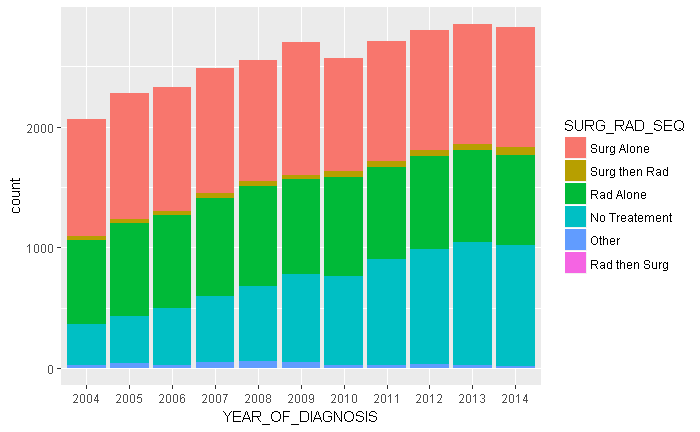

```r
data %>%
    ggplot(aes(x = YEAR_OF_DIAGNOSIS)) +
    geom_histogram(stat = "count", aes(fill = SURG_RAD_SEQ))
```

```
Ignoring unknown parameters: binwidth, bins, pad
```

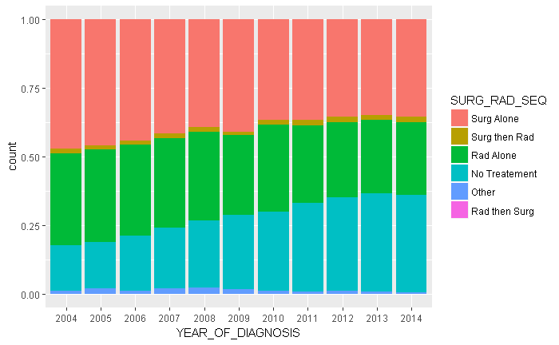

```r
data %>%
    ggplot(aes(x = YEAR_OF_DIAGNOSIS)) +
    geom_histogram(stat = "count", aes(fill = SURG_RAD_SEQ), position = "fill")
```

## Treatment by region

```r
p_table(data,
        vars = c("SURG_RAD_SEQ"),
        strata = c("FACILITY_LOCATION_F"))
```

|  | level | New England | Middle Atlantic | South Atlantic | East North Central | East South Central | West North Central | West South Central | Mountain | Pacific | p | test |
| --- | --- | --- | --- | --- | --- | --- | --- | --- | --- | --- | --- | --- |
| n |  | 1135 | 4365 | 4652 | 4100 | 1646 | 2346 | 1750 | 1374 | 2826 |  |  |
| SURG_RAD_SEQ (%) | Surg Alone | 323 (28.5) | 1071 (24.5) | 1701 (36.6) | 1760 (42.9) | 462 (28.1) | 1039 (44.3) | 786 (44.9) | 441 (32.1) | 1138 (40.3) | <0.001 |  |
|  | Surg then Rad | 17 ( 1.5) | 63 ( 1.4) | 55 ( 1.2) | 35 ( 0.9) | 27 ( 1.6) | 26 ( 1.1) | 25 ( 1.4) | 21 ( 1.5) | 64 ( 2.3) |  |  |
|  | Rad Alone | 407 (35.9) | 1854 (42.5) | 1506 (32.4) | 1151 (28.1) | 465 (28.3) | 710 (30.3) | 417 (23.8) | 481 (35.0) | 877 (31.0) |  |  |
|  | No Treatement | 370 (32.6) | 1292 (29.6) | 1330 (28.6) | 1116 (27.2) | 681 (41.4) | 554 (23.6) | 473 (27.0) | 377 (27.4) | 741 (26.2) |  |  |
|  | Other | 18 ( 1.6) | 82 ( 1.9) | 58 ( 1.2) | 38 ( 0.9) | 11 ( 0.7) | 16 ( 0.7) | 49 ( 2.8) | 54 ( 3.9) | 6 ( 0.2) |  |  |
|  | Rad then Surg | 0 ( 0.0) | 3 ( 0.1) | 2 ( 0.0) | 0 ( 0.0) | 0 ( 0.0) | 1 ( 0.0) | 0 ( 0.0) | 0 ( 0.0) | 0 ( 0.0) |  |  |

## Demographics by region

```r
p_table(data,
        vars = c("AGE_F", "RACE_F", "SEX_F", "INCOME_F", "EDUCATION_F", "INSURANCE_F", "U_R_F"),
        strata = c("FACILITY_LOCATION_F"))
```

|  | level | New England | Middle Atlantic | South Atlantic | East North Central | East South Central | West North Central | West South Central | Mountain | Pacific | p | test |
| --- | --- | --- | --- | --- | --- | --- | --- | --- | --- | --- | --- | --- |
| n |  | 1135 | 4365 | 4652 | 4100 | 1646 | 2346 | 1750 | 1374 | 2826 |  |  |
| AGE_F (%) | (0,54] | 413 (36.4) | 1604 (36.7) | 1664 (35.8) | 1546 (37.7) | 562 (34.1) | 908 (38.7) | 681 (38.9) | 469 (34.1) | 1029 (36.4) | NaN |  |
|  | (54,64] | 366 (32.2) | 1357 (31.1) | 1443 (31.0) | 1271 (31.0) | 539 (32.7) | 770 (32.8) | 527 (30.1) | 433 (31.5) | 941 (33.3) |  |  |
|  | (64,74] | 221 (19.5) | 923 (21.1) | 1031 (22.2) | 809 (19.7) | 364 (22.1) | 465 (19.8) | 369 (21.1) | 299 (21.8) | 587 (20.8) |  |  |
|  | (74,100] | 135 (11.9) | 481 (11.0) | 514 (11.0) | 474 (11.6) | 181 (11.0) | 203 ( 8.7) | 173 ( 9.9) | 173 (12.6) | 269 ( 9.5) |  |  |
|  | NA | 0 ( 0.0) | 0 ( 0.0) | 0 ( 0.0) | 0 ( 0.0) | 0 ( 0.0) | 0 ( 0.0) | 0 ( 0.0) | 0 ( 0.0) | 0 ( 0.0) |  |  |
| RACE_F (%) | White | 1037 (91.4) | 3710 (85.0) | 3996 (85.9) | 3682 (89.8) | 1527 (92.8) | 2198 (93.7) | 1524 (87.1) | 1298 (94.5) | 2350 (83.2) | <0.001 |  |
|  | Black | 20 ( 1.8) | 182 ( 4.2) | 392 ( 8.4) | 165 ( 4.0) | 88 ( 5.3) | 38 ( 1.6) | 88 ( 5.0) | 15 ( 1.1) | 51 ( 1.8) |  |  |
|  | Other/Unk | 47 ( 4.1) | 328 ( 7.5) | 166 ( 3.6) | 182 ( 4.4) | 20 ( 1.2) | 83 ( 3.5) | 108 ( 6.2) | 37 ( 2.7) | 167 ( 5.9) |  |  |
|  | Asian | 31 ( 2.7) | 145 ( 3.3) | 98 ( 2.1) | 71 ( 1.7) | 11 ( 0.7) | 27 ( 1.2) | 30 ( 1.7) | 24 ( 1.7) | 258 ( 9.1) |  |  |
| SEX_F (%) | Male | 553 (48.7) | 2059 (47.2) | 2144 (46.1) | 1889 (46.1) | 775 (47.1) | 1121 (47.8) | 803 (45.9) | 665 (48.4) | 1394 (49.3) | 0.116 |  |
|  | Female | 582 (51.3) | 2306 (52.8) | 2508 (53.9) | 2211 (53.9) | 871 (52.9) | 1225 (52.2) | 947 (54.1) | 709 (51.6) | 1432 (50.7) |  |  |
| INCOME_F (%) | Less than $38,000 | 60 ( 5.3) | 373 ( 8.5) | 741 (15.9) | 390 ( 9.5) | 527 (32.0) | 203 ( 8.7) | 289 (16.5) | 97 ( 7.1) | 189 ( 6.7) | <0.001 |  |
|  | $38,000 - $47,999 | 89 ( 7.8) | 685 (15.7) | 1051 (22.6) | 982 (24.0) | 419 (25.5) | 673 (28.7) | 418 (23.9) | 248 (18.0) | 486 (17.2) |  |  |
|  | $48,000 - $62,999 | 290 (25.6) | 1121 (25.7) | 1222 (26.3) | 1211 (29.5) | 397 (24.1) | 769 (32.8) | 468 (26.7) | 458 (33.3) | 887 (31.4) |  |  |
|  | $63,000 + | 683 (60.2) | 2151 (49.3) | 1593 (34.2) | 1494 (36.4) | 297 (18.0) | 695 (29.6) | 566 (32.3) | 552 (40.2) | 1243 (44.0) |  |  |
|  | NA | 13 ( 1.1) | 35 ( 0.8) | 45 ( 1.0) | 23 ( 0.6) | 6 ( 0.4) | 6 ( 0.3) | 9 ( 0.5) | 19 ( 1.4) | 21 ( 0.7) |  |  |
| EDUCATION_F (%) | 21% or more | 78 ( 6.9) | 403 ( 9.2) | 672 (14.4) | 244 ( 6.0) | 407 (24.7) | 82 ( 3.5) | 435 (24.9) | 80 ( 5.8) | 351 (12.4) | <0.001 |  |
|  | 13 - 20.9% | 154 (13.6) | 747 (17.1) | 1309 (28.1) | 914 (22.3) | 602 (36.6) | 395 (16.8) | 465 (26.6) | 186 (13.5) | 507 (17.9) |  |  |
|  | 7 - 12.9% | 403 (35.5) | 1755 (40.2) | 1416 (30.4) | 1528 (37.3) | 375 (22.8) | 923 (39.3) | 466 (26.6) | 425 (30.9) | 1055 (37.3) |  |  |
|  | Less than 7% | 487 (42.9) | 1428 (32.7) | 1213 (26.1) | 1392 (34.0) | 256 (15.6) | 940 (40.1) | 375 (21.4) | 664 (48.3) | 894 (31.6) |  |  |
|  | NA | 13 ( 1.1) | 32 ( 0.7) | 42 ( 0.9) | 22 ( 0.5) | 6 ( 0.4) | 6 ( 0.3) | 9 ( 0.5) | 19 ( 1.4) | 19 ( 0.7) |  |  |
| INSURANCE_F (%) | Private | 728 (64.1) | 2760 (63.2) | 2704 (58.1) | 2473 (60.3) | 889 (54.0) | 1446 (61.6) | 1066 (60.9) | 779 (56.7) | 1761 (62.3) | <0.001 |  |
|  | None | 9 ( 0.8) | 56 ( 1.3) | 114 ( 2.5) | 58 ( 1.4) | 29 ( 1.8) | 44 ( 1.9) | 68 ( 3.9) | 23 ( 1.7) | 49 ( 1.7) |  |  |
|  | Medicaid | 41 ( 3.6) | 176 ( 4.0) | 99 ( 2.1) | 133 ( 3.2) | 52 ( 3.2) | 51 ( 2.2) | 35 ( 2.0) | 44 ( 3.2) | 153 ( 5.4) |  |  |
|  | Medicare | 327 (28.8) | 1235 (28.3) | 1506 (32.4) | 1258 (30.7) | 589 (35.8) | 660 (28.1) | 514 (29.4) | 441 (32.1) | 768 (27.2) |  |  |
|  | Other Government | 6 ( 0.5) | 36 ( 0.8) | 133 ( 2.9) | 44 ( 1.1) | 62 ( 3.8) | 65 ( 2.8) | 42 ( 2.4) | 56 ( 4.1) | 42 ( 1.5) |  |  |
|  | Unknown | 24 ( 2.1) | 102 ( 2.3) | 96 ( 2.1) | 134 ( 3.3) | 25 ( 1.5) | 80 ( 3.4) | 25 ( 1.4) | 31 ( 2.3) | 53 ( 1.9) |  |  |
| U_R_F (%) | Metro | 882 (77.7) | 3917 (89.7) | 3954 (85.0) | 3324 (81.1) | 1148 (69.7) | 1551 (66.1) | 1442 (82.4) | 1087 (79.1) | 2470 (87.4) | <0.001 |  |
|  | Urban | 109 ( 9.6) | 373 ( 8.5) | 469 (10.1) | 650 (15.9) | 379 (23.0) | 627 (26.7) | 241 (13.8) | 203 (14.8) | 248 ( 8.8) |  |  |
|  | Rural | 6 ( 0.5) | 7 ( 0.2) | 58 ( 1.2) | 41 ( 1.0) | 77 ( 4.7) | 131 ( 5.6) | 24 ( 1.4) | 26 ( 1.9) | 16 ( 0.6) |  |  |
|  | NA | 138 (12.2) | 68 ( 1.6) | 171 ( 3.7) | 85 ( 2.1) | 42 ( 2.6) | 37 ( 1.6) | 43 ( 2.5) | 58 ( 4.2) | 92 ( 3.3) |  |  |

## Treatment by tumor size

```r
p_table(data,
        vars = c("SURG_RAD_SEQ"),
        strata = c("T_SIZE"))
```

|  | level | No Tumor | Microscopic focus | < 1 cm | 1-2 cm | 2-3 cm | 3-4 cm | 4-5 cm | 5-6 cm | >6 cm | NA_unk | p | test |
| --- | --- | --- | --- | --- | --- | --- | --- | --- | --- | --- | --- | --- | --- |
| n |  | 4 | 14 | 5651 | 8775 | 4784 | 2117 | 799 | 283 | 563 | 5200 |  |  |
| SURG_RAD_SEQ (%) | Surg Alone | 1 (25.0) | 5 (35.7) | 957 (16.9) | 2549 (29.0) | 2335 (48.8) | 1524 (72.0) | 602 (75.3) | 179 (63.3) | 195 (34.6) | 2774 (53.3) | <0.001 |  |
|  | Surg then Rad | 0 ( 0.0) | 0 ( 0.0) | 5 ( 0.1) | 13 ( 0.1) | 96 ( 2.0) | 148 ( 7.0) | 81 (10.1) | 35 (12.4) | 8 ( 1.4) | 95 ( 1.8) |  |  |
|  | Rad Alone | 1 (25.0) | 1 ( 7.1) | 1386 (24.5) | 3719 (42.4) | 1668 (34.9) | 226 (10.7) | 33 ( 4.1) | 26 ( 9.2) | 205 (36.4) | 1247 (24.0) |  |  |
|  | No Treatement | 2 (50.0) | 8 (57.1) | 3213 (56.9) | 2400 (27.4) | 624 (13.0) | 182 ( 8.6) | 63 ( 7.9) | 35 (12.4) | 152 (27.0) | 1007 (19.4) |  |  |
|  | Other | 0 ( 0.0) | 0 ( 0.0) | 90 ( 1.6) | 93 ( 1.1) | 60 ( 1.3) | 34 ( 1.6) | 18 ( 2.3) | 8 ( 2.8) | 3 ( 0.5) | 77 ( 1.5) |  |  |
|  | Rad then Surg | 0 ( 0.0) | 0 ( 0.0) | 0 ( 0.0) | 1 ( 0.0) | 1 ( 0.0) | 3 ( 0.1) | 2 ( 0.3) | 0 ( 0.0) | 0 ( 0.0) | 0 ( 0.0) |  |  |

```
Ignoring unknown parameters: binwidth, bins, pad
```

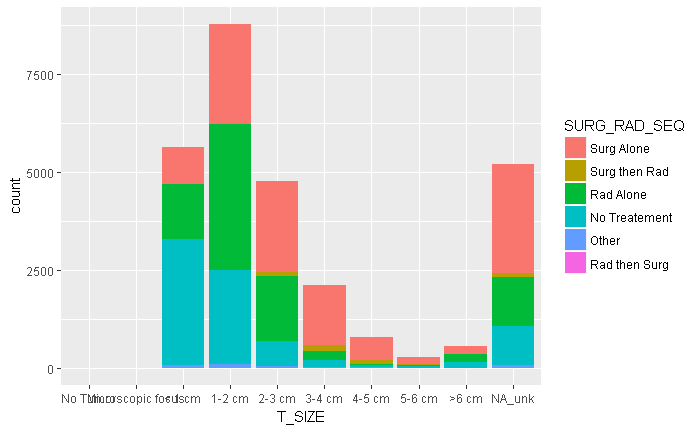

```r
data %>%
    ggplot(aes(x = T_SIZE)) +
    geom_histogram(stat = "count", aes(fill = SURG_RAD_SEQ))
```

```
Ignoring unknown parameters: binwidth, bins, pad
```

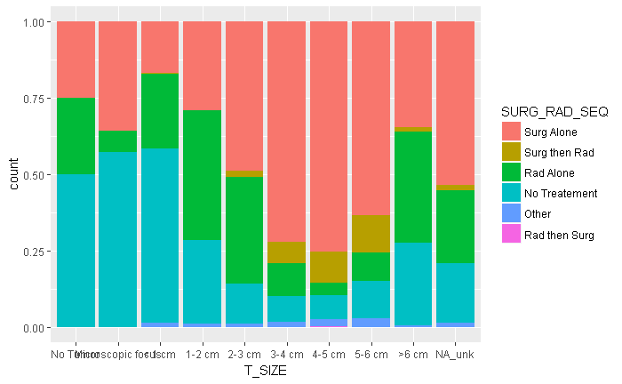

```r
data %>%
    ggplot(aes(x = T_SIZE)) +
    geom_histogram(stat = "count", aes(fill = SURG_RAD_SEQ), position = "fill")
```

# Tumor size by year

Limited to below 10 cm to exclude recording errors

```r
data <- data %>%
        mutate(TUMOR_SIZE_LIM = ifelse(TUMOR_SIZE < 100,
                                       TUMOR_SIZE,
                                        NA)) %>%
        mutate(T_SIZE_LIM = fct_recode(T_SIZE,
                                       NULL = "NA_unk"))
p_table(data,
        vars = c("TUMOR_SIZE", "TUMOR_SIZE_LIM", "T_SIZE_LIM"),
        strata = c("YEAR_OF_DIAGNOSIS"))
```

|  | level | 2004 | 2005 | 2006 | 2007 | 2008 | 2009 | 2010 | 2011 | 2012 | 2013 | 2014 | p | test |
| --- | --- | --- | --- | --- | --- | --- | --- | --- | --- | --- | --- | --- | --- | --- |
| n |  | 2068 | 2281 | 2333 | 2487 | 2555 | 2699 | 2571 | 2713 | 2802 | 2851 | 2830 |  |  |
| TUMOR_SIZE (mean (sd)) |  | 322.11 (452.61) | 312.11 (447.64) | 277.18 (430.72) | 244.88 (412.52) | 230.12 (402.30) | 205.25 (382.47) | 170.80 (354.99) | 158.97 (343.49) | 145.83 (329.07) | 145.61 (329.53) | 139.44 (322.39) | <0.001 |  |
| TUMOR_SIZE_LIM (mean (sd)) |  | 17.62 (12.12) | 18.61 (12.20) | 18.59 (13.00) | 18.16 (11.83) | 17.67 (11.94) | 18.01 (12.84) | 18.00 (13.00) | 17.99 (12.41) | 17.92 (12.39) | 17.41 (12.21) | 17.82 (12.49) | 0.085 |  |
| T_SIZE_LIM (%) | No Tumor | 0 ( 0.0) | 0 ( 0.0) | 0 ( 0.0) | 0 ( 0.0) | 0 ( 0.0) | 1 ( 0.0) | 0 ( 0.0) | 2 ( 0.1) | 0 ( 0.0) | 0 ( 0.0) | 1 ( 0.0) | <0.001 |  |
|  | Microscopic focus | 1 ( 0.0) | 1 ( 0.0) | 0 ( 0.0) | 3 ( 0.1) | 0 ( 0.0) | 0 ( 0.0) | 2 ( 0.1) | 1 ( 0.0) | 3 ( 0.1) | 3 ( 0.1) | 0 ( 0.0) |  |  |
|  | < 1 cm | 328 (15.9) | 334 (14.6) | 391 (16.8) | 423 (17.0) | 517 (20.2) | 556 (20.6) | 538 (20.9) | 598 (22.0) | 633 (22.6) | 677 (23.7) | 656 (23.2) |  |  |
|  | 1-2 cm | 603 (29.2) | 614 (26.9) | 666 (28.5) | 780 (31.4) | 731 (28.6) | 836 (31.0) | 867 (33.7) | 874 (32.2) | 906 (32.3) | 945 (33.1) | 953 (33.7) |  |  |
|  | 2-3 cm | 284 (13.7) | 381 (16.7) | 385 (16.5) | 423 (17.0) | 445 (17.4) | 443 (16.4) | 426 (16.6) | 500 (18.4) | 516 (18.4) | 482 (16.9) | 499 (17.6) |  |  |
|  | 3-4 cm | 138 ( 6.7) | 161 ( 7.1) | 167 ( 7.2) | 180 ( 7.2) | 192 ( 7.5) | 190 ( 7.0) | 198 ( 7.7) | 212 ( 7.8) | 234 ( 8.4) | 241 ( 8.5) | 204 ( 7.2) |  |  |
|  | 4-5 cm | 41 ( 2.0) | 57 ( 2.5) | 58 ( 2.5) | 68 ( 2.7) | 64 ( 2.5) | 90 ( 3.3) | 87 ( 3.4) | 75 ( 2.8) | 84 ( 3.0) | 72 ( 2.5) | 103 ( 3.6) |  |  |
|  | 5-6 cm | 18 ( 0.9) | 24 ( 1.1) | 26 ( 1.1) | 21 ( 0.8) | 22 ( 0.9) | 24 ( 0.9) | 27 ( 1.1) | 41 ( 1.5) | 22 ( 0.8) | 31 ( 1.1) | 27 ( 1.0) |  |  |
|  | >6 cm | 40 ( 1.9) | 44 ( 1.9) | 50 ( 2.1) | 40 ( 1.6) | 62 ( 2.4) | 92 ( 3.4) | 47 ( 1.8) | 41 ( 1.5) | 53 ( 1.9) | 49 ( 1.7) | 45 ( 1.6) |  |  |
|  | NA | 615 (29.7) | 665 (29.2) | 590 (25.3) | 549 (22.1) | 522 (20.4) | 467 (17.3) | 379 (14.7) | 369 (13.6) | 351 (12.5) | 351 (12.3) | 342 (12.1) |  |  |

```r
data %>%
        mutate(YEAR = as.numeric(as.character(YEAR_OF_DIAGNOSIS))) %>%
        lm(TUMOR_SIZE_LIM ~ YEAR,
              data = .) %>%
        summary()
```

```
Call:
lm(formula = TUMOR_SIZE_LIM ~ YEAR, data = .)

Residuals:
    Min      1Q  Median      3Q     Max
-17.986  -8.273  -2.871   5.899  81.244

Coefficients:
             Estimate Std. Error t value Pr(>|t|)
(Intercept) 133.48387   54.03556   2.470   0.0135 *
YEAR         -0.05749    0.02689  -2.138   0.0325 *
---
Signif. codes:  0 *** 0.001 ** 0.01 * 0.05 . 0.1   1

Residual standard error: 12.42 on 22545 degrees of freedom
  (5643 observations deleted due to missingness)
Multiple R-squared:  0.0002027, Adjusted R-squared:  0.0001584
F-statistic: 4.571 on 1 and 22545 DF,  p-value: 0.03253
```

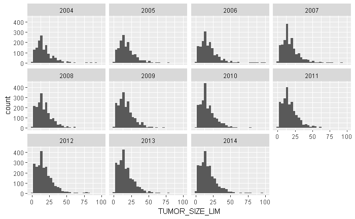

```r
data %>%
    ggplot(aes(x = TUMOR_SIZE_LIM)) +
    geom_histogram() +
    facet_wrap(~ YEAR_OF_DIAGNOSIS)
```

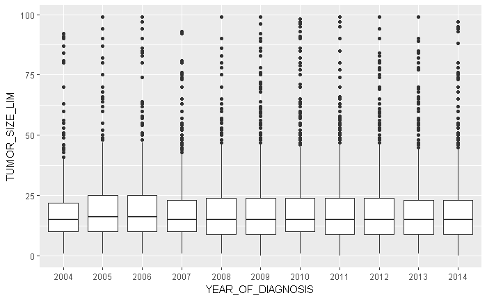

```r
data %>%
    ggplot(aes(x = YEAR_OF_DIAGNOSIS, y = TUMOR_SIZE_LIM)) +
    geom_boxplot()
```

```
Ignoring unknown parameters: binwidth, bins, pad
```

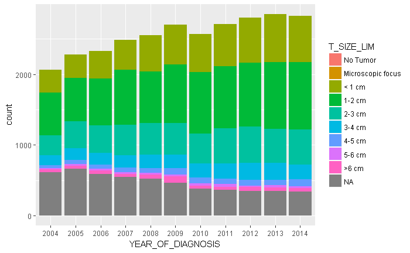

```r
data %>%
        ggplot(aes(x = YEAR_OF_DIAGNOSIS)) +
        geom_histogram(stat = "count",
                       aes(fill = T_SIZE_LIM))
```

```
Ignoring unknown parameters: binwidth, bins, pad
```

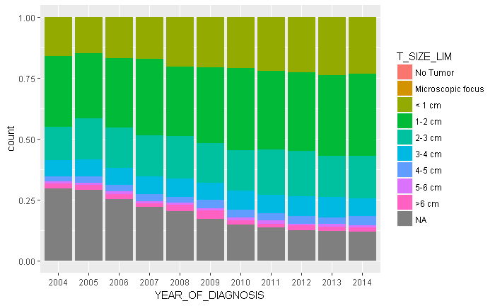

```r
data %>%
        ggplot(aes(x = YEAR_OF_DIAGNOSIS)) +
        geom_histogram(stat = "count",
                       aes(fill = T_SIZE_LIM),
                       position = "fill")
```

# Treatment models

```r
data <- data %>%
        mutate(FACILITY_LOCATION_F = fct_relevel(FACILITY_LOCATION_F,
                                             "Middle Atlantic")) %>%
        mutate(SURG_TX = case_when(SURGERY_YN == "Yes" ~ TRUE,
                                   SURGERY_YN == "No" ~ FALSE,
                                   TRUE ~ NA)) %>%
        mutate(YEAR_OF_DIAGNOSIS = fct_relevel(YEAR_OF_DIAGNOSIS,
                                               "2014"))
fit_surg <- glm(SURG_TX ~ AGE + SEX + CDCC_TOTAL + T_SIZE + FACILITY_TYPE_F + FACILITY_LOCATION_F +
                        YEAR_OF_DIAGNOSIS,
                family = "binomial",
                data = data)
summary(fit_surg)
```

```
Call:
glm(formula = SURG_TX ~ AGE + SEX + CDCC_TOTAL + T_SIZE + FACILITY_TYPE_F +
    FACILITY_LOCATION_F + YEAR_OF_DIAGNOSIS, family = "binomial",
    data = data)

Deviance Residuals:
    Min       1Q   Median       3Q      Max
-2.7538  -0.8017  -0.4367   0.8795   2.7182

Coefficients:
                                               Estimate Std. Error z value Pr(>|z|)
(Intercept)                                   1.2332624  1.2127810   1.017 0.309207
AGE                                          -0.0709696  0.0015969 -44.442  < 2e-16 ***
SEX2                                          0.1187358  0.0314558   3.775 0.000160 ***
CDCC_TOTAL1                                   0.8142192  0.0518702  15.697  < 2e-16 ***
CDCC_TOTAL2                                   0.5751462  0.1201214   4.788 1.68e-06 ***
CDCC_TOTAL3                                  -0.0860583  0.2142707  -0.402 0.687954
T_SIZEMicroscopic focus                      -0.2719462  1.3991489  -0.194 0.845890
T_SIZE< 1 cm                                 -1.1692474  1.2034516  -0.972 0.331260
T_SIZE1-2 cm                                 -0.4667826  1.2030809  -0.388 0.698024
T_SIZE2-3 cm                                  0.5439342  1.2032444   0.452 0.651228
T_SIZE3-4 cm                                  1.9879321  1.2044062   1.651 0.098831 .
T_SIZE4-5 cm                                  2.3800457  1.2095734   1.968 0.049106 *
T_SIZE5-6 cm                                  1.4769982  1.2150887   1.216 0.224157
T_SIZE>6 cm                                  -0.2774899  1.2075110  -0.230 0.818245
T_SIZENA_unk                                  0.7650461  1.2032867   0.636 0.524909
FACILITY_TYPE_FComprehensive Comm Ca Program  1.1364566  0.1522797   7.463 8.46e-14 ***
FACILITY_TYPE_FAcademic/Research Program      1.5410166  0.1503926  10.247  < 2e-16 ***
FACILITY_TYPE_FIntegrated Network Ca Program  1.2260301  0.1553333   7.893 2.95e-15 ***
FACILITY_LOCATION_FNew England                0.2198547  0.0853294   2.577 0.009979 **
FACILITY_LOCATION_FSouth Atlantic             0.7633914  0.0542184  14.080  < 2e-16 ***
FACILITY_LOCATION_FEast North Central         0.9836738  0.0547237  17.975  < 2e-16 ***
FACILITY_LOCATION_FEast South Central         0.3004056  0.0746927   4.022 5.77e-05 ***
FACILITY_LOCATION_FWest North Central         1.1182139  0.0633290  17.657  < 2e-16 ***
FACILITY_LOCATION_FWest South Central         1.1255506  0.0697359  16.140  < 2e-16 ***
FACILITY_LOCATION_FMountain                   0.8312149  0.0783491  10.609  < 2e-16 ***
FACILITY_LOCATION_FPacific                    0.9720623  0.0614110  15.829  < 2e-16 ***
YEAR_OF_DIAGNOSIS2004                         0.4429541  0.0762697   5.808 6.33e-09 ***
YEAR_OF_DIAGNOSIS2005                         0.2690920  0.0740816   3.632 0.000281 ***
YEAR_OF_DIAGNOSIS2006                         0.2409033  0.0734078   3.282 0.001032 **
YEAR_OF_DIAGNOSIS2007                         0.1835904  0.0726315   2.528 0.011481 *
YEAR_OF_DIAGNOSIS2008                         0.0910493  0.0727809   1.251 0.210932
YEAR_OF_DIAGNOSIS2009                         0.1737611  0.0716964   2.424 0.015369 *
YEAR_OF_DIAGNOSIS2010                        -0.0004844  0.0728407  -0.007 0.994694
YEAR_OF_DIAGNOSIS2011                         0.0194780  0.0721033   0.270 0.787052
YEAR_OF_DIAGNOSIS2012                        -0.0218309  0.0714533  -0.306 0.759965
YEAR_OF_DIAGNOSIS2013                        -0.0704284  0.0716865  -0.982 0.325878
---
Signif. codes:  0 *** 0.001 ** 0.01 * 0.05 . 0.1   1

(Dispersion parameter for binomial family taken to be 1)

    Null deviance: 31836  on 23903  degrees of freedom
Residual deviance: 24520  on 23868  degrees of freedom
  (4286 observations deleted due to missingness)
AIC: 24592

Number of Fisher Scoring iterations: 5
```

```r
exp(cbind("Odds ratio" = coef(fit_surg), confint.default(fit_surg, level = 0.95)))
```

```
                                             Odds ratio      2.5 %      97.5 %
(Intercept)                                   3.4324093 0.31862367  36.9760145
AGE                                           0.9314902 0.92857932   0.9344102
SEX2                                          1.1260724 1.05874436   1.1976820
CDCC_TOTAL1                                   2.2574123 2.03919548   2.4989808
CDCC_TOTAL2                                   1.7773904 1.40454378   2.2492120
CDCC_TOTAL3                                   0.9175407 0.60288955   1.3964100
T_SIZEMicroscopic focus                       0.7618952 0.04908373  11.8264115
T_SIZE< 1 cm                                  0.3106006 0.02936449   3.2853541
T_SIZE1-2 cm                                  0.6270164 0.05932183   6.6274013
T_SIZE2-3 cm                                  1.7227713 0.16293866  18.2150819
T_SIZE3-4 cm                                  7.3004213 0.68889887  77.3642597
T_SIZE4-5 cm                                 10.8053968 1.00936911 115.6728498
T_SIZE5-6 cm                                  4.3797787 0.40473126  47.3955511
T_SIZE>6 cm                                   0.7576832 0.07106446   8.0783542
T_SIZENA_unk                                  2.1490934 0.20324309  22.7245241
FACILITY_TYPE_FComprehensive Comm Ca Program  3.1157085 2.31172448   4.1993064
FACILITY_TYPE_FAcademic/Research Program      4.6693349 3.47728772   6.2700270
FACILITY_TYPE_FIntegrated Network Ca Program  3.4076745 2.51326437   4.6203837
FACILITY_LOCATION_FNew England                1.2458957 1.05402086   1.4726996
FACILITY_LOCATION_FSouth Atlantic             2.1455402 1.92923834   2.3860934
FACILITY_LOCATION_FEast North Central         2.6742629 2.40227764   2.9770423
FACILITY_LOCATION_FEast South Central         1.3504064 1.16650317   1.5633027
FACILITY_LOCATION_FWest North Central         3.0593849 2.70226766   3.4636968
FACILITY_LOCATION_FWest South Central         3.0819134 2.68819721   3.5332936
FACILITY_LOCATION_FMountain                   2.2961065 1.96925117   2.6772131
FACILITY_LOCATION_FPacific                    2.6433904 2.34362510   2.9814976
YEAR_OF_DIAGNOSIS2004                         1.5573008 1.34107066   1.8083953
YEAR_OF_DIAGNOSIS2005                         1.3087756 1.13189664   1.5132950
YEAR_OF_DIAGNOSIS2006                         1.2723980 1.10188980   1.4692909
YEAR_OF_DIAGNOSIS2007                         1.2015236 1.04209736   1.3853398
YEAR_OF_DIAGNOSIS2008                         1.0953230 0.94970999   1.2632619
YEAR_OF_DIAGNOSIS2009                         1.1897712 1.03379733   1.3692777
YEAR_OF_DIAGNOSIS2010                         0.9995157 0.86653783   1.1529002
YEAR_OF_DIAGNOSIS2011                         1.0196690 0.88528846   1.1744475
YEAR_OF_DIAGNOSIS2012                         0.9784057 0.85054601   1.1254860
YEAR_OF_DIAGNOSIS2013                         0.9319945 0.80982961   1.0725882
```

# Kaplan Meier Analysis

```r
uni_var <- function(test_var, data_imp) {

        cat("_________________________________________________")
        cat("\n")
        cat("   \n##", test_var)
        cat("\n")
        cat("_________________________________________________")
        cat("\n")

        f <- as.formula(paste("Surv(DX_LASTCONTACT_DEATH_MONTHS, PUF_VITAL_STATUS == 0)",
                              as.name(test_var),
                              sep = " ~ " ))

        data_imp_2 <- deparse(substitute(data_imp))
        km_fit <- do.call("survfit", list(formula = f, data = as.name(data_imp_2)))
        print(km_fit)
        cat("\n")
        print(summary(km_fit, times = c(12, 24, 36, 48, 60, 120)))
        cat("\n")
        cat("\n")
        cat("\n")
        cat("   \n## Univariable Cox Proportional Hazard Model for: ", test_var)
        cat("\n")
        cat("\n")
        n_levels <- nlevels(data_imp[[test_var]])
        if(n_levels == 1){
                print("Only one level, no Cox model performed")
                cat("\n")
        } else {
                cox_fit <- do.call("coxph", list(formula = f, data = as.name(data_imp_2)))
                print(summary(cox_fit))
                cat("\n")

                do.call("ggforest",
                         list(model = cox_fit, data = as.name(data_imp_2)))
        }
        cat("\n")
        cat("\n")
        cat("\n")
        cat("   \n## Unadjusted Kaplan Meier Overall Survival Curve for: ", test_var)
        p <- do.call("ggsurvplot",
                     list(fit = km_fit, data = as.name(data_imp_2),
                          palette = "jco", censor = FALSE, legend = "right",
                          linetype = "strata", xlab = "Time (Months)"))
        print(p)
}
```

## All

```
_________________________________________________

## All
_________________________________________________
Call: survfit(formula = Surv(DX_LASTCONTACT_DEATH_MONTHS, PUF_VITAL_STATUS ==
    0) ~ All, data = data)

      n  events  median 0.95LCL 0.95UCL
  28190    2199      NA      NA      NA

Call: survfit(formula = Surv(DX_LASTCONTACT_DEATH_MONTHS, PUF_VITAL_STATUS ==
    0) ~ All, data = data)

 time n.risk n.event survival std.err lower 95% CI upper 95% CI
   12  25978     499    0.982 0.00081        0.980        0.983
   24  23239     308    0.970 0.00105        0.968        0.972
   36  19915     259    0.958 0.00126        0.956        0.961
   48  16726     238    0.946 0.00148        0.943        0.949
   60  13693     199    0.933 0.00170        0.930        0.937
  120   2681     624    0.856 0.00363        0.849        0.863




## Univariable Cox Proportional Hazard Model for:  All

[1] "Only one level, no Cox model performed"





## Unadjusted Kaplan Meier Overall Survival Curve for:  All
```

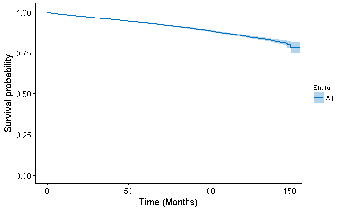

```r
uni_var(test_var = "All", data_imp = data)
```

## Facility Type

```
_________________________________________________

## FACILITY_TYPE_F
_________________________________________________
Call: survfit(formula = Surv(DX_LASTCONTACT_DEATH_MONTHS, PUF_VITAL_STATUS ==
    0) ~ FACILITY_TYPE_F, data = data)

   3996 observations deleted due to missingness
                                                  n events median 0.95LCL 0.95UCL
FACILITY_TYPE_F=Community Cancer Program        481     74     NA      NA      NA
FACILITY_TYPE_F=Comprehensive Comm Ca Program  6375    742     NA      NA      NA
FACILITY_TYPE_F=Academic/Research Program     14083    980     NA      NA      NA
FACILITY_TYPE_F=Integrated Network Ca Program  3255    326     NA      NA      NA

Call: survfit(formula = Surv(DX_LASTCONTACT_DEATH_MONTHS, PUF_VITAL_STATUS ==
    0) ~ FACILITY_TYPE_F, data = data)

3996 observations deleted due to missingness
                FACILITY_TYPE_F=Community Cancer Program
 time n.risk n.event survival std.err lower 95% CI upper 95% CI
   12    415      15    0.967 0.00841        0.951        0.984
   24    358      13    0.935 0.01186        0.912        0.959
   36    287      13    0.899 0.01514        0.869        0.929
   48    233       6    0.879 0.01689        0.846        0.912
   60    183      12    0.830 0.02099        0.790        0.872
  120     29      13    0.740 0.03176        0.680        0.805

                FACILITY_TYPE_F=Comprehensive Comm Ca Program
 time n.risk n.event survival std.err lower 95% CI upper 95% CI
   12   5774     192    0.969 0.00222        0.964        0.973
   24   5171     112    0.949 0.00284        0.944        0.955
   36   4441      83    0.933 0.00331        0.926        0.939
   48   3780      76    0.916 0.00378        0.908        0.923
   60   3092      57    0.901 0.00421        0.893        0.909
  120    560     199    0.794 0.00875        0.777        0.812

                FACILITY_TYPE_F=Academic/Research Program
 time n.risk n.event survival std.err lower 95% CI upper 95% CI
   12  13137     195    0.986 0.00101        0.984        0.988
   24  11753     128    0.976 0.00133        0.973        0.978
```

[output cut: 29 more lines]

```
FACILITY_TYPE_FAcademic/Research Program     -0.9571    0.3840   0.1206 -7.937 2.06e-15 ***
FACILITY_TYPE_FIntegrated Network Ca Program -0.6192    0.5384   0.1288 -4.808 1.53e-06 ***
---
Signif. codes:  0 *** 0.001 ** 0.01 * 0.05 . 0.1   1

                                             exp(coef) exp(-coef) lower .95 upper .95
FACILITY_TYPE_FComprehensive Comm Ca Program    0.6586      1.518    0.5186    0.8364
FACILITY_TYPE_FAcademic/Research Program        0.3840      2.604    0.3032    0.4864
FACILITY_TYPE_FIntegrated Network Ca Program    0.5384      1.857    0.4183    0.6930

Concordance= 0.576  (se = 0.006 )
Rsquare= 0.006   (max possible= 0.81 )
Likelihood ratio test= 155  on 3 df,   p=<2e-16
Wald test            = 161.7  on 3 df,   p=<2e-16
Score (logrank) test = 167  on 3 df,   p=<2e-16
```

```
Removed 1 rows containing missing values (geom_errorbar).
```

```
## Unadjusted Kaplan Meier Overall Survival Curve for:  FACILITY_TYPE_F
```

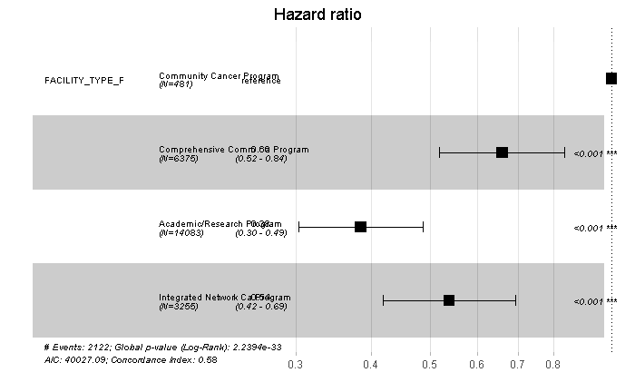

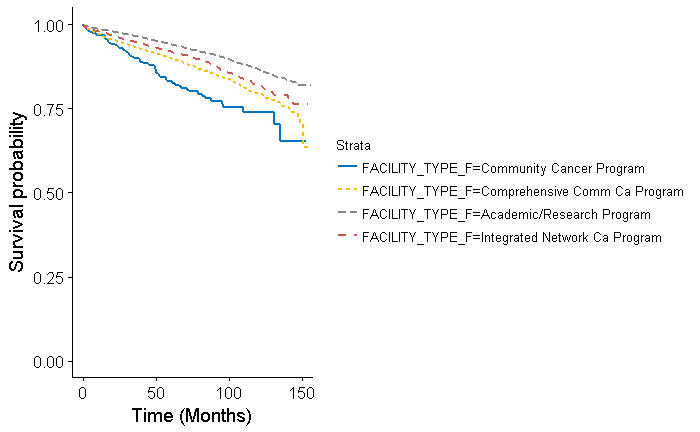

```r
uni_var(test_var = "FACILITY_TYPE_F", data_imp = data)
```

## Facility Location

```
_________________________________________________

## FACILITY_LOCATION_F
_________________________________________________
Call: survfit(formula = Surv(DX_LASTCONTACT_DEATH_MONTHS, PUF_VITAL_STATUS ==
    0) ~ FACILITY_LOCATION_F, data = data)

   3996 observations deleted due to missingness
                                          n events median 0.95LCL 0.95UCL
FACILITY_LOCATION_F=Middle Atlantic    4365    381     NA      NA      NA
FACILITY_LOCATION_F=New England        1135     95     NA      NA      NA
FACILITY_LOCATION_F=South Atlantic     4652    399     NA      NA      NA
FACILITY_LOCATION_F=East North Central 4100    356     NA      NA      NA
FACILITY_LOCATION_F=East South Central 1646    176     NA      NA      NA
FACILITY_LOCATION_F=West North Central 2346    185     NA      NA      NA
FACILITY_LOCATION_F=West South Central 1750    160     NA      NA      NA
FACILITY_LOCATION_F=Mountain           1374    140     NA      NA      NA
FACILITY_LOCATION_F=Pacific            2826    230     NA      NA      NA

Call: survfit(formula = Surv(DX_LASTCONTACT_DEATH_MONTHS, PUF_VITAL_STATUS ==
    0) ~ FACILITY_LOCATION_F, data = data)

3996 observations deleted due to missingness
                FACILITY_LOCATION_F=Middle Atlantic
 time n.risk n.event survival std.err lower 95% CI upper 95% CI
   12   3961      94    0.978 0.00228        0.973        0.982
   24   3522      54    0.964 0.00292        0.958        0.970
   36   2997      45    0.951 0.00348        0.944        0.958
   48   2461      32    0.940 0.00396        0.932        0.947
   60   1958      34    0.925 0.00462        0.916        0.934
  120    339     106    0.831 0.01039        0.811        0.852

                FACILITY_LOCATION_F=New England
 time n.risk n.event survival std.err lower 95% CI upper 95% CI
   12   1051      13    0.988 0.00327        0.982        0.995
   24    959      12    0.976 0.00469        0.967        0.986
   36    811       9    0.966 0.00569        0.955        0.978
   48    693      13    0.950 0.00721        0.936        0.964
   60    558      12    0.932 0.00878        0.915        0.949
  120     93      34    0.825 0.02126        0.784        0.868
```

[output cut: 89 more lines]

```
                                      exp(coef) exp(-coef) lower .95 upper .95
FACILITY_LOCATION_FNew England           0.9233     1.0831    0.7374     1.156
FACILITY_LOCATION_FSouth Atlantic        0.8833     1.1322    0.7675     1.016
FACILITY_LOCATION_FEast North Central    0.9840     1.0162    0.8517     1.137
FACILITY_LOCATION_FEast South Central    1.1908     0.8398    0.9960     1.424
FACILITY_LOCATION_FWest North Central    0.7986     1.2522    0.6698     0.952
FACILITY_LOCATION_FWest South Central    0.9964     1.0036    0.8284     1.198
FACILITY_LOCATION_FMountain              1.0459     0.9561    0.8617     1.270
FACILITY_LOCATION_FPacific               0.8807     1.1354    0.7478     1.037

Concordance= 0.524  (se = 0.007 )
Rsquare= 0.001   (max possible= 0.81 )
Likelihood ratio test= 20.86  on 8 df,   p=0.008
Wald test            = 21.09  on 8 df,   p=0.007
Score (logrank) test = 21.19  on 8 df,   p=0.007
```

```
Removed 1 rows containing missing values (geom_errorbar).
```

```
## Unadjusted Kaplan Meier Overall Survival Curve for:  FACILITY_LOCATION_F
```

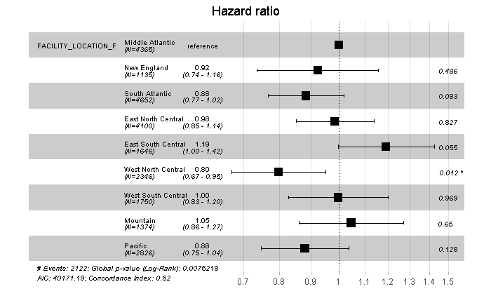

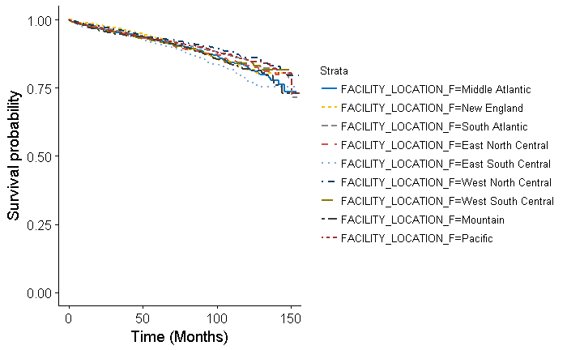

```r
uni_var(test_var = "FACILITY_LOCATION_F", data_imp = data)
```

## Facility Geography

```
_________________________________________________

## FACILITY_GEOGRAPHY
_________________________________________________
Call: survfit(formula = Surv(DX_LASTCONTACT_DEATH_MONTHS, PUF_VITAL_STATUS ==
    0) ~ FACILITY_GEOGRAPHY, data = data)

   3996 observations deleted due to missingness
                                n events median 0.95LCL 0.95UCL
FACILITY_GEOGRAPHY=Northeast 5500    476     NA      NA      NA
FACILITY_GEOGRAPHY=South     6402    559     NA      NA      NA
FACILITY_GEOGRAPHY=Midwest   8092    717     NA      NA      NA
FACILITY_GEOGRAPHY=West      4200    370     NA      NA      NA

Call: survfit(formula = Surv(DX_LASTCONTACT_DEATH_MONTHS, PUF_VITAL_STATUS ==
    0) ~ FACILITY_GEOGRAPHY, data = data)

3996 observations deleted due to missingness
                FACILITY_GEOGRAPHY=Northeast
 time n.risk n.event survival std.err lower 95% CI upper 95% CI
   12   5012     107    0.980 0.00193        0.976        0.984
   24   4481      66    0.966 0.00251        0.962        0.971
   36   3808      54    0.954 0.00300        0.948        0.960
   48   3154      45    0.942 0.00348        0.935        0.948
   60   2516      46    0.926 0.00409        0.918        0.934
  120    432     140    0.830 0.00937        0.812        0.848

                FACILITY_GEOGRAPHY=South
 time n.risk n.event survival std.err lower 95% CI upper 95% CI
   12   5976     122    0.980 0.00175        0.977        0.984
   24   5424      78    0.967 0.00228        0.963        0.972
   36   4678      70    0.954 0.00275        0.949        0.959
   48   3992      69    0.939 0.00325        0.932        0.945
   60   3332      50    0.926 0.00368        0.919        0.933
  120    618     152    0.848 0.00749        0.834        0.863

                FACILITY_GEOGRAPHY=Midwest
 time n.risk n.event survival std.err lower 95% CI upper 95% CI
   12   7464     161    0.980 0.00160        0.976        0.983
   24   6644      89    0.967 0.00204        0.963        0.971
```

[output cut: 27 more lines]

```
                              coef exp(coef) se(coef)      z Pr(>|z|)
FACILITY_GEOGRAPHYSouth   -0.07448   0.92823  0.06239 -1.194    0.233
FACILITY_GEOGRAPHYMidwest -0.01663   0.98351  0.05914 -0.281    0.779
FACILITY_GEOGRAPHYWest    -0.04865   0.95251  0.06933 -0.702    0.483

                          exp(coef) exp(-coef) lower .95 upper .95
FACILITY_GEOGRAPHYSouth      0.9282      1.077    0.8214     1.049
FACILITY_GEOGRAPHYMidwest    0.9835      1.017    0.8759     1.104
FACILITY_GEOGRAPHYWest       0.9525      1.050    0.8315     1.091

Concordance= 0.503  (se = 0.007 )
Rsquare= 0   (max possible= 0.81 )
Likelihood ratio test= 1.77  on 3 df,   p=0.6
Wald test            = 1.76  on 3 df,   p=0.6
Score (logrank) test = 1.76  on 3 df,   p=0.6
```

```
Removed 1 rows containing missing values (geom_errorbar).
```

```
## Unadjusted Kaplan Meier Overall Survival Curve for:  FACILITY_GEOGRAPHY
```

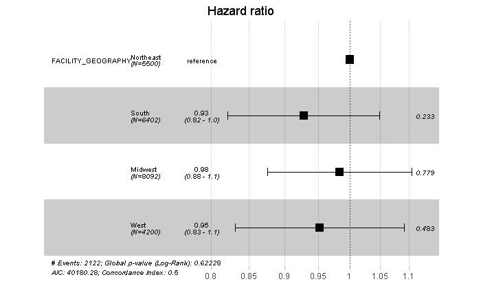

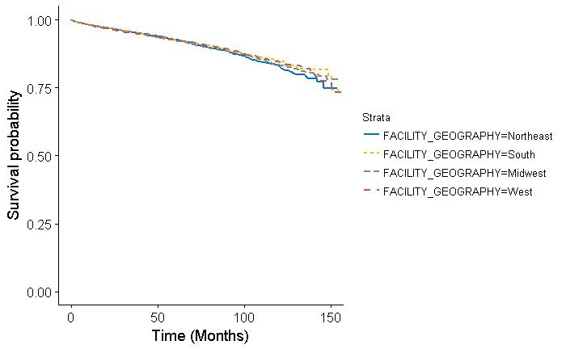

```r
uni_var(test_var = "FACILITY_GEOGRAPHY", data_imp = data)
```

## Age Group

```
_________________________________________________

## AGE_F
_________________________________________________
Call: survfit(formula = Surv(DX_LASTCONTACT_DEATH_MONTHS, PUF_VITAL_STATUS ==
    0) ~ AGE_F, data = data)

   5 observations deleted due to missingness
                   n events median 0.95LCL 0.95UCL
AGE_F=(0,54]   12867    323     NA      NA      NA
AGE_F=(54,64]   7647    398     NA      NA      NA
AGE_F=(64,74]   5068    620     NA      NA      NA
AGE_F=(74,100]  2603    858    105     101     113

Call: survfit(formula = Surv(DX_LASTCONTACT_DEATH_MONTHS, PUF_VITAL_STATUS ==
    0) ~ AGE_F, data = data)

5 observations deleted due to missingness
                AGE_F=(0,54]
 time n.risk n.event survival  std.err lower 95% CI upper 95% CI
   12  11915      81    0.994 0.000720        0.992        0.995
   24  10714      44    0.990 0.000924        0.988        0.991
   36   9245      43    0.985 0.001127        0.983        0.988
   48   7883      27    0.982 0.001274        0.980        0.985
   60   6578      25    0.979 0.001435        0.976        0.982
  120   1410     100    0.951 0.003286        0.945        0.958

                AGE_F=(54,64]
 time n.risk n.event survival std.err lower 95% CI upper 95% CI
   12   7114      99    0.987 0.00133        0.984        0.989
   24   6401      53    0.979 0.00169        0.976        0.982
   36   5557      41    0.972 0.00197        0.968        0.976
   48   4662      43    0.964 0.00231        0.960        0.969
   60   3811      29    0.958 0.00260        0.953        0.963
  120    731     113    0.904 0.00593        0.893        0.916

                AGE_F=(64,74]
 time n.risk n.event survival std.err lower 95% CI upper 95% CI
   12   4664     125    0.975 0.00224        0.970        0.979
   24   4123      87    0.956 0.00298        0.950        0.962
```

[output cut: 29 more lines]

```
AGE_F(64,74]   1.67440   5.33558  0.06866 24.388   <2e-16 ***
AGE_F(74,100]  2.79783  16.40899  0.06545 42.750   <2e-16 ***
---
Signif. codes:  0 *** 0.001 ** 0.01 * 0.05 . 0.1   1

              exp(coef) exp(-coef) lower .95 upper .95
AGE_F(54,64]      2.113    0.47326     1.825     2.447
AGE_F(64,74]      5.336    0.18742     4.664     6.104
AGE_F(74,100]    16.409    0.06094    14.434    18.655

Concordance= 0.751  (se = 0.006 )
Rsquare= 0.078   (max possible= 0.777 )
Likelihood ratio test= 2298  on 3 df,   p=<2e-16
Wald test            = 2312  on 3 df,   p=<2e-16
Score (logrank) test = 3491  on 3 df,   p=<2e-16
```

```
Removed 1 rows containing missing values (geom_errorbar).
```

```
## Unadjusted Kaplan Meier Overall Survival Curve for:  AGE_F
```

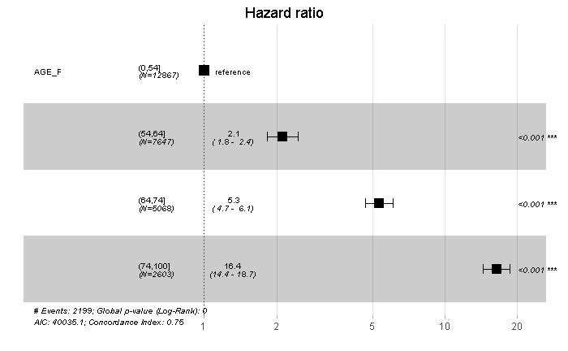

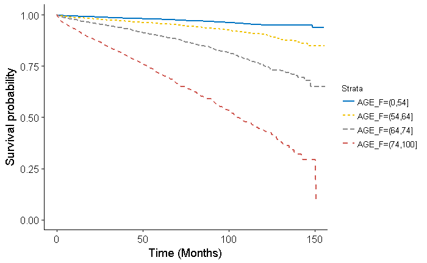

```r
uni_var(test_var = "AGE_F", data_imp = data)
```

## Age Group

```
_________________________________________________

## AGE_40
_________________________________________________
Call: survfit(formula = Surv(DX_LASTCONTACT_DEATH_MONTHS, PUF_VITAL_STATUS ==
    0) ~ AGE_40, data = data)

   5 observations deleted due to missingness
                    n events median 0.95LCL 0.95UCL
AGE_40=(0,40]    4345     87     NA      NA      NA
AGE_40=(40,100] 23840   2112     NA      NA      NA

Call: survfit(formula = Surv(DX_LASTCONTACT_DEATH_MONTHS, PUF_VITAL_STATUS ==
    0) ~ AGE_40, data = data)

5 observations deleted due to missingness
                AGE_40=(0,40]
 time n.risk n.event survival std.err lower 95% CI upper 95% CI
   12   3987      27    0.994 0.00123        0.991        0.996
   24   3531       9    0.991 0.00147        0.988        0.994
   36   3022      11    0.988 0.00178        0.984        0.991
   48   2546       6    0.986 0.00197        0.982        0.990
   60   2119       7    0.983 0.00224        0.978        0.987
  120    445      27    0.963 0.00469        0.953        0.972

                AGE_40=(40,100]
 time n.risk n.event survival  std.err lower 95% CI upper 95% CI
   12  21986     472    0.980 0.000929        0.978        0.981
   24  19704     299    0.966 0.001214        0.963        0.968
   36  16889     248    0.953 0.001451        0.950        0.956
   48  14176     232    0.939 0.001701        0.935        0.942
   60  11572     192    0.925 0.001950        0.921        0.929
  120   2235     597    0.837 0.004152        0.829        0.846





## Univariable Cox Proportional Hazard Model for:  AGE_40

Call:
coxph(formula = Surv(DX_LASTCONTACT_DEATH_MONTHS, PUF_VITAL_STATUS ==
    0) ~ AGE_40, data = data)

  n= 28185, number of events= 2199
   (5 observations deleted due to missingness)

                 coef exp(coef) se(coef)     z Pr(>|z|)
AGE_40(40,100] 1.4838    4.4097   0.1094 13.56   <2e-16 ***
---
Signif. codes:  0 *** 0.001 ** 0.01 * 0.05 . 0.1   1

               exp(coef) exp(-coef) lower .95 upper .95
AGE_40(40,100]      4.41     0.2268     3.559     5.464

Concordance= 0.556  (se = 0.004 )
Rsquare= 0.011   (max possible= 0.777 )
Likelihood ratio test= 298.4  on 1 df,   p=<2e-16
Wald test            = 184  on 1 df,   p=<2e-16
Score (logrank) test = 220.3  on 1 df,   p=<2e-16
```

```
Removed 1 rows containing missing values (geom_errorbar).
```

```
## Unadjusted Kaplan Meier Overall Survival Curve for:  AGE_40
```

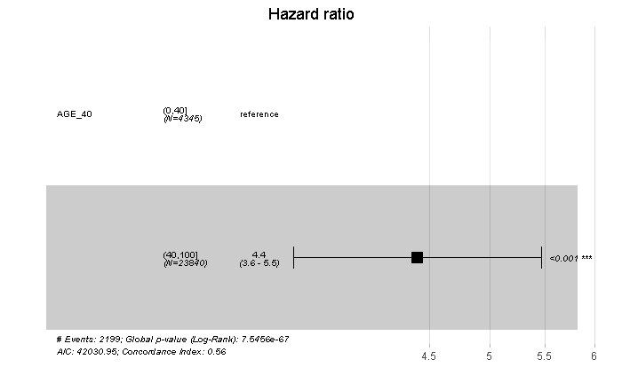

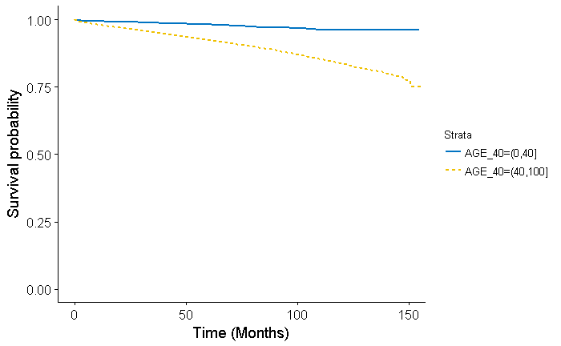

```r
uni_var(test_var = "AGE_40", data_imp = data)
```

## Gender

```
_________________________________________________

## SEX_F
_________________________________________________
Call: survfit(formula = Surv(DX_LASTCONTACT_DEATH_MONTHS, PUF_VITAL_STATUS ==
    0) ~ SEX_F, data = data)

                 n events median 0.95LCL 0.95UCL
SEX_F=Male   13276   1122     NA      NA      NA
SEX_F=Female 14914   1077     NA      NA      NA

Call: survfit(formula = Surv(DX_LASTCONTACT_DEATH_MONTHS, PUF_VITAL_STATUS ==
    0) ~ SEX_F, data = data)

                SEX_F=Male
 time n.risk n.event survival std.err lower 95% CI upper 95% CI
   12  12151     262    0.980 0.00125        0.977        0.982
   24  10764     157    0.966 0.00162        0.963        0.969
   36   9230     120    0.955 0.00191        0.951        0.959
   48   7713     131    0.940 0.00227        0.936        0.945
   60   6296     107    0.926 0.00262        0.921        0.931
  120   1216     311    0.844 0.00548        0.833        0.854

                SEX_F=Female
 time n.risk n.event survival std.err lower 95% CI upper 95% CI
   12  13827     237    0.984 0.00105        0.982        0.986
   24  12475     151    0.973 0.00138        0.970        0.975
   36  10685     139    0.961 0.00168        0.958        0.964
   48   9013     107    0.950 0.00194        0.947        0.954
   60   7397      92    0.940 0.00221        0.936        0.944
  120   1465     313    0.866 0.00484        0.857        0.876





## Univariable Cox Proportional Hazard Model for:  SEX_F

Call:
coxph(formula = Surv(DX_LASTCONTACT_DEATH_MONTHS, PUF_VITAL_STATUS ==
    0) ~ SEX_F, data = data)

  n= 28190, number of events= 2199

                coef exp(coef) se(coef)      z Pr(>|z|)
SEX_FFemale -0.18930   0.82754  0.04266 -4.437 9.11e-06 ***
---
Signif. codes:  0 *** 0.001 ** 0.01 * 0.05 . 0.1   1

            exp(coef) exp(-coef) lower .95 upper .95
SEX_FFemale    0.8275      1.208    0.7612    0.8997

Concordance= 0.525  (se = 0.006 )
Rsquare= 0.001   (max possible= 0.777 )
Likelihood ratio test= 19.69  on 1 df,   p=9e-06
Wald test            = 19.69  on 1 df,   p=9e-06
Score (logrank) test = 19.75  on 1 df,   p=9e-06
```

```
Removed 1 rows containing missing values (geom_errorbar).
```

```
## Unadjusted Kaplan Meier Overall Survival Curve for:  SEX_F
```

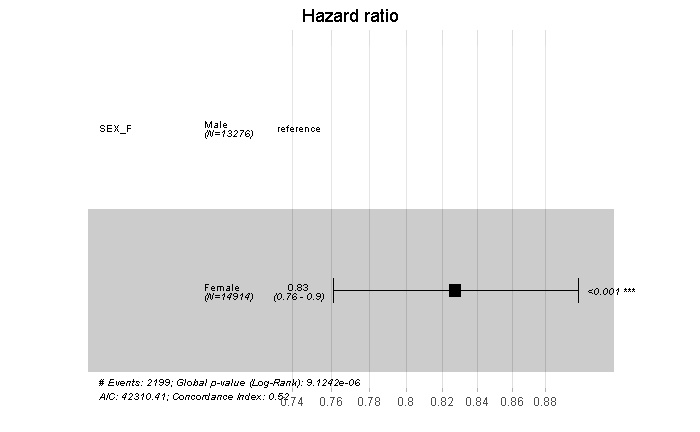

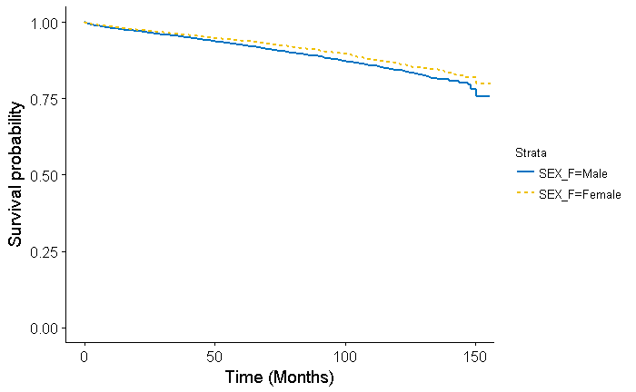

```r
uni_var(test_var = "SEX_F", data_imp = data)
```

## RACE_F

```
_________________________________________________

## RACE_F
_________________________________________________
Call: survfit(formula = Surv(DX_LASTCONTACT_DEATH_MONTHS, PUF_VITAL_STATUS ==
    0) ~ RACE_F, data = data)

                     n events median 0.95LCL 0.95UCL
RACE_F=White     24720   1966     NA      NA      NA
RACE_F=Black      1248    122     NA      NA      NA
RACE_F=Other/Unk  1364     66     NA      NA      NA
RACE_F=Asian       858     45     NA      NA      NA

Call: survfit(formula = Surv(DX_LASTCONTACT_DEATH_MONTHS, PUF_VITAL_STATUS ==
    0) ~ RACE_F, data = data)

                RACE_F=White
 time n.risk n.event survival std.err lower 95% CI upper 95% CI
   12  22834     444    0.981 0.00087        0.980        0.983
   24  20443     276    0.969 0.00113        0.967        0.971
   36  17520     235    0.957 0.00136        0.955        0.960
   48  14740     212    0.945 0.00159        0.942        0.948
   60  12069     174    0.933 0.00182        0.929        0.936
  120   2417     559    0.855 0.00385        0.847        0.862

                RACE_F=Black
 time n.risk n.event survival std.err lower 95% CI upper 95% CI
   12   1137      32    0.974 0.00460        0.965        0.983
   24   1005      12    0.963 0.00551        0.952        0.974
   36    855      15    0.947 0.00673        0.934        0.961
   48    708      14    0.931 0.00793        0.915        0.946
   60    570      15    0.909 0.00956        0.890        0.928
  120     86      33    0.810 0.02044        0.771        0.851

                RACE_F=Other/Unk
 time n.risk n.event survival std.err lower 95% CI upper 95% CI
   12   1230      12    0.991 0.00266        0.986        0.996
   24   1120      11    0.982 0.00383        0.974        0.989
   36    973       3    0.979 0.00414        0.971        0.987
   48    836       8    0.970 0.00513        0.960        0.980
```

[output cut: 26 more lines]

```
RACE_FOther/Unk -0.48526   0.61554  0.12514 -3.878 0.000105 ***
RACE_FAsian     -0.30362   0.73814  0.15078 -2.014 0.044050 *
---
Signif. codes:  0 *** 0.001 ** 0.01 * 0.05 . 0.1   1

                exp(coef) exp(-coef) lower .95 upper .95
RACE_FBlack        1.3174     0.7591    1.0972    1.5818
RACE_FOther/Unk    0.6155     1.6246    0.4816    0.7866
RACE_FAsian        0.7381     1.3547    0.5493    0.9919

Concordance= 0.52  (se = 0.004 )
Rsquare= 0.001   (max possible= 0.777 )
Likelihood ratio test= 31.12  on 3 df,   p=8e-07
Wald test            = 28.89  on 3 df,   p=2e-06
Score (logrank) test = 29.38  on 3 df,   p=2e-06
```

```
Removed 1 rows containing missing values (geom_errorbar).
```

```
## Unadjusted Kaplan Meier Overall Survival Curve for:  RACE_F
```

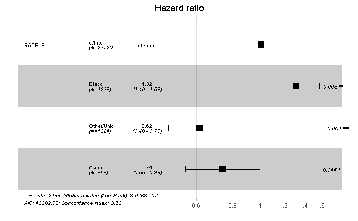

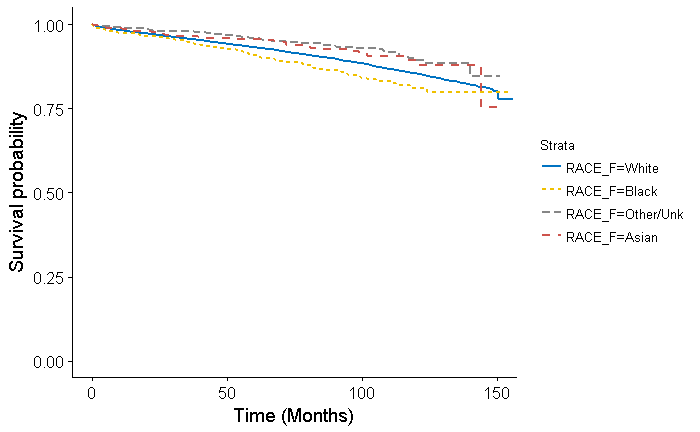

```r
uni_var(test_var = "RACE_F", data_imp = data)
```

## Hispanic

```
_________________________________________________

## HISPANIC
_________________________________________________
Call: survfit(formula = Surv(DX_LASTCONTACT_DEATH_MONTHS, PUF_VITAL_STATUS ==
    0) ~ HISPANIC, data = data)

                     n events median 0.95LCL 0.95UCL
HISPANIC=No      24750   1964     NA      NA      NA
HISPANIC=Yes      1320     73     NA      NA      NA
HISPANIC=Unknown  2120    162     NA      NA      NA

Call: survfit(formula = Surv(DX_LASTCONTACT_DEATH_MONTHS, PUF_VITAL_STATUS ==
    0) ~ HISPANIC, data = data)

                HISPANIC=No
 time n.risk n.event survival  std.err lower 95% CI upper 95% CI
   12  22875     434    0.982 0.000859        0.980        0.984
   24  20412     277    0.970 0.001126        0.967        0.972
   36  17435     236    0.958 0.001358        0.955        0.960
   48  14565     210    0.945 0.001591        0.942        0.948
   60  11852     178    0.932 0.001829        0.929        0.936
  120   2306     562    0.852 0.003957        0.844        0.860

                HISPANIC=Yes
 time n.risk n.event survival std.err lower 95% CI upper 95% CI
   12   1178      21    0.983 0.00359        0.976        0.990
   24   1041      13    0.972 0.00477        0.963        0.981
   36    865       9    0.963 0.00561        0.952        0.974
   48    715      10    0.951 0.00670        0.938        0.964
   60    584       5    0.943 0.00742        0.929        0.958
  120     90      15    0.889 0.01620        0.858        0.921

                HISPANIC=Unknown
 time n.risk n.event survival std.err lower 95% CI upper 95% CI
   12   1925      44    0.978 0.00323        0.972        0.985
   24   1786      18    0.969 0.00388        0.961        0.977
   36   1615      14    0.961 0.00438        0.953        0.970
   48   1446      18    0.950 0.00507        0.940        0.960
   60   1257      16    0.939 0.00575        0.927        0.950
```

[output cut: 14 more lines]

```
                   coef exp(coef) se(coef)      z Pr(>|z|)
HISPANICYes     -0.2706    0.7629   0.1192 -2.270   0.0232 *
HISPANICUnknown -0.1728    0.8413   0.0818 -2.113   0.0346 *
---
Signif. codes:  0 *** 0.001 ** 0.01 * 0.05 . 0.1   1

                exp(coef) exp(-coef) lower .95 upper .95
HISPANICYes        0.7629      1.311    0.6040    0.9637
HISPANICUnknown    0.8413      1.189    0.7167    0.9876

Concordance= 0.507  (se = 0.004 )
Rsquare= 0   (max possible= 0.777 )
Likelihood ratio test= 9.72  on 2 df,   p=0.008
Wald test            = 9.14  on 2 df,   p=0.01
Score (logrank) test = 9.18  on 2 df,   p=0.01
```

```
Removed 1 rows containing missing values (geom_errorbar).
```

```
## Unadjusted Kaplan Meier Overall Survival Curve for:  HISPANIC
```

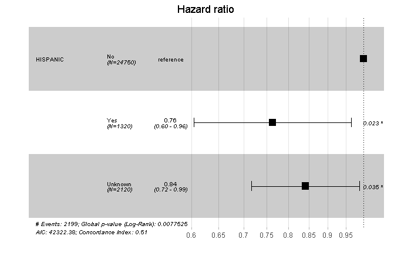

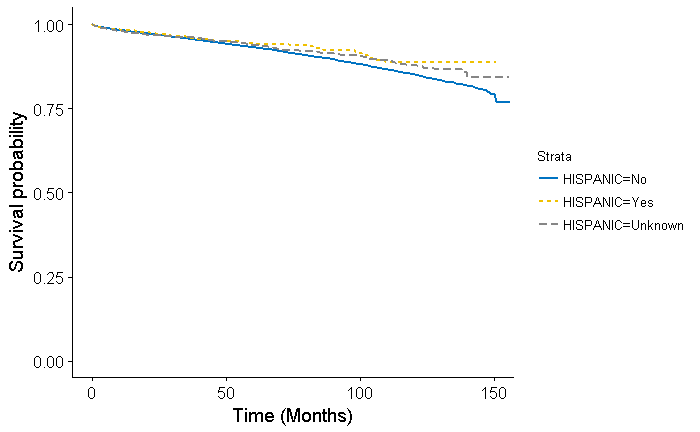

```r
uni_var(test_var = "HISPANIC", data_imp = data)
```

## Insurance Status

```
_________________________________________________

## INSURANCE_F
_________________________________________________
Call: survfit(formula = Surv(DX_LASTCONTACT_DEATH_MONTHS, PUF_VITAL_STATUS ==
    0) ~ INSURANCE_F, data = data)

                                 n events median 0.95LCL 0.95UCL
INSURANCE_F=Private          17766    619     NA      NA      NA
INSURANCE_F=None               589     41     NA      NA      NA
INSURANCE_F=Medicaid          1212    101     NA      NA      NA
INSURANCE_F=Medicare          7394   1349    150     147      NA
INSURANCE_F=Other Government   580     35     NA      NA      NA
INSURANCE_F=Unknown            649     54     NA      NA      NA

Call: survfit(formula = Surv(DX_LASTCONTACT_DEATH_MONTHS, PUF_VITAL_STATUS ==
    0) ~ INSURANCE_F, data = data)

                INSURANCE_F=Private
 time n.risk n.event survival  std.err lower 95% CI upper 95% CI
   12  16544     141    0.992 0.000686        0.990        0.993
   24  14953      69    0.987 0.000858        0.986        0.989
   36  12944      72    0.982 0.001044        0.980        0.984
   48  11014      62    0.977 0.001220        0.975        0.980
   60   9146      56    0.972 0.001416        0.969        0.975
  120   1893     199    0.934 0.003189        0.928        0.940

                INSURANCE_F=None
 time n.risk n.event survival std.err lower 95% CI upper 95% CI
   12    519      15    0.973 0.00688        0.960        0.987
   24    459       5    0.963 0.00816        0.947        0.979
   36    385       5    0.952 0.00949        0.933        0.970
   48    333       3    0.943 0.01052        0.923        0.964
   60    262       3    0.934 0.01170        0.912        0.957
  120     43       9    0.848 0.03192        0.788        0.913

                INSURANCE_F=Medicaid
 time n.risk n.event survival std.err lower 95% CI upper 95% CI
   12   1085      26    0.978 0.00433        0.969        0.986
   24    909      19    0.959 0.00602        0.947        0.971
```

[output cut: 50 more lines]

```
---
Signif. codes:  0 *** 0.001 ** 0.01 * 0.05 . 0.1   1

                            exp(coef) exp(-coef) lower .95 upper .95
INSURANCE_FNone                 2.259     0.4426     1.647     3.099
INSURANCE_FMedicaid             2.885     0.3466     2.338     3.561
INSURANCE_FMedicare             5.922     0.1689     5.384     6.514
INSURANCE_FOther Government     2.076     0.4816     1.477     2.919
INSURANCE_FUnknown              2.222     0.4501     1.682     2.934

Concordance= 0.705  (se = 0.006 )
Rsquare= 0.051   (max possible= 0.777 )
Likelihood ratio test= 1480  on 5 df,   p=<2e-16
Wald test            = 1364  on 5 df,   p=<2e-16
Score (logrank) test = 1724  on 5 df,   p=<2e-16
```

```
Removed 1 rows containing missing values (geom_errorbar).
```

```
## Unadjusted Kaplan Meier Overall Survival Curve for:  INSURANCE_F
```

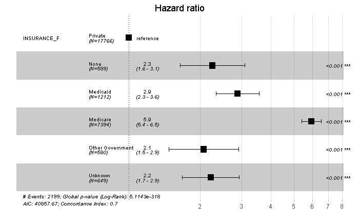

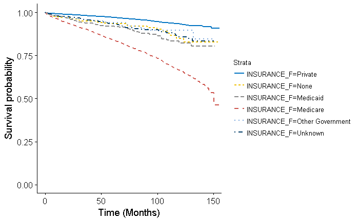

```r
uni_var(test_var = "INSURANCE_F", data_imp = data)
```

## Income

```
_________________________________________________

## INCOME_F
_________________________________________________
Call: survfit(formula = Surv(DX_LASTCONTACT_DEATH_MONTHS, PUF_VITAL_STATUS ==
    0) ~ INCOME_F, data = data)

   217 observations deleted due to missingness
                               n events median 0.95LCL 0.95UCL
INCOME_F=Less than $38,000  3406    331     NA      NA      NA
INCOME_F=$38,000 - $47,999  5864    541     NA      NA      NA
INCOME_F=$48,000 - $62,999  7961    623     NA      NA      NA
INCOME_F=$63,000 +         10742    670     NA      NA      NA

Call: survfit(formula = Surv(DX_LASTCONTACT_DEATH_MONTHS, PUF_VITAL_STATUS ==
    0) ~ INCOME_F, data = data)

217 observations deleted due to missingness
                INCOME_F=Less than $38,000
 time n.risk n.event survival std.err lower 95% CI upper 95% CI
   12   3110      74    0.977 0.00259        0.972        0.983
   24   2768      38    0.965 0.00325        0.959        0.971
   36   2379      33    0.953 0.00387        0.945        0.960
   48   1987      40    0.935 0.00468        0.926        0.944
   60   1609      30    0.920 0.00539        0.909        0.930
  120    320     108    0.815 0.01137        0.793        0.837

                INCOME_F=$38,000 - $47,999
 time n.risk n.event survival std.err lower 95% CI upper 95% CI
   12   5386     124    0.978 0.00193        0.974        0.982
   24   4778      84    0.962 0.00257        0.957        0.967
   36   4106      67    0.948 0.00307        0.942        0.954
   48   3456      55    0.934 0.00354        0.927        0.941
   60   2839      44    0.921 0.00399        0.914        0.929
  120    593     148    0.837 0.00813        0.821        0.853

                INCOME_F=$48,000 - $62,999
 time n.risk n.event survival std.err lower 95% CI upper 95% CI
   12   7323     123    0.984 0.00143        0.981        0.987
   24   6567      90    0.971 0.00193        0.968        0.975
```

[output cut: 29 more lines]

```
INCOME_F$48,000 - $62,999 -0.21962   0.80283  0.06802 -3.229  0.00124 **
INCOME_F$63,000 +         -0.46498   0.62815  0.06719 -6.921 4.49e-12 ***
---
Signif. codes:  0 *** 0.001 ** 0.01 * 0.05 . 0.1   1

                          exp(coef) exp(-coef) lower .95 upper .95
INCOME_F$38,000 - $47,999    0.9353      1.069    0.8157    1.0724
INCOME_F$48,000 - $62,999    0.8028      1.246    0.7026    0.9173
INCOME_F$63,000 +            0.6281      1.592    0.5506    0.7166

Concordance= 0.547  (se = 0.006 )
Rsquare= 0.002   (max possible= 0.774 )
Likelihood ratio test= 69.8  on 3 df,   p=5e-15
Wald test            = 68.87  on 3 df,   p=7e-15
Score (logrank) test = 69.71  on 3 df,   p=5e-15
```

```
Removed 1 rows containing missing values (geom_errorbar).
```

```
## Unadjusted Kaplan Meier Overall Survival Curve for:  INCOME_F
```

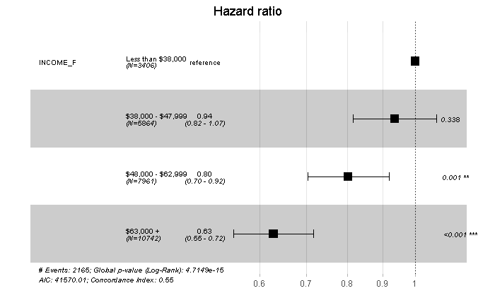

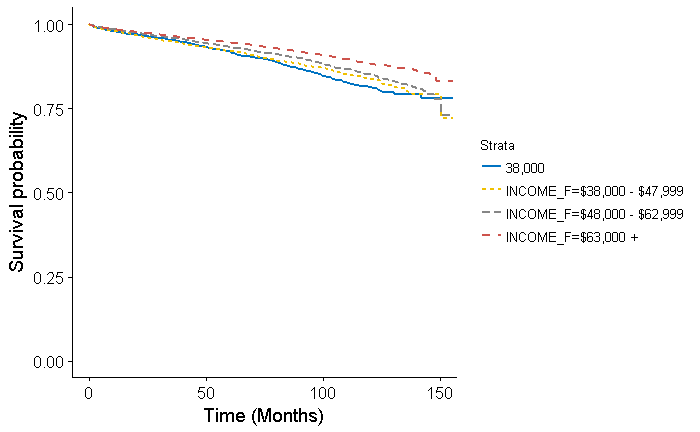

```r
uni_var(test_var = "INCOME_F", data_imp = data)
```

## Education

```
_________________________________________________

## EDUCATION_F
_________________________________________________
Call: survfit(formula = Surv(DX_LASTCONTACT_DEATH_MONTHS, PUF_VITAL_STATUS ==
    0) ~ EDUCATION_F, data = data)

   206 observations deleted due to missingness
                            n events median 0.95LCL 0.95UCL
EDUCATION_F=21% or more  3276    309     NA      NA      NA
EDUCATION_F=13 - 20.9%   6186    546     NA      NA      NA
EDUCATION_F=7 - 12.9%    9685    747     NA      NA      NA
EDUCATION_F=Less than 7% 8837    563     NA      NA      NA

Call: survfit(formula = Surv(DX_LASTCONTACT_DEATH_MONTHS, PUF_VITAL_STATUS ==
    0) ~ EDUCATION_F, data = data)

206 observations deleted due to missingness
                EDUCATION_F=21% or more
 time n.risk n.event survival std.err lower 95% CI upper 95% CI
   12   2990      81    0.974 0.00280        0.969        0.980
   24   2675      41    0.960 0.00351        0.954        0.967
   36   2258      32    0.948 0.00410        0.940        0.956
   48   1896      30    0.934 0.00477        0.925        0.943
   60   1518      32    0.917 0.00558        0.906        0.928
  120    285      82    0.829 0.01117        0.808        0.851

                EDUCATION_F=13 - 20.9%
 time n.risk n.event survival std.err lower 95% CI upper 95% CI
   12   5701     120    0.980 0.00181        0.976        0.984
   24   5082      75    0.967 0.00235        0.962        0.971
   36   4373      70    0.952 0.00288        0.947        0.958
   48   3676      60    0.938 0.00335        0.932        0.945
   60   2999      46    0.926 0.00380        0.918        0.933
  120    583     161    0.845 0.00748        0.830        0.860

                EDUCATION_F=7 - 12.9%
 time n.risk n.event survival std.err lower 95% CI upper 95% CI
   12   8917     150    0.984 0.00130        0.981        0.987
   24   7989     109    0.971 0.00175        0.968        0.975
```

[output cut: 29 more lines]

```
EDUCATION_F7 - 12.9%    -0.22810   0.79605  0.06764 -3.372 0.000746 ***
EDUCATION_FLess than 7% -0.43652   0.64628  0.07080 -6.165 7.04e-10 ***
---
Signif. codes:  0 *** 0.001 ** 0.01 * 0.05 . 0.1   1

                        exp(coef) exp(-coef) lower .95 upper .95
EDUCATION_F13 - 20.9%      0.9114      1.097    0.7927    1.0479
EDUCATION_F7 - 12.9%       0.7960      1.256    0.6972    0.9089
EDUCATION_FLess than 7%    0.6463      1.547    0.5625    0.7425

Concordance= 0.542  (se = 0.007 )
Rsquare= 0.002   (max possible= 0.774 )
Likelihood ratio test= 50.73  on 3 df,   p=6e-11
Wald test            = 50.2  on 3 df,   p=7e-11
Score (logrank) test = 50.67  on 3 df,   p=6e-11
```

```
Removed 1 rows containing missing values (geom_errorbar).
```

```
## Unadjusted Kaplan Meier Overall Survival Curve for:  EDUCATION_F
```

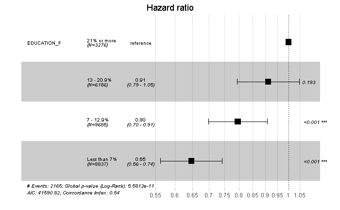

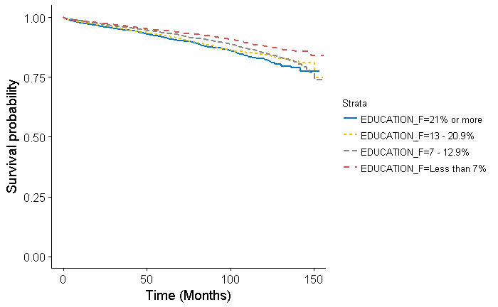

```r
uni_var(test_var = "EDUCATION_F", data_imp = data)
```

## Urban/Rural

```
_________________________________________________

## U_R_F
_________________________________________________
Call: survfit(formula = Surv(DX_LASTCONTACT_DEATH_MONTHS, PUF_VITAL_STATUS ==
    0) ~ U_R_F, data = data)

   846 observations deleted due to missingness
                n events median 0.95LCL 0.95UCL
U_R_F=Metro 23099   1721     NA      NA      NA
U_R_F=Urban  3820    352     NA      NA      NA
U_R_F=Rural   425     42     NA      NA      NA

Call: survfit(formula = Surv(DX_LASTCONTACT_DEATH_MONTHS, PUF_VITAL_STATUS ==
    0) ~ U_R_F, data = data)

846 observations deleted due to missingness
                U_R_F=Metro
 time n.risk n.event survival  std.err lower 95% CI upper 95% CI
   12  21334     397    0.982 0.000881        0.981        0.984
   24  19114     242    0.971 0.001144        0.968        0.973
   36  16398     198    0.960 0.001364        0.957        0.963
   48  13776     184    0.948 0.001595        0.945        0.951
   60  11271     160    0.936 0.001839        0.933        0.940
  120   2193     481    0.862 0.003979        0.854        0.870

                U_R_F=Urban
 time n.risk n.event survival std.err lower 95% CI upper 95% CI
   12   3514      67    0.982 0.00219        0.978        0.986
   24   3121      46    0.968 0.00293        0.963        0.974
   36   2676      49    0.952 0.00369        0.945        0.959
   48   2257      43    0.936 0.00440        0.927        0.944
   60   1851      29    0.923 0.00495        0.913        0.933
  120    385     108    0.831 0.01017        0.812        0.851

                U_R_F=Rural
 time n.risk n.event survival std.err lower 95% CI upper 95% CI
   12    383      11    0.973 0.00795        0.958        0.989
   24    344       5    0.960 0.00988        0.941        0.979
   36    293       2    0.954 0.01066        0.933        0.975
```

[output cut: 17 more lines]

```
             coef exp(coef) se(coef)     z Pr(>|z|)
U_R_FUrban 0.2163    1.2415   0.0585 3.698 0.000217 ***
U_R_FRural 0.3372    1.4011   0.1562 2.159 0.030833 *
---
Signif. codes:  0 *** 0.001 ** 0.01 * 0.05 . 0.1   1

           exp(coef) exp(-coef) lower .95 upper .95
U_R_FUrban     1.242     0.8055     1.107     1.392
U_R_FRural     1.401     0.7137     1.032     1.903

Concordance= 0.515  (se = 0.004 )
Rsquare= 0.001   (max possible= 0.773 )
Likelihood ratio test= 16.48  on 2 df,   p=3e-04
Wald test            = 17.39  on 2 df,   p=2e-04
Score (logrank) test = 17.48  on 2 df,   p=2e-04
```

```
Removed 1 rows containing missing values (geom_errorbar).
```

```
## Unadjusted Kaplan Meier Overall Survival Curve for:  U_R_F
```

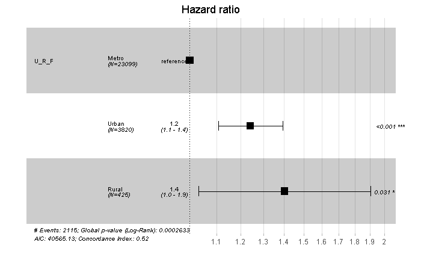

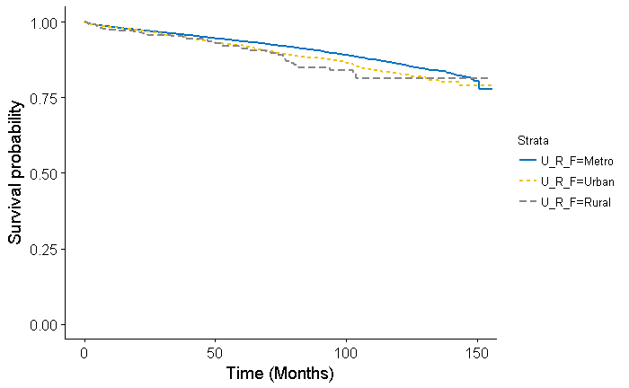

```r
uni_var(test_var = "U_R_F", data_imp = data)
```

## Comorbidities

```
_________________________________________________

## CDCC_TOTAL
_________________________________________________
Call: survfit(formula = Surv(DX_LASTCONTACT_DEATH_MONTHS, PUF_VITAL_STATUS ==
    0) ~ CDCC_TOTAL, data = data)

                 n events median 0.95LCL 0.95UCL
CDCC_TOTAL=0 24991   1682     NA      NA      NA
CDCC_TOTAL=1  2605    353     NA   150.5      NA
CDCC_TOTAL=2   443    121    121   107.6      NA
CDCC_TOTAL=3   151     43    108    83.7      NA

Call: survfit(formula = Surv(DX_LASTCONTACT_DEATH_MONTHS, PUF_VITAL_STATUS ==
    0) ~ CDCC_TOTAL, data = data)

                CDCC_TOTAL=0
 time n.risk n.event survival  std.err lower 95% CI upper 95% CI
   12  23122     339    0.986 0.000757        0.984        0.987
   24  20748     236    0.975 0.001011        0.974        0.977
   36  17852     201    0.965 0.001227        0.963        0.968
   48  15074     171    0.955 0.001432        0.953        0.958
   60  12356     159    0.944 0.001661        0.941        0.948
  120   2466     519    0.873 0.003672        0.865        0.880

                CDCC_TOTAL=1
 time n.risk n.event survival std.err lower 95% CI upper 95% CI
   12   2339     112    0.956 0.00407        0.948        0.964
   24   2051      48    0.935 0.00494        0.926        0.945
   36   1704      42    0.915 0.00577        0.904        0.926
   48   1378      45    0.888 0.00683        0.875        0.902
   60   1119      29    0.868 0.00765        0.853        0.883
  120    186      67    0.768 0.01467        0.740        0.797

                CDCC_TOTAL=2
 time n.risk n.event survival std.err lower 95% CI upper 95% CI
   12    386      36    0.917  0.0133        0.891        0.943
   24    337      12    0.887  0.0154        0.857        0.918
   36    284      12    0.853  0.0176        0.820        0.889
   48    222      19    0.791  0.0214        0.750        0.834
```

[output cut: 26 more lines]

```
CDCC_TOTAL2 1.56772   4.79568  0.09416 16.65   <2e-16 ***
CDCC_TOTAL3 1.83374   6.25724  0.15464 11.86   <2e-16 ***
---
Signif. codes:  0 *** 0.001 ** 0.01 * 0.05 . 0.1   1

            exp(coef) exp(-coef) lower .95 upper .95
CDCC_TOTAL1     2.250     0.4444     2.006     2.524
CDCC_TOTAL2     4.796     0.2085     3.987     5.768
CDCC_TOTAL3     6.257     0.1598     4.621     8.472

Concordance= 0.578  (se = 0.004 )
Rsquare= 0.014   (max possible= 0.777 )
Likelihood ratio test= 398.5  on 3 df,   p=<2e-16
Wald test            = 532.4  on 3 df,   p=<2e-16
Score (logrank) test = 628.1  on 3 df,   p=<2e-16
```

```
Removed 1 rows containing missing values (geom_errorbar).
```

```
## Unadjusted Kaplan Meier Overall Survival Curve for:  CDCC_TOTAL
```

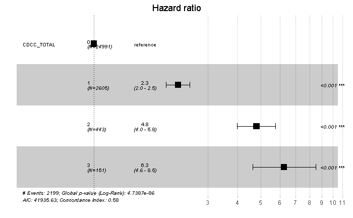

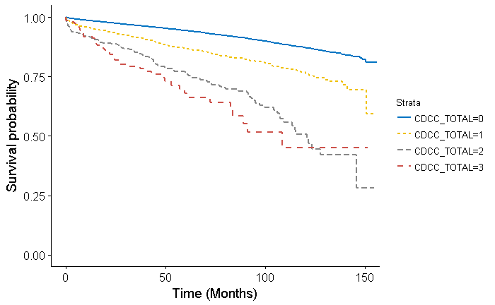

```r
uni_var(test_var = "CDCC_TOTAL", data_imp = data)
```

## Class (treatment at performing facility)

```
_________________________________________________

## CLASS_OF_CASE_F
_________________________________________________
Call: survfit(formula = Surv(DX_LASTCONTACT_DEATH_MONTHS, PUF_VITAL_STATUS ==
    0) ~ CLASS_OF_CASE_F, data = data)

                                   n events median 0.95LCL 0.95UCL
CLASS_OF_CASE_F=Other_Facility  1404    124     NA      NA      NA
CLASS_OF_CASE_F=All_Part_Prim  26786   2075     NA      NA      NA

Call: survfit(formula = Surv(DX_LASTCONTACT_DEATH_MONTHS, PUF_VITAL_STATUS ==
    0) ~ CLASS_OF_CASE_F, data = data)

                CLASS_OF_CASE_F=Other_Facility
 time n.risk n.event survival std.err lower 95% CI upper 95% CI
   12   1045      32    0.973 0.00473        0.964        0.982
   24    871      22    0.951 0.00653        0.938        0.964
   36    659      21    0.926 0.00840        0.909        0.942
   48    541      11    0.909 0.00966        0.890        0.928
   60    415      13    0.885 0.01149        0.863        0.908
  120     59      24    0.785 0.02411        0.739        0.834

                CLASS_OF_CASE_F=All_Part_Prim
 time n.risk n.event survival std.err lower 95% CI upper 95% CI
   12  24933     467    0.982 0.00082        0.981        0.984
   24  22368     286    0.970 0.00106        0.968        0.972
   36  19256     238    0.959 0.00127        0.957        0.962
   48  16185     227    0.947 0.00149        0.944        0.950
   60  13278     186    0.935 0.00171        0.932        0.939
  120   2622     600    0.858 0.00367        0.851        0.865





## Univariable Cox Proportional Hazard Model for:  CLASS_OF_CASE_F

Call:
coxph(formula = Surv(DX_LASTCONTACT_DEATH_MONTHS, PUF_VITAL_STATUS ==
    0) ~ CLASS_OF_CASE_F, data = data)

  n= 28190, number of events= 2199

                                 coef exp(coef) se(coef)      z Pr(>|z|)
CLASS_OF_CASE_FAll_Part_Prim -0.53080   0.58814  0.09257 -5.734 9.82e-09 ***
---
Signif. codes:  0 *** 0.001 ** 0.01 * 0.05 . 0.1   1

                             exp(coef) exp(-coef) lower .95 upper .95
CLASS_OF_CASE_FAll_Part_Prim    0.5881        1.7    0.4905    0.7051

Concordance= 0.513  (se = 0.002 )
Rsquare= 0.001   (max possible= 0.777 )
Likelihood ratio test= 28.23  on 1 df,   p=1e-07
Wald test            = 32.88  on 1 df,   p=1e-08
Score (logrank) test = 33.65  on 1 df,   p=7e-09
```

```
Removed 1 rows containing missing values (geom_errorbar).
```

```
## Unadjusted Kaplan Meier Overall Survival Curve for:  CLASS_OF_CASE_F
```

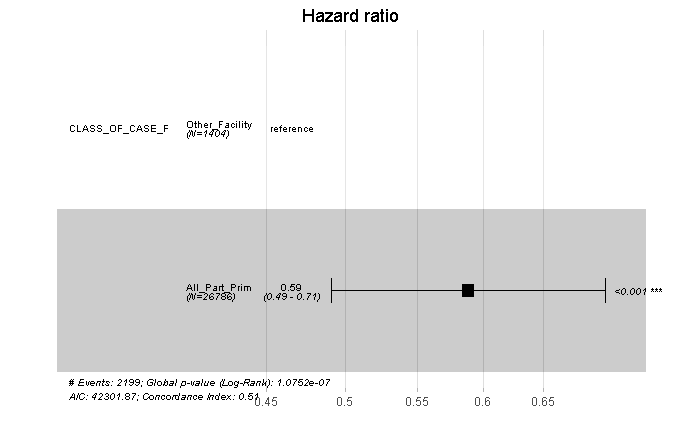

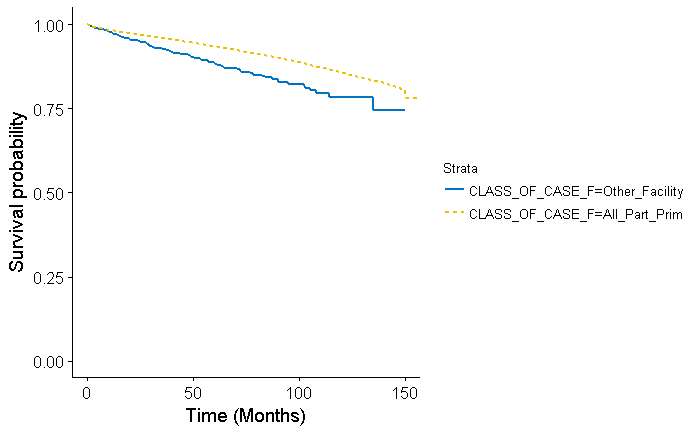

```r
uni_var(test_var = "CLASS_OF_CASE_F", data_imp = data)
```

## Year

```
_________________________________________________

## YEAR_OF_DIAGNOSIS
_________________________________________________
Call: survfit(formula = Surv(DX_LASTCONTACT_DEATH_MONTHS, PUF_VITAL_STATUS ==
    0) ~ YEAR_OF_DIAGNOSIS, data = data)

                          n events median 0.95LCL 0.95UCL
YEAR_OF_DIAGNOSIS=2014 2830     98     NA      NA      NA
YEAR_OF_DIAGNOSIS=2004 2068    252     NA      NA      NA
YEAR_OF_DIAGNOSIS=2005 2281    309  143.9      NA      NA
YEAR_OF_DIAGNOSIS=2006 2333    267     NA      NA      NA
YEAR_OF_DIAGNOSIS=2007 2487    260     NA      NA      NA
YEAR_OF_DIAGNOSIS=2008 2555    232     NA      NA      NA
YEAR_OF_DIAGNOSIS=2009 2699    208     NA      NA      NA
YEAR_OF_DIAGNOSIS=2010 2571    181     NA      NA      NA
YEAR_OF_DIAGNOSIS=2011 2713    171     NA      NA      NA
YEAR_OF_DIAGNOSIS=2012 2802    110     NA      NA      NA
YEAR_OF_DIAGNOSIS=2013 2851    111   48.4      NA      NA

Call: survfit(formula = Surv(DX_LASTCONTACT_DEATH_MONTHS, PUF_VITAL_STATUS ==
    0) ~ YEAR_OF_DIAGNOSIS, data = data)

                YEAR_OF_DIAGNOSIS=2014
 time n.risk n.event survival std.err lower 95% CI upper 95% CI
   12   2346      58    0.978 0.00286        0.972        0.984
   24    969      31    0.961 0.00423        0.953        0.969
   36      7       9    0.929 0.01461        0.901        0.958

                YEAR_OF_DIAGNOSIS=2004
 time n.risk n.event survival std.err lower 95% CI upper 95% CI
   12   1897      34    0.983 0.00290        0.977        0.989
   24   1811      27    0.969 0.00394        0.961        0.976
   36   1752      25    0.955 0.00472        0.946        0.965
   48   1698      24    0.942 0.00537        0.932        0.953
   60   1628      24    0.929 0.00595        0.917        0.940
  120   1098      82    0.876 0.00799        0.860        0.892

                YEAR_OF_DIAGNOSIS=2005
 time n.risk n.event survival std.err lower 95% CI upper 95% CI
```

[output cut: 100 more lines]

```
YEAR_OF_DIAGNOSIS2005    0.7502      1.333    0.5898    0.9543
YEAR_OF_DIAGNOSIS2006    0.7175      1.394    0.5628    0.9147
YEAR_OF_DIAGNOSIS2007    0.7553      1.324    0.5928    0.9622
YEAR_OF_DIAGNOSIS2008    0.7616      1.313    0.5963    0.9726
YEAR_OF_DIAGNOSIS2009    0.7264      1.377    0.5672    0.9304
YEAR_OF_DIAGNOSIS2010    0.7635      1.310    0.5935    0.9822
YEAR_OF_DIAGNOSIS2011    0.8282      1.207    0.6431    1.0666
YEAR_OF_DIAGNOSIS2012    0.6191      1.615    0.4702    0.8153
YEAR_OF_DIAGNOSIS2013    0.8067      1.240    0.6141    1.0597

Concordance= 0.52  (se = 0.007 )
Rsquare= 0.001   (max possible= 0.777 )
Likelihood ratio test= 20.52  on 10 df,   p=0.02
Wald test            = 20.61  on 10 df,   p=0.02
Score (logrank) test = 20.74  on 10 df,   p=0.02
```

```
Removed 1 rows containing missing values (geom_errorbar).
```

```
## Unadjusted Kaplan Meier Overall Survival Curve for:  YEAR_OF_DIAGNOSIS
```

```
This manual palette can handle a maximum of 10 values. You have supplied 11.
```

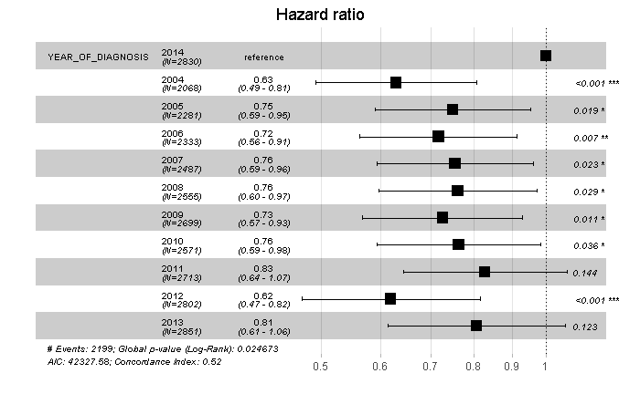

[figure not shown]

```r
uni_var(test_var = "YEAR_OF_DIAGNOSIS", data_imp = data)
```

## Primary Site

```r
#uni_var(test_var = "SITE_TEXT", data_imp = data)
```

## Histology

```
_________________________________________________

## HISTOLOGY_F_LIM
_________________________________________________
Call: survfit(formula = Surv(DX_LASTCONTACT_DEATH_MONTHS, PUF_VITAL_STATUS ==
    0) ~ HISTOLOGY_F_LIM, data = data)

                          n events median 0.95LCL 0.95UCL
HISTOLOGY_F_LIM=9560  27905   2164     NA      NA      NA
HISTOLOGY_F_LIM=Other   285     35     NA      NA      NA

Call: survfit(formula = Surv(DX_LASTCONTACT_DEATH_MONTHS, PUF_VITAL_STATUS ==
    0) ~ HISTOLOGY_F_LIM, data = data)

                HISTOLOGY_F_LIM=9560
 time n.risk n.event survival  std.err lower 95% CI upper 95% CI
   12  25716     495    0.982 0.000815        0.980        0.983
   24  22997     304    0.970 0.001060        0.968        0.972
   36  19700     253    0.958 0.001268        0.956        0.961
   48  16532     234    0.946 0.001486        0.943        0.949
   60  13527     197    0.934 0.001706        0.930        0.937
  120   2644     611    0.857 0.003635        0.850        0.864

                HISTOLOGY_F_LIM=Other
 time n.risk n.event survival std.err lower 95% CI upper 95% CI
   12    262       4    0.986 0.00716        0.972        1.000
   24    242       4    0.970 0.01048        0.950        0.991
   36    215       6    0.945 0.01440        0.917        0.973
   48    194       4    0.926 0.01677        0.894        0.960
   60    166       2    0.916 0.01820        0.881        0.952
  120     37      13    0.766 0.04247        0.687        0.854





## Univariable Cox Proportional Hazard Model for:  HISTOLOGY_F_LIM

Call:
coxph(formula = Surv(DX_LASTCONTACT_DEATH_MONTHS, PUF_VITAL_STATUS ==
    0) ~ HISTOLOGY_F_LIM, data = data)

  n= 28190, number of events= 2199

                       coef exp(coef) se(coef)     z Pr(>|z|)
HISTOLOGY_F_LIMOther 0.3528    1.4231   0.1704 2.071   0.0384 *
---
Signif. codes:  0 *** 0.001 ** 0.01 * 0.05 . 0.1   1

                     exp(coef) exp(-coef) lower .95 upper .95
HISTOLOGY_F_LIMOther     1.423     0.7027     1.019     1.987

Concordance= 0.501  (se = 0.001 )
Rsquare= 0   (max possible= 0.777 )
Likelihood ratio test= 3.84  on 1 df,   p=0.05
Wald test            = 4.29  on 1 df,   p=0.04
Score (logrank) test = 4.33  on 1 df,   p=0.04
```

```
Removed 1 rows containing missing values (geom_errorbar).
```

```
## Unadjusted Kaplan Meier Overall Survival Curve for:  HISTOLOGY_F_LIM
```

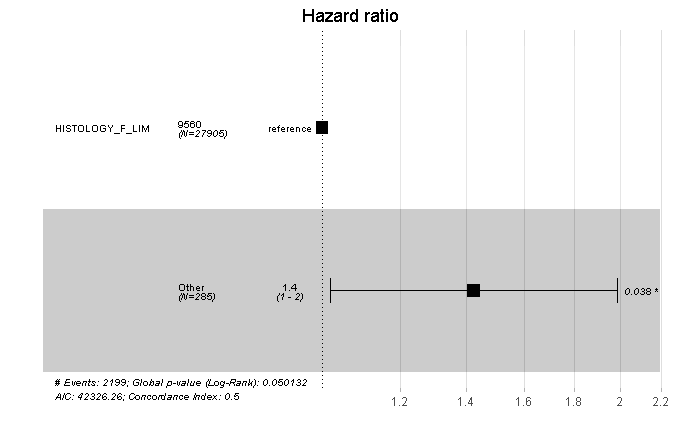

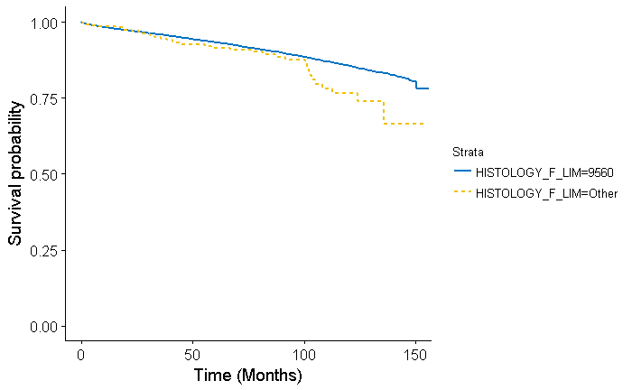

```r
uni_var(test_var = "HISTOLOGY_F_LIM", data_imp = data)
```

## Behavior

```
_________________________________________________

## BEHAVIOR
_________________________________________________
Call: survfit(formula = Surv(DX_LASTCONTACT_DEATH_MONTHS, PUF_VITAL_STATUS ==
    0) ~ BEHAVIOR, data = data)

               n events median 0.95LCL 0.95UCL
BEHAVIOR=0 28131   2189     NA      NA      NA
BEHAVIOR=1    32      4     NA      NA      NA
BEHAVIOR=3    27      6     NA      NA      NA

Call: survfit(formula = Surv(DX_LASTCONTACT_DEATH_MONTHS, PUF_VITAL_STATUS ==
    0) ~ BEHAVIOR, data = data)

                BEHAVIOR=0
 time n.risk n.event survival  std.err lower 95% CI upper 95% CI
   12  25923     496    0.982 0.000809        0.980        0.983
   24  23189     307    0.970 0.001055        0.968        0.972
   36  19870     257    0.958 0.001263        0.956        0.961
   48  16690     234    0.946 0.001478        0.943        0.949
   60  13661     199    0.934 0.001697        0.930        0.937
  120   2671     624    0.856 0.003641        0.849        0.863

                BEHAVIOR=1
 time n.risk n.event survival std.err lower 95% CI upper 95% CI
   12     30       1    0.968  0.0317        0.908        1.000
   24     27       1    0.934  0.0449        0.850        1.000
   36     25       0    0.934  0.0449        0.850        1.000
   48     21       2    0.858  0.0662        0.738        0.998
   60     19       0    0.858  0.0662        0.738        0.998
  120      7       0    0.858  0.0662        0.738        0.998

                BEHAVIOR=3
 time n.risk n.event survival std.err lower 95% CI upper 95% CI
   12     25       2    0.926  0.0504        0.832        1.000
   24     23       0    0.926  0.0504        0.832        1.000
   36     20       2    0.843  0.0722        0.713        0.997
   48     15       2    0.752  0.0887        0.597        0.948
   60     13       0    0.752  0.0887        0.597        0.948
```

[output cut: 14 more lines]

```
            coef exp(coef) se(coef)     z Pr(>|z|)
BEHAVIOR1 0.2311    1.2600   0.5005 0.462   0.6443
BEHAVIOR3 0.9920    2.6966   0.4089 2.426   0.0153 *
---
Signif. codes:  0 *** 0.001 ** 0.01 * 0.05 . 0.1   1

          exp(coef) exp(-coef) lower .95 upper .95
BEHAVIOR1     1.260     0.7937    0.4724     3.361
BEHAVIOR3     2.697     0.3708    1.2099     6.010

Concordance= 0.502  (se = 0.001 )
Rsquare= 0   (max possible= 0.777 )
Likelihood ratio test= 4.54  on 2 df,   p=0.1
Wald test            = 6.09  on 2 df,   p=0.05
Score (logrank) test = 6.59  on 2 df,   p=0.04
```

```
Removed 1 rows containing missing values (geom_errorbar).
```

```
## Unadjusted Kaplan Meier Overall Survival Curve for:  BEHAVIOR
```

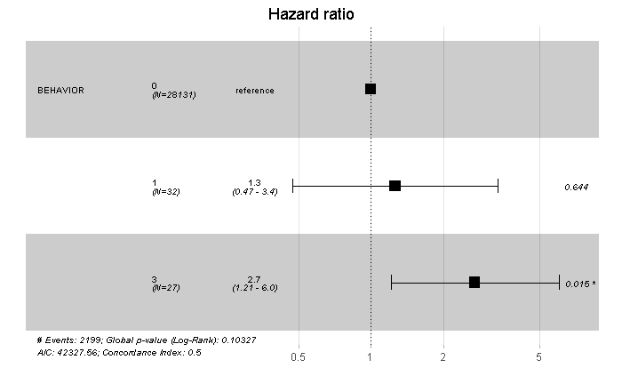

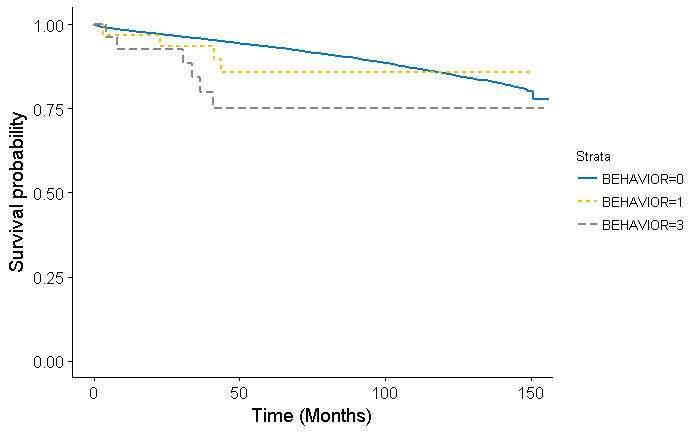

```r
uni_var(test_var = "BEHAVIOR", data_imp = data)
```

## Grade

```
_________________________________________________

## GRADE_F
_________________________________________________
Call: survfit(formula = Surv(DX_LASTCONTACT_DEATH_MONTHS, PUF_VITAL_STATUS ==
    0) ~ GRADE_F, data = data)

                                     n events median 0.95LCL 0.95UCL
GRADE_F=Gr I: Well Diff            198     13     NA      NA      NA
GRADE_F=Gr II: Mod Diff              6      1    132      NA      NA
GRADE_F=Gr IV: Undiff/Anaplastic     6      0     NA      NA      NA
GRADE_F=NA/Unkown                27980   2185     NA      NA      NA

Call: survfit(formula = Surv(DX_LASTCONTACT_DEATH_MONTHS, PUF_VITAL_STATUS ==
    0) ~ GRADE_F, data = data)

                GRADE_F=Gr I: Well Diff
 time n.risk n.event survival std.err lower 95% CI upper 95% CI
   12    176       3    0.984 0.00889        0.967        1.000
   24    151       1    0.979 0.01056        0.958        1.000
   36    125       1    0.971 0.01302        0.946        0.997
   48    104       3    0.946 0.01904        0.909        0.984
   60     85       0    0.946 0.01904        0.909        0.984
  120     10       4    0.833 0.06664        0.712        0.974

                GRADE_F=Gr II: Mod Diff
 time n.risk n.event survival std.err lower 95% CI upper 95% CI
   12      6       0        1       0            1            1
   24      5       0        1       0            1            1
   36      5       0        1       0            1            1
   48      5       0        1       0            1            1
   60      2       0        1       0            1            1
  120      1       0        1       0            1            1

                GRADE_F=Gr IV: Undiff/Anaplastic
 time n.risk n.event survival std.err lower 95% CI upper 95% CI
   12      5       0        1       0            1            1
   24      5       0        1       0            1            1
   36      5       0        1       0            1            1
   48      5       0        1       0            1            1
   60      5       0        1       0            1            1
  120      2       0        1       0            1            1

                GRADE_F=NA/Unkown
 time n.risk n.event survival  std.err lower 95% CI upper 95% CI
   12  25791     496    0.982 0.000814        0.980        0.983
   24  23078     307    0.970 0.001060        0.967        0.972
   36  19780     258    0.958 0.001270        0.955        0.960
   48  16612     235    0.946 0.001486        0.943        0.949
   60  13601     199    0.933 0.001706        0.930        0.937
  120   2668     620    0.856 0.003640        0.849        0.863





## Univariable Cox Proportional Hazard Model for:  GRADE_F
```

```
Loglik converged before variable  2 ; beta may be infinite.
```

```
Call:
coxph(formula = Surv(DX_LASTCONTACT_DEATH_MONTHS, PUF_VITAL_STATUS ==
    0) ~ GRADE_F, data = data)

  n= 28190, number of events= 2199

                                      coef  exp(coef)   se(coef)      z Pr(>|z|)
GRADE_FGr II: Mod Diff           8.354e-01  2.306e+00  1.038e+00  0.805    0.421
GRADE_FGr IV: Undiff/Anaplastic -1.197e+01  6.354e-06  4.688e+02 -0.026    0.980
GRADE_FNA/Unkown                 3.456e-02  1.035e+00  2.782e-01  0.124    0.901

                                exp(coef) exp(-coef) lower .95 upper .95
GRADE_FGr II: Mod Diff          2.306e+00  4.337e-01    0.3016    17.628
GRADE_FGr IV: Undiff/Anaplastic 6.354e-06  1.574e+05    0.0000       Inf
GRADE_FNA/Unkown                1.035e+00  9.660e-01    0.6001     1.786

Concordance= 0.501  (se = 0.001 )
Rsquare= 0   (max possible= 0.777 )
Likelihood ratio test= 2  on 3 df,   p=0.6
Wald test            = 0.66  on 3 df,   p=0.9
Score (logrank) test = 1.43  on 3 df,   p=0.7
```

[output not shown]

```
## Unadjusted Kaplan Meier Overall Survival Curve for:  GRADE_F
```

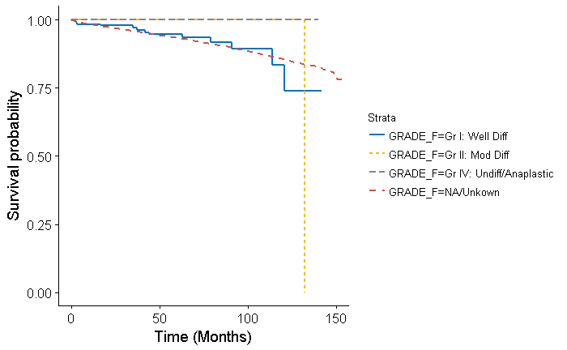

```r
uni_var(test_var = "GRADE_F", data_imp = data)
```

## Clinical T Stage

```
_________________________________________________

## TNM_CLIN_T
_________________________________________________
Call: survfit(formula = Surv(DX_LASTCONTACT_DEATH_MONTHS, PUF_VITAL_STATUS ==
    0) ~ TNM_CLIN_T, data = data)

   474 observations deleted due to missingness
      n  events  median 0.95LCL 0.95UCL
  27716    2177      NA      NA      NA

Call: survfit(formula = Surv(DX_LASTCONTACT_DEATH_MONTHS, PUF_VITAL_STATUS ==
    0) ~ TNM_CLIN_T, data = data)

474 observations deleted due to missingness
 time n.risk n.event survival  std.err lower 95% CI upper 95% CI
   12  25542     492    0.982 0.000818        0.980        0.983
   24  22883     298    0.970 0.001061        0.968        0.972
   36  19658     258    0.958 0.001274        0.956        0.961
   48  16570     237    0.946 0.001493        0.943        0.949
   60  13626     198    0.933 0.001711        0.930        0.937
  120   2681     622    0.856 0.003637        0.849        0.863




## Univariable Cox Proportional Hazard Model for:  TNM_CLIN_T

[1] "Only one level, no Cox model performed"





## Unadjusted Kaplan Meier Overall Survival Curve for:  TNM_CLIN_T
```

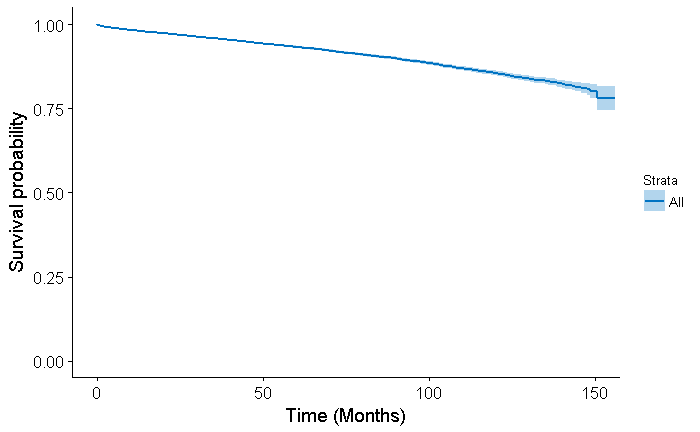

```r
uni_var(test_var = "TNM_CLIN_T", data_imp = data)
```

## Clinical N Stage

```
_________________________________________________

## TNM_CLIN_N
_________________________________________________
Call: survfit(formula = Surv(DX_LASTCONTACT_DEATH_MONTHS, PUF_VITAL_STATUS ==
    0) ~ TNM_CLIN_N, data = data)

   474 observations deleted due to missingness
      n  events  median 0.95LCL 0.95UCL
  27716    2177      NA      NA      NA

Call: survfit(formula = Surv(DX_LASTCONTACT_DEATH_MONTHS, PUF_VITAL_STATUS ==
    0) ~ TNM_CLIN_N, data = data)

474 observations deleted due to missingness
 time n.risk n.event survival  std.err lower 95% CI upper 95% CI
   12  25542     492    0.982 0.000818        0.980        0.983
   24  22883     298    0.970 0.001061        0.968        0.972
   36  19658     258    0.958 0.001274        0.956        0.961
   48  16570     237    0.946 0.001493        0.943        0.949
   60  13626     198    0.933 0.001711        0.930        0.937
  120   2681     622    0.856 0.003637        0.849        0.863




## Univariable Cox Proportional Hazard Model for:  TNM_CLIN_N

[1] "Only one level, no Cox model performed"





## Unadjusted Kaplan Meier Overall Survival Curve for:  TNM_CLIN_N
```

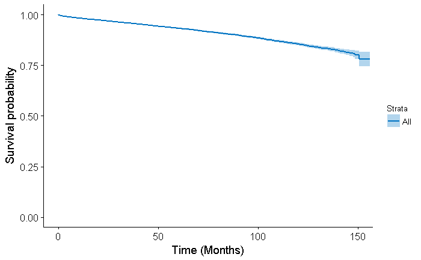

```r
uni_var(test_var = "TNM_CLIN_N", data_imp = data)
```

## Clinical M Stage

```
_________________________________________________

## TNM_CLIN_M
_________________________________________________
Call: survfit(formula = Surv(DX_LASTCONTACT_DEATH_MONTHS, PUF_VITAL_STATUS ==
    0) ~ TNM_CLIN_M, data = data)

   496 observations deleted due to missingness
      n  events  median 0.95LCL 0.95UCL
  27694    2176      NA      NA      NA

Call: survfit(formula = Surv(DX_LASTCONTACT_DEATH_MONTHS, PUF_VITAL_STATUS ==
    0) ~ TNM_CLIN_M, data = data)

496 observations deleted due to missingness
 time n.risk n.event survival  std.err lower 95% CI upper 95% CI
   12  25521     492    0.982 0.000819        0.980        0.983
   24  22865     297    0.970 0.001061        0.968        0.972
   36  19647     258    0.958 0.001274        0.956        0.961
   48  16565     237    0.946 0.001493        0.943        0.949
   60  13625     198    0.933 0.001711        0.930        0.937
  120   2681     622    0.856 0.003637        0.849        0.863




## Univariable Cox Proportional Hazard Model for:  TNM_CLIN_M

[1] "Only one level, no Cox model performed"





## Unadjusted Kaplan Meier Overall Survival Curve for:  TNM_CLIN_M
```

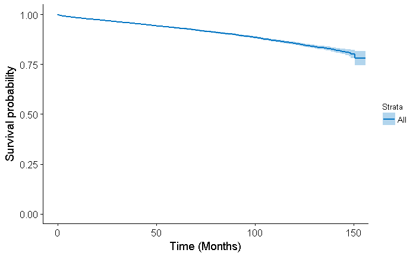

```r
uni_var(test_var = "TNM_CLIN_M", data_imp = data)
```

## Clinical Stage Group

```
_________________________________________________

## TNM_CLIN_STAGE_GROUP
_________________________________________________
Call: survfit(formula = Surv(DX_LASTCONTACT_DEATH_MONTHS, PUF_VITAL_STATUS ==
    0) ~ TNM_CLIN_STAGE_GROUP, data = data)

   214 observations deleted due to missingness
      n  events  median 0.95LCL 0.95UCL
  27976    2186      NA      NA      NA

Call: survfit(formula = Surv(DX_LASTCONTACT_DEATH_MONTHS, PUF_VITAL_STATUS ==
    0) ~ TNM_CLIN_STAGE_GROUP, data = data)

214 observations deleted due to missingness
 time n.risk n.event survival  std.err lower 95% CI upper 95% CI
   12  25782     495    0.982 0.000813        0.980        0.983
   24  23080     302    0.970 0.001056        0.968        0.972
   36  19794     257    0.958 0.001266        0.956        0.961
   48  16652     237    0.946 0.001484        0.943        0.949
   60  13662     199    0.934 0.001703        0.930        0.937
  120   2681     624    0.856 0.003635        0.849        0.863




## Univariable Cox Proportional Hazard Model for:  TNM_CLIN_STAGE_GROUP

[1] "Only one level, no Cox model performed"





## Unadjusted Kaplan Meier Overall Survival Curve for:  TNM_CLIN_STAGE_GROUP
```

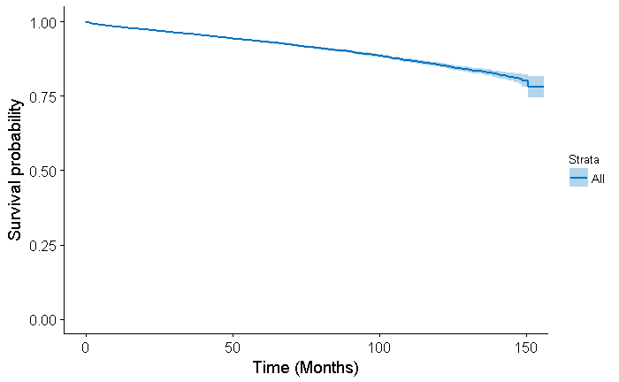

```r
uni_var(test_var = "TNM_CLIN_STAGE_GROUP", data_imp = data)
```

## Pathologic T Stage

```
_________________________________________________

## TNM_PATH_T
_________________________________________________
Call: survfit(formula = Surv(DX_LASTCONTACT_DEATH_MONTHS, PUF_VITAL_STATUS ==
    0) ~ TNM_PATH_T, data = data)

   576 observations deleted due to missingness
      n  events  median 0.95LCL 0.95UCL
  27614    2173      NA      NA      NA

Call: survfit(formula = Surv(DX_LASTCONTACT_DEATH_MONTHS, PUF_VITAL_STATUS ==
    0) ~ TNM_PATH_T, data = data)

576 observations deleted due to missingness
 time n.risk n.event survival  std.err lower 95% CI upper 95% CI
   12  25448     489    0.982 0.000818        0.980        0.983
   24  22808     298    0.970 0.001063        0.968        0.972
   36  19610     257    0.958 0.001276        0.956        0.961
   48  16546     237    0.946 0.001495        0.943        0.949
   60  13617     198    0.933 0.001713        0.930        0.937
  120   2681     622    0.856 0.003638        0.849        0.863




## Univariable Cox Proportional Hazard Model for:  TNM_PATH_T

[1] "Only one level, no Cox model performed"





## Unadjusted Kaplan Meier Overall Survival Curve for:  TNM_PATH_T
```

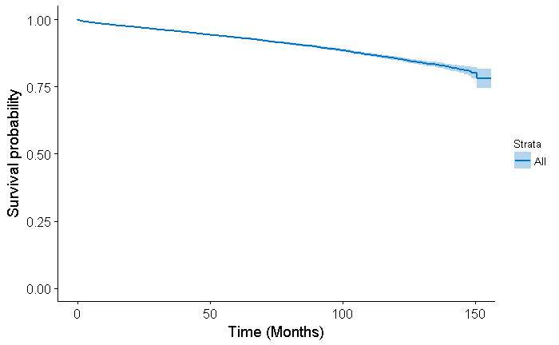

```r
uni_var(test_var = "TNM_PATH_T", data_imp = data)
```

## Pathologic N Stage

```
_________________________________________________

## TNM_PATH_N
_________________________________________________
Call: survfit(formula = Surv(DX_LASTCONTACT_DEATH_MONTHS, PUF_VITAL_STATUS ==
    0) ~ TNM_PATH_N, data = data)

   575 observations deleted due to missingness
      n  events  median 0.95LCL 0.95UCL
  27615    2174      NA      NA      NA

Call: survfit(formula = Surv(DX_LASTCONTACT_DEATH_MONTHS, PUF_VITAL_STATUS ==
    0) ~ TNM_PATH_N, data = data)

575 observations deleted due to missingness
 time n.risk n.event survival  std.err lower 95% CI upper 95% CI
   12  25449     489    0.982 0.000818        0.980        0.983
   24  22809     298    0.970 0.001063        0.968        0.972
   36  19610     258    0.958 0.001276        0.956        0.961
   48  16546     237    0.946 0.001496        0.943        0.948
   60  13617     198    0.933 0.001714        0.930        0.937
  120   2681     622    0.856 0.003638        0.849        0.863




## Univariable Cox Proportional Hazard Model for:  TNM_PATH_N

[1] "Only one level, no Cox model performed"





## Unadjusted Kaplan Meier Overall Survival Curve for:  TNM_PATH_N
```

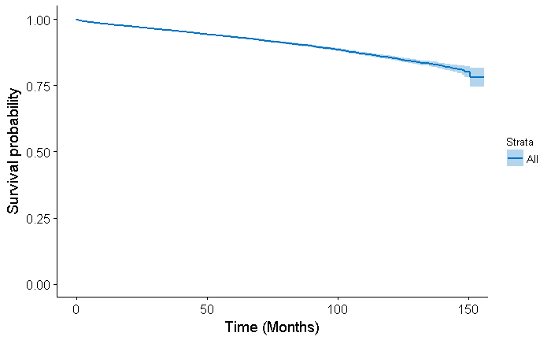

```r
uni_var(test_var = "TNM_PATH_N", data_imp = data)
```

## Pathologic M Stage

```
_________________________________________________

## TNM_PATH_M
_________________________________________________
Call: survfit(formula = Surv(DX_LASTCONTACT_DEATH_MONTHS, PUF_VITAL_STATUS ==
    0) ~ TNM_PATH_M, data = data)

   1883 observations deleted due to missingness
      n  events  median 0.95LCL 0.95UCL
  26307    2123      NA      NA      NA

Call: survfit(formula = Surv(DX_LASTCONTACT_DEATH_MONTHS, PUF_VITAL_STATUS ==
    0) ~ TNM_PATH_M, data = data)

1883 observations deleted due to missingness
 time n.risk n.event survival  std.err lower 95% CI upper 95% CI
   12  24245     471    0.982 0.000843        0.980        0.983
   24  21815     288    0.969 0.001095        0.967        0.972
   36  18908     250    0.958 0.001312        0.955        0.960
   48  16117     229    0.945 0.001532        0.942        0.948
   60  13395     194    0.933 0.001750        0.929        0.936
  120   2681     619    0.855 0.003652        0.848        0.863




## Univariable Cox Proportional Hazard Model for:  TNM_PATH_M

[1] "Only one level, no Cox model performed"





## Unadjusted Kaplan Meier Overall Survival Curve for:  TNM_PATH_M
```

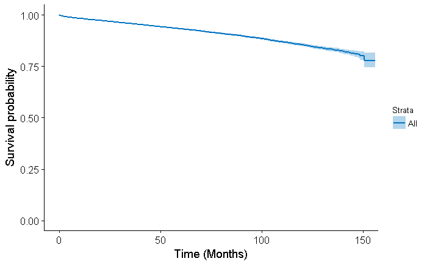

```r
uni_var(test_var = "TNM_PATH_M", data_imp = data)
```

## Pathologic Stage Group

```
_________________________________________________

## TNM_PATH_STAGE_GROUP
_________________________________________________
Call: survfit(formula = Surv(DX_LASTCONTACT_DEATH_MONTHS, PUF_VITAL_STATUS ==
    0) ~ TNM_PATH_STAGE_GROUP, data = data)

   291 observations deleted due to missingness
                             n events median 0.95LCL 0.95UCL
TNM_PATH_STAGE_GROUP=N_A 27853   2181     NA      NA      NA
TNM_PATH_STAGE_GROUP=99     46      4     NA      NA      NA

Call: survfit(formula = Surv(DX_LASTCONTACT_DEATH_MONTHS, PUF_VITAL_STATUS ==
    0) ~ TNM_PATH_STAGE_GROUP, data = data)

291 observations deleted due to missingness
                TNM_PATH_STAGE_GROUP=N_A
 time n.risk n.event survival  std.err lower 95% CI upper 95% CI
   12  25668     492    0.982 0.000814        0.980        0.983
   24  22993     301    0.970 0.001058        0.968        0.972
   36  19736     257    0.958 0.001269        0.956        0.961
   48  16622     237    0.946 0.001487        0.943        0.949
   60  13651     198    0.934 0.001705        0.930        0.937
  120   2681     624    0.856 0.003636        0.849        0.863

                TNM_PATH_STAGE_GROUP=99
 time n.risk n.event survival std.err lower 95% CI upper 95% CI
   12     44       0    1.000  0.0000        1.000            1
   24     38       1    0.977  0.0230        0.933            1
   36     23       2    0.908  0.0517        0.812            1
   48     14       1    0.868  0.0627        0.754            1
   60      5       0    0.868  0.0627        0.754            1





## Univariable Cox Proportional Hazard Model for:  TNM_PATH_STAGE_GROUP

Call:
coxph(formula = Surv(DX_LASTCONTACT_DEATH_MONTHS, PUF_VITAL_STATUS ==
    0) ~ TNM_PATH_STAGE_GROUP, data = data)

  n= 27899, number of events= 2185
   (291 observations deleted due to missingness)

                         coef exp(coef) se(coef)     z Pr(>|z|)
TNM_PATH_STAGE_GROUP99 0.6227    1.8640   0.5007 1.244    0.214

                       exp(coef) exp(-coef) lower .95 upper .95
TNM_PATH_STAGE_GROUP99     1.864     0.5365    0.6986     4.973

Concordance= 0.5  (se = 0 )
Rsquare= 0   (max possible= 0.778 )
Likelihood ratio test= 1.27  on 1 df,   p=0.3
Wald test            = 1.55  on 1 df,   p=0.2
Score (logrank) test = 1.6  on 1 df,   p=0.2
```

```
Removed 1 rows containing missing values (geom_errorbar).
```

```
## Unadjusted Kaplan Meier Overall Survival Curve for:  TNM_PATH_STAGE_GROUP
```

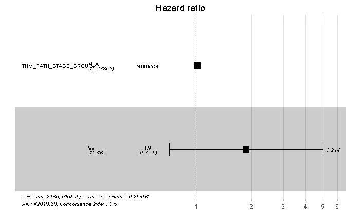

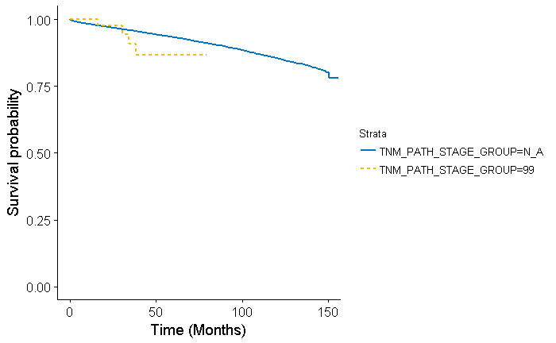

```r
uni_var(test_var = "TNM_PATH_STAGE_GROUP", data_imp = data)
```

## Margins

```
_________________________________________________

## MARGINS
_________________________________________________
Call: survfit(formula = Surv(DX_LASTCONTACT_DEATH_MONTHS, PUF_VITAL_STATUS ==
    0) ~ MARGINS, data = data)

                    n events median 0.95LCL 0.95UCL
MARGINS=No surg 16357   1650     NA      NA      NA
MARGINS=Unknown 11833    549     NA      NA      NA

Call: survfit(formula = Surv(DX_LASTCONTACT_DEATH_MONTHS, PUF_VITAL_STATUS ==
    0) ~ MARGINS, data = data)

                MARGINS=No surg
 time n.risk n.event survival std.err lower 95% CI upper 95% CI
   12  15026     344    0.978 0.00116        0.976        0.981
   24  13374     252    0.961 0.00156        0.958        0.964
   36  11280     213    0.945 0.00190        0.941        0.948
   48   9313     179    0.928 0.00222        0.924        0.933
   60   7474     158    0.911 0.00257        0.906        0.916
  120   1304     450    0.807 0.00567        0.796        0.818

                MARGINS=Unknown
 time n.risk n.event survival std.err lower 95% CI upper 95% CI
   12  10952     155    0.987 0.00107        0.984        0.989
   24   9865      56    0.981 0.00128        0.979        0.984
   36   8635      46    0.976 0.00146        0.974        0.979
   48   7413      59    0.969 0.00172        0.966        0.973
   60   6219      41    0.963 0.00194        0.960        0.967
  120   1377     174    0.917 0.00419        0.909        0.925





## Univariable Cox Proportional Hazard Model for:  MARGINS

Call:
coxph(formula = Surv(DX_LASTCONTACT_DEATH_MONTHS, PUF_VITAL_STATUS ==
    0) ~ MARGINS, data = data)

  n= 28190, number of events= 2199

                   coef exp(coef) se(coef)      z Pr(>|z|)
MARGINSUnknown -0.88284   0.41361  0.04934 -17.89   <2e-16 ***
---
Signif. codes:  0 *** 0.001 ** 0.01 * 0.05 . 0.1   1

               exp(coef) exp(-coef) lower .95 upper .95
MARGINSUnknown    0.4136      2.418    0.3755    0.4556

Concordance= 0.592  (se = 0.006 )
Rsquare= 0.013   (max possible= 0.777 )
Likelihood ratio test= 362.1  on 1 df,   p=<2e-16
Wald test            = 320.2  on 1 df,   p=<2e-16
Score (logrank) test = 341.3  on 1 df,   p=<2e-16
```

```
Removed 1 rows containing missing values (geom_errorbar).
```

```
## Unadjusted Kaplan Meier Overall Survival Curve for:  MARGINS
```

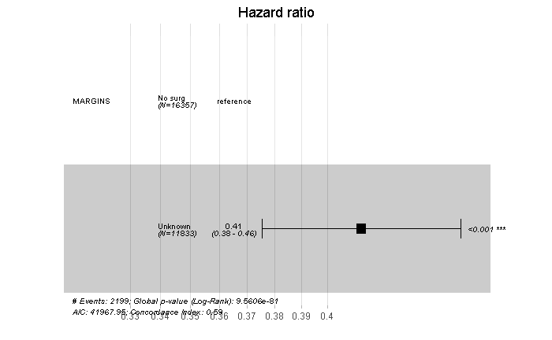

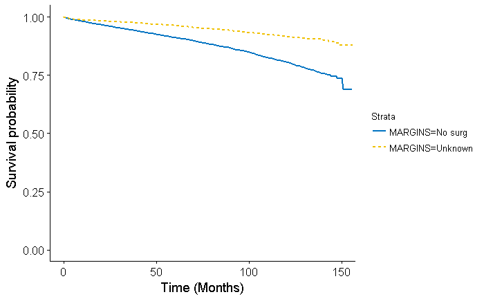

```r
uni_var(test_var = "MARGINS", data_imp = data)
```

## Margins Yes/No

```r
#uni_var(test_var = "MARGINS_YN", data_imp = data)
```

## 30 Day Readmission

```
_________________________________________________

## READM_HOSP_30_DAYS_F
_________________________________________________
Call: survfit(formula = Surv(DX_LASTCONTACT_DEATH_MONTHS, PUF_VITAL_STATUS ==
    0) ~ READM_HOSP_30_DAYS_F, data = data)

                                               n events median 0.95LCL 0.95UCL
READM_HOSP_30_DAYS_F=No_Surg_or_No_Readmit 26932   2115     NA      NA      NA
READM_HOSP_30_DAYS_F=Unplan_Readmit_Same     649     42     NA      NA      NA
READM_HOSP_30_DAYS_F=Plan_Readmit_Same       128      5     NA      NA      NA
READM_HOSP_30_DAYS_F=PlanUnplan_Same           5      0     NA      NA      NA
READM_HOSP_30_DAYS_F=9                       476     37     NA      NA      NA

Call: survfit(formula = Surv(DX_LASTCONTACT_DEATH_MONTHS, PUF_VITAL_STATUS ==
    0) ~ READM_HOSP_30_DAYS_F, data = data)

                READM_HOSP_30_DAYS_F=No_Surg_or_No_Readmit
 time n.risk n.event survival  std.err lower 95% CI upper 95% CI
   12  24824     477    0.982 0.000829        0.980        0.983
   24  22167     297    0.969 0.001081        0.967        0.972
   36  18940     247    0.958 0.001295        0.955        0.960
   48  15871     227    0.946 0.001519        0.943        0.948
   60  12938     195    0.933 0.001750        0.929        0.936
  120   2515     604    0.853 0.003770        0.846        0.861

                READM_HOSP_30_DAYS_F=Unplan_Readmit_Same
 time n.risk n.event survival std.err lower 95% CI upper 95% CI
   12    604      14    0.978 0.00581        0.967        0.989
   24    556       4    0.971 0.00666        0.958        0.984
   36    488       6    0.960 0.00801        0.945        0.976
   48    418       5    0.949 0.00930        0.931        0.968
   60    352       1    0.947 0.00957        0.928        0.966
  120     88       9    0.898 0.01900        0.861        0.936

                READM_HOSP_30_DAYS_F=Plan_Readmit_Same
 time n.risk n.event survival std.err lower 95% CI upper 95% CI
   12    117       3    0.976  0.0137        0.950        1.000
   24    106       1    0.967  0.0160        0.936        0.999
   36     98       1    0.958  0.0185        0.922        0.995
```

[output cut: 12 more lines]

```

                READM_HOSP_30_DAYS_F=9
 time n.risk n.event survival std.err lower 95% CI upper 95% CI
   12    428       5    0.989 0.00499        0.979        0.999
   24    405       6    0.974 0.00762        0.960        0.989
   36    384       5    0.962 0.00931        0.944        0.980
   48    347       6    0.947 0.01112        0.925        0.969
   60    322       3    0.938 0.01202        0.915        0.962
  120     56      11    0.875 0.02339        0.830        0.922





## Univariable Cox Proportional Hazard Model for:  READM_HOSP_30_DAYS_F
```

```
Loglik converged before variable  3 ; beta may be infinite.
```

```
Call:
coxph(formula = Surv(DX_LASTCONTACT_DEATH_MONTHS, PUF_VITAL_STATUS ==
    0) ~ READM_HOSP_30_DAYS_F, data = data)

  n= 28190, number of events= 2199

                                              coef  exp(coef)   se(coef)      z Pr(>|z|)
READM_HOSP_30_DAYS_FUnplan_Readmit_Same -2.948e-01  7.447e-01  1.559e-01 -1.892   0.0585 .
READM_HOSP_30_DAYS_FPlan_Readmit_Same   -8.957e-01  4.083e-01  4.478e-01 -2.000   0.0455 *
READM_HOSP_30_DAYS_FPlanUnplan_Same     -1.102e+01  1.644e-05  3.509e+02 -0.031   0.9750
READM_HOSP_30_DAYS_F9                   -1.845e-01  8.315e-01  1.659e-01 -1.112   0.2660
---
Signif. codes:  0 *** 0.001 ** 0.01 * 0.05 . 0.1   1

                                        exp(coef) exp(-coef)  lower .95  upper .95
READM_HOSP_30_DAYS_FUnplan_Readmit_Same 7.447e-01      1.343  5.487e-01  1.011e+00
READM_HOSP_30_DAYS_FPlan_Readmit_Same   4.083e-01      2.449  1.698e-01  9.821e-01
READM_HOSP_30_DAYS_FPlanUnplan_Same     1.644e-05  60826.894 3.406e-304 7.935e+293
READM_HOSP_30_DAYS_F9                   8.315e-01      1.203  6.007e-01  1.151e+00

Concordance= 0.505  (se = 0.002 )
Rsquare= 0   (max possible= 0.777 )
Likelihood ratio test= 11.5  on 4 df,   p=0.02
Wald test            = 8.66  on 4 df,   p=0.07
Score (logrank) test = 9.45  on 4 df,   p=0.05
```

[output not shown]

```
## Unadjusted Kaplan Meier Overall Survival Curve for:  READM_HOSP_30_DAYS_F
```

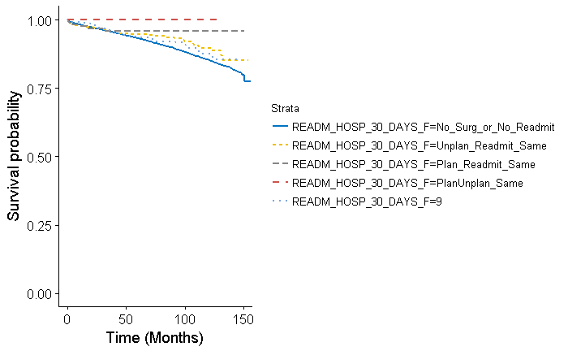

```r
uni_var(test_var = "READM_HOSP_30_DAYS_F", data_imp = data)
```

## Radiation Type

```
_________________________________________________

## RX_SUMM_RADIATION_F
_________________________________________________
Call: survfit(formula = Surv(DX_LASTCONTACT_DEATH_MONTHS, PUF_VITAL_STATUS ==
    0) ~ RX_SUMM_RADIATION_F, data = data)

                                             n events median 0.95LCL 0.95UCL
RX_SUMM_RADIATION_F=None                 18958   1431     NA      NA      NA
RX_SUMM_RADIATION_F=Beam Radiation        9013    759     NA      NA      NA
RX_SUMM_RADIATION_F=Radioactive Implants     8      0     NA      NA      NA
RX_SUMM_RADIATION_F=Radioisotopes            5      2   80.8    17.7      NA
RX_SUMM_RADIATION_F=Radiation, NOS          18      4     NA    99.2      NA
RX_SUMM_RADIATION_F=Unknown                188      3     NA      NA      NA

Call: survfit(formula = Surv(DX_LASTCONTACT_DEATH_MONTHS, PUF_VITAL_STATUS ==
    0) ~ RX_SUMM_RADIATION_F, data = data)

                RX_SUMM_RADIATION_F=None
 time n.risk n.event survival std.err lower 95% CI upper 95% CI
   12  17396     388    0.979 0.00106        0.977        0.981
   24  15492     205    0.967 0.00134        0.964        0.969
   36  13181     169    0.956 0.00158        0.952        0.959
   48  11013     140    0.945 0.00182        0.941        0.948
   60   9009     116    0.934 0.00206        0.930        0.938
  120   1756     377    0.862 0.00439        0.853        0.870

                RX_SUMM_RADIATION_F=Beam Radiation
 time n.risk n.event survival std.err lower 95% CI upper 95% CI
   12   8394     109    0.987 0.00119        0.985        0.990
   24   7572     102    0.975 0.00170        0.972        0.978
   36   6570      90    0.963 0.00212        0.959        0.967
   48   5567      97    0.947 0.00259        0.942        0.952
   60   4558      83    0.932 0.00305        0.926        0.938
  120    893     243    0.843 0.00652        0.830        0.856

                RX_SUMM_RADIATION_F=Radioactive Implants
 time n.risk n.event survival std.err lower 95% CI upper 95% CI
   12      8       0        1       0            1            1
   24      7       0        1       0            1            1
```

[output cut: 21 more lines]

```

                RX_SUMM_RADIATION_F=Unknown
 time n.risk n.event survival std.err lower 95% CI upper 95% CI
   12    161       1    0.994 0.00587        0.983            1
   24    153       0    0.994 0.00587        0.983            1
   36    144       0    0.994 0.00587        0.983            1
   48    127       0    0.994 0.00587        0.983            1
   60    108       0    0.994 0.00587        0.983            1
  120     28       1    0.981 0.01454        0.953            1





## Univariable Cox Proportional Hazard Model for:  RX_SUMM_RADIATION_F
```

```
Loglik converged before variable  2 ; beta may be infinite.
```

```
Call:
coxph(formula = Surv(DX_LASTCONTACT_DEATH_MONTHS, PUF_VITAL_STATUS ==
    0) ~ RX_SUMM_RADIATION_F, data = data)

  n= 28190, number of events= 2199

                                              coef  exp(coef)   se(coef)      z Pr(>|z|)
RX_SUMM_RADIATION_FBeam Radiation        6.401e-02  1.066e+00  4.491e-02  1.425   0.1541
RX_SUMM_RADIATION_FRadioactive Implants -1.149e+01  1.027e-05  3.687e+02 -0.031   0.9751
RX_SUMM_RADIATION_FRadioisotopes         1.700e+00  5.475e+00  7.076e-01  2.403   0.0163 *
RX_SUMM_RADIATION_FRadiation, NOS        9.714e-01  2.642e+00  5.008e-01  1.940   0.0524 .
RX_SUMM_RADIATION_FUnknown              -1.683e+00  1.858e-01  5.780e-01 -2.912   0.0036 **
---
Signif. codes:  0 *** 0.001 ** 0.01 * 0.05 . 0.1   1

                                        exp(coef) exp(-coef)  lower .95 upper .95
RX_SUMM_RADIATION_FBeam Radiation       1.066e+00  9.380e-01  9.763e-01    1.1642
RX_SUMM_RADIATION_FRadioactive Implants 1.027e-05  9.738e+04 1.601e-319       Inf
RX_SUMM_RADIATION_FRadioisotopes        5.475e+00  1.827e-01  1.368e+00   21.9120
RX_SUMM_RADIATION_FRadiation, NOS       2.642e+00  3.786e-01  9.900e-01    7.0486
RX_SUMM_RADIATION_FUnknown              1.858e-01  5.381e+00  5.987e-02    0.5769

Concordance= 0.498  (se = 0.006 )
Rsquare= 0.001   (max possible= 0.777 )
Likelihood ratio test= 26.35  on 5 df,   p=8e-05
Wald test            = 19.99  on 5 df,   p=0.001
Score (logrank) test = 24.85  on 5 df,   p=1e-04
```

[output not shown]

```
## Unadjusted Kaplan Meier Overall Survival Curve for:  RX_SUMM_RADIATION_F
```

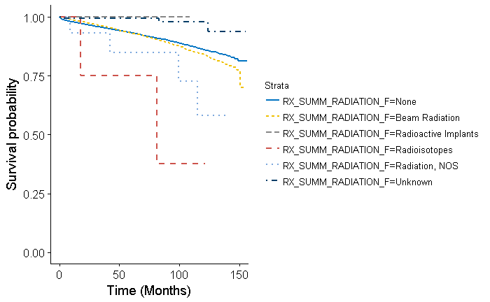

```r
uni_var(test_var = "RX_SUMM_RADIATION_F", data_imp = data)
```

## Lymphovascular Invasion

```
_________________________________________________

## LYMPH_VASCULAR_INVASION_F
_________________________________________________
Call: survfit(formula = Surv(DX_LASTCONTACT_DEATH_MONTHS, PUF_VITAL_STATUS ==
    0) ~ LYMPH_VASCULAR_INVASION_F, data = data)

   14423 observations deleted due to missingness
                                               n events median 0.95LCL 0.95UCL
LYMPH_VASCULAR_INVASION_F=Neg_LymphVasc_Inv 2556    106     NA      NA      NA
LYMPH_VASCULAR_INVASION_F=Pos_LumphVasc_Inv    2      1   10.6    10.6      NA
LYMPH_VASCULAR_INVASION_F=N_A               2409    178     NA      NA      NA
LYMPH_VASCULAR_INVASION_F=Unknown           8800    386     NA      NA      NA

Call: survfit(formula = Surv(DX_LASTCONTACT_DEATH_MONTHS, PUF_VITAL_STATUS ==
    0) ~ LYMPH_VASCULAR_INVASION_F, data = data)

14423 observations deleted due to missingness
                LYMPH_VASCULAR_INVASION_F=Neg_LymphVasc_Inv
 time n.risk n.event survival std.err lower 95% CI upper 95% CI
   12   2362      35    0.986 0.00238        0.981        0.991
   24   1943      23    0.976 0.00318        0.969        0.982
   36   1402      16    0.966 0.00393        0.958        0.974
   48    873      14    0.954 0.00499        0.945        0.964
   60    435       9    0.940 0.00688        0.927        0.954

                LYMPH_VASCULAR_INVASION_F=Pos_LumphVasc_Inv
        time       n.risk      n.event     survival      std.err lower 95% CI upper 95% CI
      12.000        1.000        1.000        0.500        0.354        0.125        1.000

                LYMPH_VASCULAR_INVASION_F=N_A
 time n.risk n.event survival std.err lower 95% CI upper 95% CI
   12   2068      73    0.968 0.00371        0.961        0.975
   24   1649      41    0.947 0.00485        0.938        0.957
   36   1211      27    0.929 0.00584        0.918        0.941
   48    794      19    0.912 0.00692        0.899        0.926
   60    416      11    0.896 0.00842        0.880        0.913

                LYMPH_VASCULAR_INVASION_F=Unknown
 time n.risk n.event survival std.err lower 95% CI upper 95% CI
```

[output cut: 21 more lines]

```
LYMPH_VASCULAR_INVASION_FN_A                0.62879   1.87533  0.12270 5.124 2.99e-07 ***
LYMPH_VASCULAR_INVASION_FUnknown            0.04879   1.05000  0.10966 0.445 0.656384
---
Signif. codes:  0 *** 0.001 ** 0.01 * 0.05 . 0.1   1

                                           exp(coef) exp(-coef) lower .95 upper .95
LYMPH_VASCULAR_INVASION_FPos_LumphVasc_Inv    27.825    0.03594    3.8772   199.691
LYMPH_VASCULAR_INVASION_FN_A                   1.875    0.53324    1.4745     2.385
LYMPH_VASCULAR_INVASION_FUnknown               1.050    0.95238    0.8469     1.302

Concordance= 0.563  (se = 0.01 )
Rsquare= 0.003   (max possible= 0.584 )
Likelihood ratio test= 45.86  on 3 df,   p=6e-10
Wald test            = 55.52  on 3 df,   p=5e-12
Score (logrank) test = 68.58  on 3 df,   p=9e-15
```

```
Removed 1 rows containing missing values (geom_errorbar).
```

```
## Unadjusted Kaplan Meier Overall Survival Curve for:  LYMPH_VASCULAR_INVASION_F
```

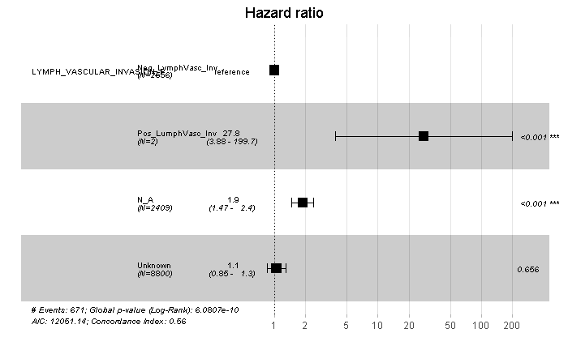

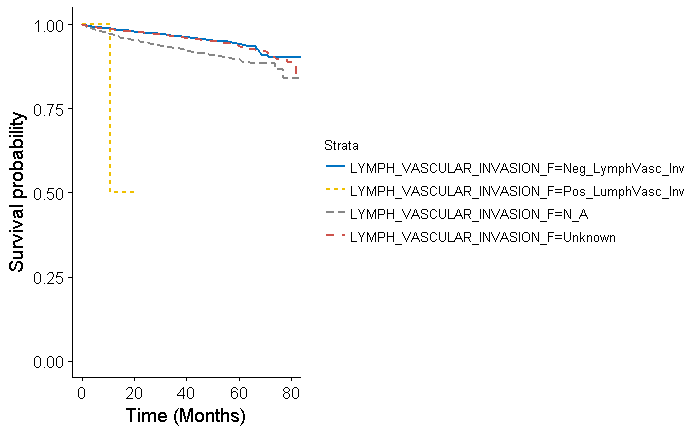

```r
uni_var(test_var = "LYMPH_VASCULAR_INVASION_F", data_imp = data)
```

## Endoscopic/Robotic

```
_________________________________________________

## RX_HOSP_SURG_APPR_2010_F
_________________________________________________
Call: survfit(formula = Surv(DX_LASTCONTACT_DEATH_MONTHS, PUF_VITAL_STATUS ==
    0) ~ RX_HOSP_SURG_APPR_2010_F, data = data)

   14423 observations deleted due to missingness
                                             n events median 0.95LCL 0.95UCL
RX_HOSP_SURG_APPR_2010_F=No_Surg          8697    545     NA      NA      NA
RX_HOSP_SURG_APPR_2010_F=Robot_Assist       22      1     NA      NA      NA
RX_HOSP_SURG_APPR_2010_F=Robot_to_Open       1      0     NA      NA      NA
RX_HOSP_SURG_APPR_2010_F=Endo_Lap          218      6     NA      NA      NA
RX_HOSP_SURG_APPR_2010_F=Endo_Lap_to_Open   11      0     NA      NA      NA
RX_HOSP_SURG_APPR_2010_F=Open_Unknown     4800    118     NA      NA      NA
RX_HOSP_SURG_APPR_2010_F=Unknown            18      1     38      38      NA

Call: survfit(formula = Surv(DX_LASTCONTACT_DEATH_MONTHS, PUF_VITAL_STATUS ==
    0) ~ RX_HOSP_SURG_APPR_2010_F, data = data)

14423 observations deleted due to missingness
                RX_HOSP_SURG_APPR_2010_F=No_Surg
 time n.risk n.event survival std.err lower 95% CI upper 95% CI
   12   7864     178    0.979 0.00158        0.976        0.982
   24   6487     120    0.963 0.00212        0.959        0.967
   36   4656      91    0.947 0.00264        0.942        0.952
   48   2967      72    0.930 0.00332        0.923        0.936
   60   1525      47    0.909 0.00443        0.901        0.918

                RX_HOSP_SURG_APPR_2010_F=Robot_Assist
 time n.risk n.event survival std.err lower 95% CI upper 95% CI
   12     21       0     1.00  0.0000        1.000            1
   24     18       1     0.95  0.0487        0.859            1
   36     12       0     0.95  0.0487        0.859            1
   48      4       0     0.95  0.0487        0.859            1
   60      3       0     0.95  0.0487        0.859            1

                RX_HOSP_SURG_APPR_2010_F=Robot_to_Open
 time n.risk n.event survival std.err lower 95% CI upper 95% CI
   12      1       0        1       0            1            1
```

[output cut: 27 more lines]

```
   60    904      10    0.968 0.00347        0.961        0.975

                RX_HOSP_SURG_APPR_2010_F=Unknown
 time n.risk n.event survival std.err lower 95% CI upper 95% CI
   12      8       0      1.0   0.000        1.000            1
   24      4       0      1.0   0.000        1.000            1
   36      3       0      1.0   0.000        1.000            1
   48      1       1      0.5   0.354        0.125            1
   60      1       0      0.5   0.354        0.125            1





## Univariable Cox Proportional Hazard Model for:  RX_HOSP_SURG_APPR_2010_F
```

```
Loglik converged before variable  2,4 ; beta may be infinite.
```

```
Call:
coxph(formula = Surv(DX_LASTCONTACT_DEATH_MONTHS, PUF_VITAL_STATUS ==
    0) ~ RX_HOSP_SURG_APPR_2010_F, data = data)

  n= 13767, number of events= 671
   (14423 observations deleted due to missingness)

                                               coef  exp(coef)   se(coef)      z Pr(>|z|)
RX_HOSP_SURG_APPR_2010_FRobot_Assist     -2.758e-01  7.590e-01  1.001e+00 -0.276   0.7829
RX_HOSP_SURG_APPR_2010_FRobot_to_Open    -1.333e+01  1.627e-06  2.197e+03 -0.006   0.9952
RX_HOSP_SURG_APPR_2010_FEndo_Lap         -8.194e-01  4.407e-01  4.105e-01 -1.996   0.0459 *
RX_HOSP_SURG_APPR_2010_FEndo_Lap_to_Open -1.333e+01  1.630e-06  8.713e+02 -0.015   0.9878
RX_HOSP_SURG_APPR_2010_FOpen_Unknown     -9.495e-01  3.869e-01  1.015e-01 -9.351   <2e-16 ***
RX_HOSP_SURG_APPR_2010_FUnknown           8.751e-01  2.399e+00  1.001e+00  0.874   0.3820
---
Signif. codes:  0 *** 0.001 ** 0.01 * 0.05 . 0.1   1

                                         exp(coef) exp(-coef) lower .95 upper .95
RX_HOSP_SURG_APPR_2010_FRobot_Assist     7.590e-01  1.318e+00    0.1067    5.3981
RX_HOSP_SURG_APPR_2010_FRobot_to_Open    1.627e-06  6.145e+05    0.0000       Inf
RX_HOSP_SURG_APPR_2010_FEndo_Lap         4.407e-01  2.269e+00    0.1971    0.9853
RX_HOSP_SURG_APPR_2010_FEndo_Lap_to_Open 1.630e-06  6.134e+05    0.0000       Inf
RX_HOSP_SURG_APPR_2010_FOpen_Unknown     3.869e-01  2.584e+00    0.3171    0.4721
RX_HOSP_SURG_APPR_2010_FUnknown          2.399e+00  4.168e-01    0.3372   17.0673

Concordance= 0.588  (se = 0.01 )
Rsquare= 0.008   (max possible= 0.584 )
Likelihood ratio test= 110  on 6 df,   p=<2e-16
Wald test            = 91.07  on 6 df,   p=<2e-16
Score (logrank) test = 99  on 6 df,   p=<2e-16
```

[output not shown]

```
## Unadjusted Kaplan Meier Overall Survival Curve for:  RX_HOSP_SURG_APPR_2010_F
```

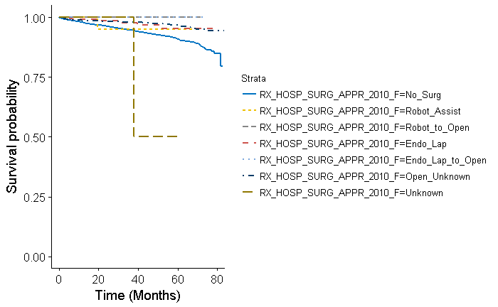

```r
uni_var(test_var = "RX_HOSP_SURG_APPR_2010_F", data_imp = data)
```

## Surgery Radiation Sequence

```
_________________________________________________

## SURG_RAD_SEQ
_________________________________________________
Call: survfit(formula = Surv(DX_LASTCONTACT_DEATH_MONTHS, PUF_VITAL_STATUS ==
    0) ~ SURG_RAD_SEQ, data = data)

                               n events median 0.95LCL 0.95UCL
SURG_RAD_SEQ=Surg Alone    11121    520     NA      NA      NA
SURG_RAD_SEQ=Surg then Rad   481     18     NA      NA      NA
SURG_RAD_SEQ=Rad Alone      8512    744     NA      NA      NA
SURG_RAD_SEQ=No Treatement  7686    880     NA      NA      NA
SURG_RAD_SEQ=Other           383     37     NA      NA      NA
SURG_RAD_SEQ=Rad then Surg     7      0     NA      NA      NA

Call: survfit(formula = Surv(DX_LASTCONTACT_DEATH_MONTHS, PUF_VITAL_STATUS ==
    0) ~ SURG_RAD_SEQ, data = data)

                SURG_RAD_SEQ=Surg Alone
 time n.risk n.event survival std.err lower 95% CI upper 95% CI
   12  10286     148    0.986 0.00111        0.984        0.989
   24   9263      53    0.981 0.00133        0.978        0.984
   36   8100      44    0.976 0.00152        0.973        0.979
   48   6953      57    0.969 0.00180        0.965        0.972
   60   5840      37    0.963 0.00201        0.959        0.967
  120   1302     165    0.916 0.00437        0.907        0.924

                SURG_RAD_SEQ=Surg then Rad
 time n.risk n.event survival std.err lower 95% CI upper 95% CI
   12    461       3    0.994 0.00366        0.986        1.000
   24    412       3    0.987 0.00531        0.977        0.997
   36    357       0    0.987 0.00531        0.977        0.997
   48    294       1    0.984 0.00608        0.972        0.996
   60    235       3    0.973 0.00865        0.956        0.990
  120     45       6    0.938 0.01662        0.906        0.971

                SURG_RAD_SEQ=Rad Alone
 time n.risk n.event survival std.err lower 95% CI upper 95% CI
   12   7912     107    0.987 0.00125        0.984        0.989
   24   7139     100    0.974 0.00178        0.971        0.978
```

[output cut: 21 more lines]

```
  120     36      10    0.844 0.02784        0.791        0.900

                SURG_RAD_SEQ=Rad then Surg
 time n.risk n.event survival std.err lower 95% CI upper 95% CI
   12      6       0        1       0            1            1
   24      6       0        1       0            1            1
   36      4       0        1       0            1            1
   48      4       0        1       0            1            1
   60      4       0        1       0            1            1





## Univariable Cox Proportional Hazard Model for:  SURG_RAD_SEQ
```

```
Loglik converged before variable  5 ; beta may be infinite.
```

```
Call:
coxph(formula = Surv(DX_LASTCONTACT_DEATH_MONTHS, PUF_VITAL_STATUS ==
    0) ~ SURG_RAD_SEQ, data = data)

  n= 28190, number of events= 2199

                                coef  exp(coef)   se(coef)      z Pr(>|z|)
SURG_RAD_SEQSurg then Rad -1.786e-01  8.365e-01  2.398e-01 -0.745    0.456
SURG_RAD_SEQRad Alone      6.564e-01  1.928e+00  5.717e-02 11.482  < 2e-16 ***
SURG_RAD_SEQNo Treatement  1.089e+00  2.971e+00  5.550e-02 19.622  < 2e-16 ***
SURG_RAD_SEQOther          8.327e-01  2.299e+00  1.702e-01  4.894 9.89e-07 ***
SURG_RAD_SEQRad then Surg -1.052e+01  2.696e-05  3.825e+02 -0.028    0.978
---
Signif. codes:  0 *** 0.001 ** 0.01 * 0.05 . 0.1   1

                          exp(coef) exp(-coef) lower .95 upper .95
SURG_RAD_SEQSurg then Rad 8.365e-01  1.195e+00    0.5228     1.338
SURG_RAD_SEQRad Alone     1.928e+00  5.187e-01    1.7236     2.157
SURG_RAD_SEQNo Treatement 2.971e+00  3.366e-01    2.6649     3.312
SURG_RAD_SEQOther         2.299e+00  4.349e-01    1.6474     3.210
SURG_RAD_SEQRad then Surg 2.696e-05  3.710e+04    0.0000       Inf

Concordance= 0.62  (se = 0.006 )
Rsquare= 0.015   (max possible= 0.777 )
Likelihood ratio test= 426.2  on 5 df,   p=<2e-16
Wald test            = 399.3  on 5 df,   p=<2e-16
Score (logrank) test = 430.4  on 5 df,   p=<2e-16
```

[output not shown]

```
## Unadjusted Kaplan Meier Overall Survival Curve for:  SURG_RAD_SEQ
```

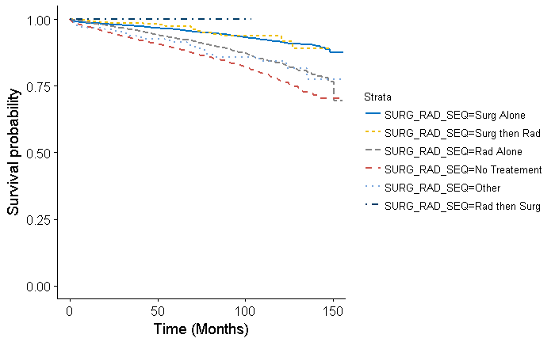

```r
uni_var(test_var = "SURG_RAD_SEQ", data_imp = data)
```

## Surgery Yes/No

```
_________________________________________________

## SURGERY_YN
_________________________________________________
Call: survfit(formula = Surv(DX_LASTCONTACT_DEATH_MONTHS, PUF_VITAL_STATUS ==
    0) ~ SURGERY_YN, data = data)

                   n events median 0.95LCL 0.95UCL
SURGERY_YN=No  16119   1617     NA      NA      NA
SURGERY_YN=Ukn   323     37     NA      NA      NA
SURGERY_YN=Yes 11748    545     NA      NA      NA

Call: survfit(formula = Surv(DX_LASTCONTACT_DEATH_MONTHS, PUF_VITAL_STATUS ==
    0) ~ SURGERY_YN, data = data)

                SURGERY_YN=No
 time n.risk n.event survival std.err lower 95% CI upper 95% CI
   12  14836     339    0.978 0.00117        0.976        0.981
   24  13202     247    0.961 0.00157        0.958        0.964
   36  11121     209    0.945 0.00191        0.941        0.949
   48   9175     173    0.929 0.00223        0.925        0.933
   60   7350     155    0.912 0.00258        0.907        0.917
  120   1266     443    0.806 0.00575        0.795        0.818

                SURGERY_YN=Ukn
 time n.risk n.event survival std.err lower 95% CI upper 95% CI
   12    256       5    0.982 0.00812        0.966        0.998
   24    229       5    0.961 0.01216        0.937        0.985
   36    209       6    0.935 0.01586        0.904        0.966
   48    186       7    0.902 0.01952        0.865        0.941
   60    167       3    0.887 0.02106        0.847        0.929
  120     45       8    0.828 0.02922        0.772        0.887

                SURGERY_YN=Yes
 time n.risk n.event survival std.err lower 95% CI upper 95% CI
   12  10886     155    0.986 0.00108        0.984        0.989
   24   9808      56    0.981 0.00129        0.979        0.984
   36   8585      44    0.976 0.00146        0.974        0.979
   48   7365      58    0.969 0.00172        0.966        0.973
   60   6176      41    0.964 0.00194        0.960        0.967
```

[output cut: 14 more lines]

```
                  coef exp(coef) se(coef)       z Pr(>|z|)
SURGERY_YNUkn  0.08004   1.08333  0.16637   0.481     0.63
SURGERY_YNYes -0.87955   0.41497  0.04960 -17.731   <2e-16 ***
---
Signif. codes:  0 *** 0.001 ** 0.01 * 0.05 . 0.1   1

              exp(coef) exp(-coef) lower .95 upper .95
SURGERY_YNUkn     1.083     0.9231    0.7819    1.5010
SURGERY_YNYes     0.415     2.4098    0.3765    0.4573

Concordance= 0.592  (se = 0.006 )
Rsquare= 0.013   (max possible= 0.777 )
Likelihood ratio test= 359.8  on 2 df,   p=<2e-16
Wald test            = 317.8  on 2 df,   p=<2e-16
Score (logrank) test = 338.8  on 2 df,   p=<2e-16
```

[output not shown]

```
## Unadjusted Kaplan Meier Overall Survival Curve for:  SURGERY_YN
```

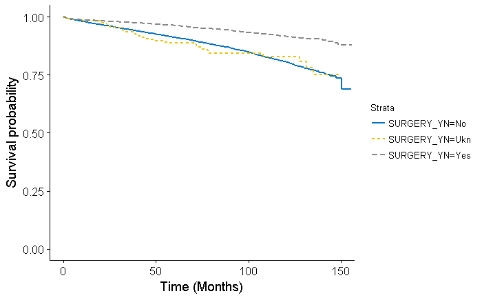

```r
uni_var(test_var = "SURGERY_YN", data_imp = data)
```

## Radiation Yes/No

```
_________________________________________________

## RADIATION_YN
_________________________________________________
Call: survfit(formula = Surv(DX_LASTCONTACT_DEATH_MONTHS, PUF_VITAL_STATUS ==
    0) ~ RADIATION_YN, data = data)

                     n events median 0.95LCL 0.95UCL
RADIATION_YN=No  18951   1424     NA      NA      NA
RADIATION_YN=Ukn   195     10     NA      NA      NA
RADIATION_YN=Yes  9044    765     NA      NA      NA

Call: survfit(formula = Surv(DX_LASTCONTACT_DEATH_MONTHS, PUF_VITAL_STATUS ==
    0) ~ RADIATION_YN, data = data)

                RADIATION_YN=No
 time n.risk n.event survival std.err lower 95% CI upper 95% CI
   12  17396     381    0.979 0.00105        0.977        0.981
   24  15492     205    0.967 0.00133        0.965        0.970
   36  13181     169    0.956 0.00158        0.953        0.959
   48  11013     140    0.945 0.00181        0.941        0.948
   60   9009     116    0.934 0.00206        0.930        0.938
  120   1756     377    0.862 0.00439        0.853        0.871

                RADIATION_YN=Ukn
 time n.risk n.event survival std.err lower 95% CI upper 95% CI
   12    161       8    0.955  0.0157        0.924        0.986
   24    153       0    0.955  0.0157        0.924        0.986
   36    144       0    0.955  0.0157        0.924        0.986
   48    127       0    0.955  0.0157        0.924        0.986
   60    108       0    0.955  0.0157        0.924        0.986
  120     28       1    0.942  0.0201        0.903        0.982

                RADIATION_YN=Yes
 time n.risk n.event survival std.err lower 95% CI upper 95% CI
   12   8421     110    0.987 0.00119        0.985        0.990
   24   7594     103    0.975 0.00170        0.972        0.978
   36   6590      90    0.963 0.00212        0.958        0.967
   48   5586      98    0.947 0.00260        0.942        0.952
   60   4576      83    0.932 0.00305        0.926        0.938
```

[output cut: 12 more lines]

```
  n= 28190, number of events= 2199

                    coef exp(coef) se(coef)      z Pr(>|z|)
RADIATION_YNUkn -0.47646   0.62098  0.31736 -1.501    0.133
RADIATION_YNYes  0.07312   1.07586  0.04483  1.631    0.103

                exp(coef) exp(-coef) lower .95 upper .95
RADIATION_YNUkn     0.621     1.6104    0.3334     1.157
RADIATION_YNYes     1.076     0.9295    0.9854     1.175

Concordance= 0.496  (se = 0.006 )
Rsquare= 0   (max possible= 0.777 )
Likelihood ratio test= 5.61  on 2 df,   p=0.06
Wald test            = 5.17  on 2 df,   p=0.08
Score (logrank) test = 5.23  on 2 df,   p=0.07
```

[output not shown]

```
## Unadjusted Kaplan Meier Overall Survival Curve for:  RADIATION_YN
```

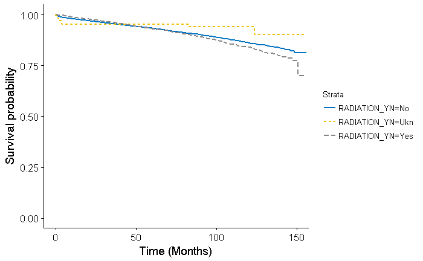

```r
uni_var(test_var = "RADIATION_YN", data_imp = data)
```